# From a Single Cell to a Cell-Type Prediction: Analysis of Murine Hematopoietic scRNA-seq Data

## De Santis Lorenzo - 3163450

Single-cell RNA sequencing (scRNA-seq) measures gene expression one cell at a time, so that every captured cell gets its own transcriptional profile instead of contributing to a single averaged measurement over a whole tissue. This resolution makes it possible to see whether a population of cells is transcriptionally uniform, cleanly divided into subtypes, or organised along smoother gradients. A bulk measurement cannot make that distinction.

Blood and immune cells arise from hematopoietic stem and progenitor cells in the bone marrow. During differentiation, descendants progressively modify their molecular programmes, reduce their developmental potential, and become increasingly biased toward particular lineages.

This process is not a sequence of perfectly synchronised jumps. Transcriptional programmes are acquired and lost gradually, so cells can occupy intermediate states between familiar biological categories. Cell-type names remain useful, but they impose practical boundaries on an underlying spectrum in which neighbouring populations may partly overlap. Observing structure of that kind is what single-cell resolution allows and a bulk average does not.

Machine-learning methods can explore whether these expression profiles contain coherent structure and, when annotations are available, learn to predict the identity of cells whose labels are hidden. The supplied data combine a cell-by-gene expression matrix with annotations for only a subset of cells; before fitting any model, the notebook first establishes what the numerical values represent, which labels are present, and which preprocessing choices the data can support.

## Project Objective and Structure

The notebook follows a single logical thread: each section builds on the objects and conclusions produced by the one before it, so the analysis accumulates evidence instead of presenting a checklist of unrelated techniques. Starting from what the supplied files contain, it works step by step toward answering two complementary questions:

1. **Biological structure:** with the labels set aside, do transcriptomically similar cells organise into patterns compatible with continuous hematopoietic differentiation?
2. **Cell-type classification:** how reliably can the ten supplied cell-type labels be predicted from annotated expression profiles under an honest cross-validation protocol?

Answering them requires working through the following sections:

1. From DNA to a single-cell expression matrix
2. Libraries and data loading
3. Dataset exploration
4. Biological background: hematopoiesis
5. Exploratory data analysis
6. Quality control and numerical-scale audit
7. Preprocessing justified by the observed data
8. Preprocessing decisions
9. Principal Component Analysis
10. Nearest-neighbour graph, UMAP, and t-SNE
11. Unsupervised clustering
12. Differential expression and biological interpretation of clusters
13. Comparing PCA, an autoencoder, and a denoising autoencoder
14. Supervised cell-type classification
15. Final model comparison and error interpretation
16. Additional approach: graph-based cell classification
17. Refit on all annotated cells and prediction of unannotated profiles
18. Integrated discussion and conclusions

The graph-based analysis is kept as a clearly identified extension because Graph Convolutional Networks were not part of the core course methods. References are collected before the final integrated discussion, leaving the conclusions as the notebook's closing section.

# 1. From DNA to a Single-Cell Expression Matrix

## 1.1 Genes, Transcription, and Messenger RNA

DNA stores genetic information. A **gene** is a genomic region whose sequence can be used to produce a functional RNA or protein. When a protein-coding gene is active, the cell transcribes it into **messenger RNA (mRNA)**; the mRNA can then be translated into protein.

The amount of mRNA associated with a gene is therefore an imperfect but useful indication of that gene's transcriptional activity. It is not identical to protein abundance: RNA stability, translation, and protein degradation introduce additional regulation. Nevertheless, the collection of RNA molecules in a cell, its **transcriptome**, provides a rich molecular description of cellular identity and state.

RNA sequencing converts RNA-derived molecules into sequence reads that can be assigned to genes. In **bulk RNA-seq**, RNA from many cells is pooled, producing an average profile. If a rare population or a transitional state is present, its signal may be hidden by this average. In **single-cell RNA-seq**, molecules are associated with individual cells, so heterogeneity can be examined directly.

## 1.2 From Transcripts to Single-Cell Expression Data

In scRNA-seq, the RNA molecules assigned to each cell are summarised as a matrix:

$$ X \in \mathbb{R}^{n_{cells}\times n_{genes}}. $$

- each **row** represents one measured cell;
- each **column** represents one gene;
- each entry $x_{ij}$ is the expression value supplied for gene $j$ in cell $i$.

The matrix is a molecular description, not a microscope image. Two cells are considered similar when they show similar expression programmes across many genes, even if no single gene provides a perfect identifier.

The numerical meaning of $x_{ij}$ depends on the processing already applied. In an untouched UMI matrix, entries are non-negative integers representing captured molecules. After library-size normalisation and logarithmic transformation, entries become continuous values. Determining which form was supplied is essential because counts, normalised values, and scaled values require different downstream operations.

## 1.3 Why Single-Cell Hematopoietic Data Are Challenging

Several properties shape the analysis:

- **High dimensionality:** thousands of genes are measured in substantially fewer cells.
- **Sparsity:** many cell-gene entries are zero.
- **Sampling noise and dropout:** a zero can occur because a low-abundance transcript was not captured; it does not prove that the gene is inactive.
- **Technical variability:** cells can differ in RNA capture and sequencing depth.
- **Multiple biological signals:** lineage, maturation, cell cycle, activation, and stress can affect expression simultaneously.
- **Continuous differentiation:** progenitors gradually change their expression programmes, so neighbouring populations may have blurred boundaries instead of forming isolated groups.

The last point directly connects the computational difficulty to hematopoiesis. Overlap between two annotated populations is not automatically a modelling failure: it may reflect real intermediate states. At the same time, technical noise and limited sample size can produce similar overlap. Dimensionality reduction, clustering, markers, and supervised validation are therefore used together, and no single plot or gene is treated as definitive evidence.

# 2. Libraries and Data Loading

The notebook uses NumPy and Pandas for data handling, AnnData and Scanpy for single-cell data, Matplotlib and Seaborn for figures, scikit-learn for dimensionality reduction and classical models, PyTorch for the neural networks, and XGBoost for boosted trees.

All imports are collected below. `SEED` is reused whenever an algorithm has a random component. The AnnData file is loaded once and copied before analysis so that the object read from disk is not modified.

```python
import copy
from itertools import combinations
from pathlib import Path
from time import perf_counter
import warnings

# Data manipulation and statistics
import numpy as np
import pandas as pd
from scipy import sparse
from scipy.spatial.distance import cdist
from scipy.stats import entropy as scipy_entropy
from scipy.stats import mannwhitneyu, spearmanr
from scipy.cluster.hierarchy import dendrogram, fcluster, linkage

# Hide deprecation messages raised internally by the installed AnnData version
warnings.filterwarnings("ignore", category=FutureWarning, module=r"anndata(\..*)?")

# Visualisation and single-cell analysis
import matplotlib.pyplot as plt
import seaborn as sns
import anndata as ad
import scanpy as sc
import umap

# Neural networks
import torch
from torch import nn
from torch.utils.data import DataLoader, TensorDataset

# Classical machine learning
from sklearn.base import clone
from sklearn.cluster import KMeans
from sklearn.decomposition import PCA
from sklearn.ensemble import RandomForestClassifier
from sklearn.linear_model import LogisticRegression
from sklearn.manifold import TSNE, trustworthiness
from sklearn.metrics import (
    accuracy_score,
    adjusted_rand_score,
    balanced_accuracy_score,
    confusion_matrix,
    f1_score,
    normalized_mutual_info_score,
    precision_recall_fscore_support,
    silhouette_score,
)
from sklearn.model_selection import GridSearchCV, StratifiedKFold, train_test_split
from sklearn.neighbors import NearestNeighbors
from sklearn.pipeline import Pipeline
from sklearn.preprocessing import StandardScaler
from sklearn.svm import SVC
from sklearn.utils.class_weight import compute_sample_weight
from xgboost import XGBClassifier

from IPython.display import display
```

```python
from importlib.metadata import version

for package in ["numpy", "pandas", "scipy", "anndata", "scanpy", "umap-learn", "scikit-learn", "torch", "xgboost"]:
    print(f"{package:<14} {version(package)}")
```

```
numpy          1.26.4
pandas         2.3.3
scipy          1.15.3
anndata        0.11.4
scanpy         1.10.2
umap-learn     0.5.11
scikit-learn   1.7.2
torch          2.5.1
xgboost        3.2.0
```

```python
SEED = 42
```

The analysis uses two files:

- `single_cell.h5ad`: expression matrix and cell/gene metadata;
- `singlecell_train.csv`: known labels for a subset of cells.

For portability, both files are expected in the same directory from which the notebook is launched. No user-specific or machine-specific path is required.

```python
PROJECT_DIR = Path.cwd()
H5AD_PATH = PROJECT_DIR / "single_cell.h5ad"
TRAIN_PATH = PROJECT_DIR / "singlecell_train.csv"

missing_files = [path.name for path in (H5AD_PATH, TRAIN_PATH) if not path.exists()]
if missing_files:
    raise FileNotFoundError(
        "Required data files were not found: " + ", ".join(missing_files) + ". "
        "Place them in the same directory as the notebook and launch Jupyter from that directory."
    )

adata_original = ad.read_h5ad(H5AD_PATH)
train = pd.read_csv(TRAIN_PATH)
adata_full = adata_original.copy()

print(adata_full)
print("Training labels:", train.shape)
```

```
AnnData object with n_obs × n_vars = 1499 × 4290
    obs: 'ID'
    var: 'ENSG', 'Symbol'
Training labels: (1074, 3)
```

## 2.1 Understanding AnnData

AnnData keeps the expression matrix and its metadata as separate objects instead of one flat table: `X` is the cell-by-gene expression matrix, `obs` holds one metadata row per cell, and `var` holds one metadata row per gene. For this file, those three objects are also the only place any information is stored: the check below confirms that no layers, raw counts, or precomputed embeddings are attached.

```python
print(f"X type: {type(adata_full.X).__name__}, dtype: {adata_full.X.dtype}")
print(f"obs columns: {list(adata_full.obs.columns)}")
print(f"var columns: {list(adata_full.var.columns)}")
print(f"layers: {list(adata_full.layers.keys())}")
print(f"raw: {adata_full.raw}")
print(f"obsm: {list(adata_full.obsm.keys())}")
print(f"uns: {list(adata_full.uns.keys())}")

print("\nCell metadata preview")
display(adata_full.obs.head())
print("\nGene metadata preview")
display(adata_full.var.head())
print("\nTraining annotation preview")
display(train.head())
```

```
X type: ndarray, dtype: float64
obs columns: ['ID']
var columns: ['ENSG', 'Symbol']
layers: []
raw: None
obsm: []
uns: []

Cell metadata preview
```

|  | ID |
| --- | --- |
| 0 | f8f4122d32 |
| 1 | c547632b57 |
| 2 | c2e46e7dfc |
| 3 | 0710f78e38 |
| 4 | 449e822f38 |

```
Gene metadata preview
```

|  | ENSG | Symbol |
| --- | --- | --- |
| 0 | ENSMUSG00000030159 | Clec1b |
| 1 | ENSMUSG00000053470 | Kdm3a |
| 2 | ENSMUSG00000041729 | Coro2b |
| 3 | ENSMUSG00000048489 | Depp1 |
| 4 | ENSMUSG00000046080 | Clec9a |

```
Training annotation preview
```

|  | ID | cell_type | clusters |
| --- | --- | --- | --- |
| 0 | f8f4122d32 | LMPP_broad | 2 |
| 1 | 0710f78e38 | LTHSC_broad | 3 |
| 2 | 449e822f38 | MEP_broad | 4 |
| 3 | c8b77d8ad4 | STHSC_broad | 8 |
| 4 | a44b6f05bc | GMP_broad | 1 |

# 3. Dataset Exploration

Before proceeding with the analysis, we look at the data directly: attach the known labels to the AnnData object, collect everything into one table, and check that the two sources agree.

```python
# quick sanity check before trusting the join: any duplicate or missing IDs?
print("duplicate IDs in the training file:", train["ID"].duplicated().sum())
print("duplicate IDs in the AnnData object:", adata_full.obs["ID"].duplicated().sum())
print(
    "training IDs not found in the AnnData object:",
    (~train["ID"].astype(str).isin(adata_full.obs["ID"].astype(str))).sum(),
)
```

```
duplicate IDs in the training file: 0
duplicate IDs in the AnnData object: 0
training IDs not found in the AnnData object: 0
```

```python
# attach the labels from the CSV to the AnnData object, matching cells by their ID
train_for_mapping = train.copy()
train_for_mapping["ID"] = train_for_mapping["ID"].astype(str)
id_lookup = train_for_mapping.set_index("ID")  # look up cell_type / clusters by ID

adata_ids = adata_full.obs["ID"].astype(str)
adata_full.obs["cell_type"] = adata_ids.map(id_lookup["cell_type"])
adata_full.obs["cluster"] = adata_ids.map(id_lookup["clusters"]).astype("Int64")

# a cell counts as "annotated" if we managed to attach a cell_type to it
adata_full.obs["annotation_status"] = np.where(
    adata_full.obs["cell_type"].notna(), "Annotated", "Unannotated"
)

# the 10 unique code <-> label pairs, used again later in the notebook
mapping_table = (
    train_for_mapping[["clusters", "cell_type"]]
    .drop_duplicates()
    .sort_values("clusters")
    .reset_index(drop=True)
)
display(mapping_table)
```

|  | clusters | cell_type |
| --- | --- | --- |
| 0 | 0 | CMP_broad |
| 1 | 1 | GMP_broad |
| 2 | 2 | LMPP_broad |
| 3 | 3 | LTHSC_broad |
| 4 | 4 | MEP_broad |
| 5 | 5 | MPP1_broad |
| 6 | 6 | MPP2_broad |
| 7 | 7 | MPP3_broad |
| 8 | 8 | STHSC_broad |
| 9 | 9 | other |

```python
# put metadata and gene expression together in one table, just to see everything at once
expression = adata_full.X.toarray() if hasattr(adata_full.X, "toarray") else adata_full.X
gene_names = adata_full.var["Symbol"].astype(str)  # var.index is just "0", "1", ..., not useful as a column name
expression_table = pd.DataFrame(expression, index=adata_full.obs.index, columns=gene_names)

full_table = pd.concat([adata_full.obs, expression_table], axis=1)

labeled_cells = full_table[full_table["cell_type"].notna()]
unlabeled_cells = full_table[full_table["cell_type"].isna()]

display(labeled_cells.head())
```

|  | ID | cell_type | cluster | annotation_status | Clec1b | Kdm3a | Coro2b | Depp1 | Clec9a | Phf6 | ... | Rab18 | Mzb1 | Cables1 | B4galt6 | Rnf125 | Impact | Taf4b | Zfp521 | Hrh4 | Psma8 |
| --- | --- | --- | --- | --- | --- | --- | --- | --- | --- | --- | --- | --- | --- | --- | --- | --- | --- | --- | --- | --- | --- |
| 0 | f8f4122d32 | LMPP_broad | 2 | Annotated | 0.000000 | 0.000000 | 0.000000 | 0.000000 | 0.000000 | 1.118674 | ... | 8.021788 | 0.000000 | 0.000000 | 1.741120 | 1.741120 | 1.741120 | 0.000000 | 1.741120 | 0.0 | 5.979295 |
| 3 | 0710f78e38 | LTHSC_broad | 3 | Annotated | 0.000000 | 0.739977 | 0.000000 | 0.000000 | 0.000000 | 6.636797 | ... | 9.633824 | 0.739977 | 4.304815 | 0.000000 | 0.739977 | 8.035393 | 1.226692 | 0.000000 | 0.0 | 0.739977 |
| 4 | 449e822f38 | MEP_broad | 4 | Annotated | 0.000000 | 1.929596 | 2.726607 | 1.265883 | 1.265883 | 2.382454 | ... | 9.911765 | 1.265883 | 0.000000 | 1.265883 | 10.126408 | 8.741608 | 1.265883 | 0.000000 | 0.0 | 0.000000 |
| 5 | c8b77d8ad4 | STHSC_broad | 8 | Annotated | 0.000000 | 2.155150 | 1.105265 | 0.000000 | 0.000000 | 1.105265 | ... | 5.327221 | 1.105265 | 0.000000 | 1.105265 | 1.105265 | 5.151432 | 2.155150 | 2.486851 | 0.0 | 1.105265 |
| 7 | a44b6f05bc | GMP_broad | 1 | Annotated | 1.219934 | 0.000000 | 0.000000 | 0.000000 | 0.000000 | 1.871339 | ... | 7.527100 | 0.000000 | 0.000000 | 5.723697 | 8.470089 | 9.242838 | 2.659340 | 2.318485 | 0.0 | 1.219934 |

5 rows × 4294 columns

```python
print("Dimensions")
print(f"Total number of cells (full): {full_table.shape[0]}")
print(f"Total number of columns (meta + genes): {full_table.shape[1]}")
print(f"Number of genes (expression matrix only): {expression_table.shape[1]}")
print(f"Number of cells in AnnData file (adata): {adata_full.n_obs}")
print(f"Number of genes in AnnData file (adata): {adata_full.n_vars}")

print("\nLabeled vs unlabeled")
print(f"Labeled cells   : {len(labeled_cells)}")
print(f"Unlabeled cells : {len(unlabeled_cells)}")

print("\nAvailable cell types (labeled cells only)")
print(labeled_cells["cell_type"].value_counts())

print("\nNumeric clusters in CSV (labeled cells only)")
print(train["clusters"].value_counts().sort_index())
```

```
Dimensions
Total number of cells (full): 1499
Total number of columns (meta + genes): 4294
Number of genes (expression matrix only): 4290
Number of cells in AnnData file (adata): 1499
Number of genes in AnnData file (adata): 4290

Labeled vs unlabeled
Labeled cells   : 1074
Unlabeled cells : 425

Available cell types (labeled cells only)
cell_type
MEP_broad      256
CMP_broad      232
LMPP_broad     176
MPP3_broad     110
GMP_broad       88
LTHSC_broad     75
STHSC_broad     73
MPP1_broad      43
MPP2_broad      15
other            6
Name: count, dtype: int64

Numeric clusters in CSV (labeled cells only)
clusters
0    232
1     88
2    176
3     75
4    256
5     43
6     15
7    110
8     73
9      6
Name: count, dtype: int64
```

The dataset contains **1,499 cells**, each described by **4,290 genes**. Once the CSV labels are attached, **1,074 cells** are annotated and **425** have no supplied label. The unannotated profiles are used for label-free checks of dataset composition and for the explicitly transductive graph analysis. Supervised performance is estimated only from held-out annotated cells; after model selection, the chosen procedure is refitted on all annotated profiles and applied to the unannotated subset. Among the annotated cells, some populations are clearly more represented than others: a few types make up a large share of the data, while a handful, `other` above all, are barely present. Putting metadata and expression side by side gives one wide table: thousands of gene columns against a comparatively small number of cells.

# 4. Biological Background: Hematopoiesis

## 4.1 Stem Cells, Progenitors, and Continuous Differentiation

**Hematopoiesis** is the lifelong production of blood and immune cells. At the origin of this system are hematopoietic stem cells (HSCs), defined by two central properties:

- **self-renewal:** some daughter cells retain stem-cell potential;
- **multipotency:** descendants can contribute to several blood-cell lineages.

An HSC does not simply change its name while moving through a compulsory list of stages. When HSCs divide, some descendants retain stem-like properties while others progressively lose long-term self-renewal and acquire **lineage commitment**. Multipotent progenitors occupy the intermediate regions: they retain more than one possible fate but can already show **lineage bias**, one outcome favoured without being predetermined, and as differentiation proceeds some transcriptional programmes fade while others strengthen.

The classical branching tree is a useful summary, but its boxes should not be mistaken for sharply separated compartments. At single-cell resolution, differentiation is better understood as movement through a continuous, branching landscape in which labels describe recognisable regions and cells near a boundary can share features of two neighbouring populations. This expected continuity guides the later interpretation of clusters and classification errors without being imposed on the algorithms.

## 4.2 From the Label Mapping to a Biological Map

The exploration above shows a one-to-one mapping between ten numerical codes and ten textual labels, so we can move from a general description of hematopoiesis to the populations present in this dataset. The diagram below summarises expected relationships. It is a guide for interpretation, not a mandatory route followed by every cell:

```
                               LT-HSC
                    long-term hematopoietic stem cell
                                  │
                                  ▼
                               ST-HSC
                    short-term hematopoietic stem cell
                                  │
                                  ▼
                                MPP1
                    early multipotent progenitor
                                  │
              ┌───────────────────┼───────────────────┐
              │                   │                   │
              ▼                   ▼                   ▼
            MPP2                MPP3                LMPP
       Meg/E-biased       myeloid-biased       lymphoid-primed
        progenitor          progenitor            progenitor
              │                   │                   │
              │                   ▼                   ▼
              │                  CMP          lymphoid descendants
              │        common myeloid progenitor
              │             ┌─────┴─────┐
              └────────────►│           │
                            ▼           ▼
                           MEP         GMP
                    megakaryocyte–  granulocyte–
                       erythroid       monocyte
                       progenitor      progenitor
```

Important qualifications:

1. MPP2, MPP3, and LMPP are related biased states, not necessarily consecutive stages.
2. CMP is shown as a useful broad myeloid progenitor category; single-cell data can reveal more continuous routes than this classical hierarchy suggests.
3. `other` is a residual annotation for rare, heterogeneous, or uncatalogued states. It is not a biological descendant of CMP.
4. scRNA-seq is destructive. Each row is a snapshot of a different cell, not repeated observation of one cell differentiating through time.

## 4.3 The Ten Target Populations

| Code | Dataset label | Biological meaning | Expected neighbours | Example markers | Likely source of confusion |
| --- | --- | --- | --- | --- | --- |
| 0 | `CMP_broad` | Common myeloid progenitor | MPP3, GMP, MEP | mixed myeloid/erythroid programme | broad and transitional identity |
| 1 | `GMP_broad` | Granulocyte-monocyte progenitor | CMP, MPP3 | `Mpo`, `Elane` | shared myeloid programme with CMP |
| 2 | `LMPP_broad` | Lymphoid-primed multipotent progenitor | HSC/early MPP states | `Flt3`, `Rag1`, `Rag2` | incomplete lymphoid priming |
| 3 | `LTHSC_broad` | Long-term HSC | STHSC, MPP1 | `Hlf`, `Ly6a`, `Kit` | gradual loss of stemness |
| 4 | `MEP_broad` | Megakaryocyte-erythroid progenitor | CMP, MPP2 | `Gata1`, `Epor` | shared early programme with MPP2 |
| 5 | `MPP1_broad` | Early multipotent progenitor | HSC, MPP2, MPP3 | stem/progenitor programme | intermediate position |
| 6 | `MPP2_broad` | Megakaryocytic/erythroid-biased MPP | MPP1, MEP | `Pf4` | very small class and transitional state |
| 7 | `MPP3_broad` | Granulocyte-monocyte-biased MPP | MPP1, CMP, GMP | early `Mpo`/`Elane` programme | gradual myeloid commitment |
| 8 | `STHSC_broad` | Short-term HSC | LTHSC, MPP1 | stem/progenitor programme | strong overlap with neighbouring HSCs |
| 9 | `other` | Rare or uncatalogued states | potentially dispersed | no unique programme expected | heterogeneous class with very few examples |

This table records expectations that will be checked against the expression data. It does not provide rules to the clustering algorithms.

## 4.4 Marker Genes: Biological Clues, Not Barcodes

A **marker** is a measurable feature associated with a cell type or state. Flow cytometry often uses cell-surface proteins; scRNA-seq examines genes associated with cellular programmes. A marker gene is usually enriched in one population relative to others, but it is rarely an infallible identifier.

Markers must be interpreted in combinations because:

- related populations can share a programme;
- transitional cells can express features of two neighbouring states;
- dropout can hide an expressed transcript;
- a broad annotation can contain internal heterogeneity.

Two types of evidence will be kept separate:

- **canonical markers:** genes previously associated with hematopoietic populations, taken from prior literature rather than discovered from this dataset;
- **data-derived markers:** genes found to be differentially expressed in a class or cluster in this dataset, computed later in the notebook.

The canonical panel below comes from the murine hematopoiesis literature cited in the references section, in particular Pietras et al. 2015 and Tusi et al. 2018. It is fixed before the data are inspected and derived from no analysis of this dataset, so it can act as an independent check on the supplied labels instead of a description tailored to them afterwards. It covers five programmes:

- **stem and early progenitor:** `Hlf`, `Ly6a`, `Gata2`, `Kit`, genes tied to self-renewal and undifferentiated potential and not to any single downstream lineage;
- **lymphoid priming:** `Rag1`, `Rag2`, `Flt3`. The first two encode the recombinase machinery, which switches on only once a cell starts committing to the lymphoid programme; `Flt3` marks the receptor signalling associated with early lymphoid bias;
- **megakaryocytic bias:** `Pf4`, a platelet-lineage chemokine;
- **granulocyte-monocyte differentiation:** `Mpo` and `Elane`, both encoding granule enzymes characteristic of maturing myeloid cells;
- **erythroid commitment:** `Gata1` and `Epor`, a transcription factor and a receptor gene, both central to red-blood-cell development.

Co-expression can support a biological interpretation, but it does not by itself establish causal gene-gene interaction.

Section 5.7 checks this panel against the supplied labels, and section 12 compares it against genes discovered directly from unsupervised clusters. Keeping the two kinds of evidence apart is what makes it possible to tell whether a finding reflects prior biological knowledge, this dataset specifically, or both.

## 4.5 Precise Definition of the Computational Task

Cell-type annotation has traditionally relied on inspecting marker genes against low-dimensional embeddings such as PCA, t-SNE, or UMAP, and assigning an identity cluster by cluster. This works well on small, well-characterised datasets but does not scale: as cell counts grow, manual inspection becomes slower, depends on analyst-specific choices, and is hard to reproduce across people or laboratories. An automated classifier instead learns the relationship between expression profiles and labels from annotated cells, is evaluated reproducibly on annotated cells withheld during training, and can then be refitted on all available annotations before being applied to profiles without supplied labels.

The annotation table shows that the supervised problem is **multiclass classification**:

$$ \text{gene-expression profile} \longrightarrow \text{one of ten cell-type labels}. $$

For annotated cells, `cell_type` contains the descriptive name and `clusters` contains the corresponding numerical code. The values 0-9 are therefore **class encodings**, not groups discovered by a clustering algorithm.

| Analysis | Uses known labels during fitting? | Objective |
| --- | --- | --- |
| Classification | Yes | Predict one of ten predefined cell types |
| Clustering | No | Discover groups based on expression similarity |
| Cluster interpretation | Labels examined afterwards | Determine whether discovered groups have coherent biological composition and markers |

The biological background suggests several questions for later analysis: are LTHSC and STHSC close? Do the MPP subsets overlap? Is MPP3 related to CMP and GMP, and MPP2 to MEP? Is `other` difficult to characterise? These are hypotheses to examine after fitting, not information supplied to the unsupervised algorithms.

# 5. Exploratory Data Analysis

The EDA asks a focused sequence of questions:

1. How large and sparse is the supplied matrix?
2. How imbalanced are the known classes?
3. Do cells show unusual or separated distributions?
4. Which genes are broadly detected, abundant, or variable?
5. Are technical gene families present?
6. Are annotated and unannotated cells comparable at a global level?
7. Do canonical marker programmes support the biological annotations?

At this stage, `X` is described using neutral terms such as **stored expression** or **transformed-expression sum**. It is not yet assumed to contain raw transcript counts.

## 5.1 Matrix Sparsity

```python
# still need the dense array for the per-cell / per-gene statistics below
X = adata_full.X
X_is_sparse = sparse.issparse(X)
X_dense = X.toarray() if X_is_sparse else np.asarray(X)

n_nonzero = np.count_nonzero(X_dense)

print("Matrix sparsity:")
print(f"Matrix entries    : {X_dense.size}")
print(f"Non-zero entries  : {n_nonzero}")
print(f"Zero fraction     : {1 - n_nonzero / X_dense.size:.1%}")
print(f"Genes per annotated cell: {adata_full.n_vars / len(labeled_cells):.2f}")
```

```
Matrix sparsity:
Matrix entries    : 6430710
Non-zero entries  : 3615466
Zero fraction     : 43.8%
Genes per annotated cell: 3.99
```

The data contain **1,499 cells and 4,290 genes**, corresponding to **6,430,710 cell-gene entries**. The observed zero fraction is **43.8%**. There are approximately **4.0 gene features per annotated cell**.

This is a high-dimensional prediction problem: a flexible model could fit noise because the feature count exceeds the number of labelled observations. Feature selection, dimensionality reduction, regularisation, and honest validation will therefore be necessary later. The zeros are expected in single-cell data, but their biological and technical origins cannot be separated from this summary alone.

## 5.2 Distribution of the Known Classes

Class frequency affects both the biological visibility of a population and the behaviour of a classifier. A model can achieve misleading accuracy by favouring common classes, while rare populations contribute little to the training objective unless validation and weighting are designed carefully.

|  | clusters | cell_type | n_cells | percentage | ratio_to_smallest |
| --- | --- | --- | --- | --- | --- |
| 0 | 0 | CMP_broad | 232 | 21.601490 | 38.666667 |
| 1 | 1 | GMP_broad | 88 | 8.193669 | 14.666667 |
| 2 | 2 | LMPP_broad | 176 | 16.387337 | 29.333333 |
| 3 | 3 | LTHSC_broad | 75 | 6.983240 | 12.500000 |
| 4 | 4 | MEP_broad | 256 | 23.836127 | 42.666667 |
| 5 | 5 | MPP1_broad | 43 | 4.003724 | 7.166667 |
| 6 | 6 | MPP2_broad | 15 | 1.396648 | 2.500000 |
| 7 | 7 | MPP3_broad | 110 | 10.242086 | 18.333333 |
| 8 | 8 | STHSC_broad | 73 | 6.797020 | 12.166667 |
| 9 | 9 | other | 6 | 0.558659 | 1.000000 |

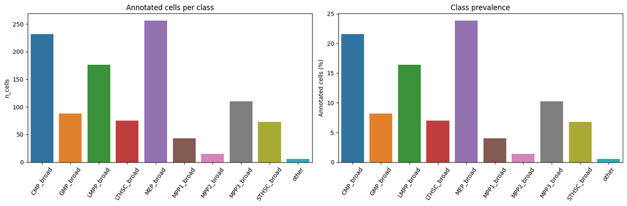

```python
class_counts = (
    train_for_mapping.groupby(["clusters", "cell_type"], observed=True)
    .size()
    .rename("n_cells")
    .reset_index()
    .sort_values("clusters")
)
class_counts["percentage"] = 100 * class_counts["n_cells"] / len(train_for_mapping)
class_counts["ratio_to_smallest"] = class_counts["n_cells"] / class_counts["n_cells"].min()
display(class_counts)

label_order = mapping_table["cell_type"].tolist()
palette = sns.color_palette("tab10", n_colors=len(label_order))
fig, axes = plt.subplots(1, 2, figsize=(15, 5))

sns.barplot(
    data=class_counts, x="cell_type", y="n_cells", hue="cell_type",
    order=label_order, palette=palette, legend=False, ax=axes[0],
)
axes[0].set_title("Annotated cells per class")
axes[0].set_xlabel("")
axes[0].tick_params(axis="x", rotation=55)

sns.barplot(
    data=class_counts, x="cell_type", y="percentage", hue="cell_type",
    order=label_order, palette=palette, legend=False, ax=axes[1],
)
axes[1].set_title("Class prevalence")
axes[1].set_ylabel("Annotated cells (%)")
axes[1].set_xlabel("")
axes[1].tick_params(axis="x", rotation=55)

plt.tight_layout()
plt.show()
```

The ten classes are far from balanced:

| Code | Cell type | Cells |
| --- | --- | --- |
| 0 | CMP_broad | 232 |
| 1 | GMP_broad | 88 |
| 2 | LMPP_broad | 176 |
| 3 | LTHSC_broad | 75 |
| 4 | MEP_broad | 256 |
| 5 | MPP1_broad | 43 |
| 6 | MPP2_broad | 15 |
| 7 | MPP3_broad | 110 |
| 8 | STHSC_broad | 73 |
| 9 | other | 6 |

**MEP_broad** is the largest group with 256 cells, while **MPP2_broad** (15 cells) and especially **other** (6 cells) are barely represented, a largest-to-smallest ratio of **42.7:1**. This imbalance is the single biggest constraint on the modelling choices made later in the notebook: with only six examples in `other`, even a 3-fold cross-validation split leaves just two examples per fold for that class.

## 5.3 Cell-Level Expression Summaries

If raw counts were available, the number of detected genes, total counts, and mitochondrial fraction would be central QC measurements. Here we first compute scale-neutral summaries:

- **detected genes:** number of genes with a positive stored value;
- **transformed-expression sum:** row sum on the supplied scale;
- **zero fraction:** proportion of genes with value zero;
- **mean positive expression:** mean among detected genes;
- **maximum stored expression:** largest value in the cell.

Differences between cell populations are not automatically defects. A biological state may express a different number of genes.

```python
adata_full.obs["detected_genes"] = (X_dense > 0).sum(axis=1)
adata_full.obs["transformed_expression_sum"] = X_dense.sum(axis=1)
adata_full.obs["zero_fraction"] = (X_dense == 0).mean(axis=1)
adata_full.obs["mean_positive_expression"] = np.divide(
    X_dense.sum(axis=1),
    adata_full.obs["detected_genes"].to_numpy(),
    out=np.zeros(adata_full.n_obs, dtype=float),
    where=adata_full.obs["detected_genes"].to_numpy() > 0,
)
adata_full.obs["maximum_expression"] = X_dense.max(axis=1)

cell_metrics = [
    "detected_genes", "transformed_expression_sum", "zero_fraction",
    "mean_positive_expression", "maximum_expression",
]
display(
    adata_full.obs[cell_metrics]
    .describe(percentiles=[0.01, 0.05, 0.25, 0.5, 0.75, 0.95, 0.99])
    .T
)
```

|  | count | mean | std | min | 1% | 5% | 25% | 50% | 75% | 95% | 99% | max |
| --- | --- | --- | --- | --- | --- | --- | --- | --- | --- | --- | --- | --- |
| detected_genes | 1499.0 | 2411.918612 | 239.169399 | 1635.000000 | 1889.000000 | 2025.000000 | 2245.500000 | 2408.000000 | 2567.500000 | 2825.000000 | 2950.280000 | 3151.000000 |
| transformed_expression_sum | 1499.0 | 10920.237793 | 1288.248763 | 6502.858098 | 8267.634161 | 8919.560366 | 9974.674649 | 10835.536040 | 11848.332272 | 13068.441932 | 13855.126385 | 15193.445126 |
| zero_fraction | 1499.0 | 0.437781 | 0.055750 | 0.265501 | 0.312289 | 0.341492 | 0.401515 | 0.438695 | 0.476573 | 0.527972 | 0.559674 | 0.618881 |
| mean_positive_expression | 1499.0 | 4.552302 | 0.552039 | 2.748637 | 3.333867 | 3.664994 | 4.165934 | 4.563839 | 4.923060 | 5.465828 | 5.840614 | 6.521866 |
| maximum_expression | 1499.0 | 13.752276 | 0.708456 | 12.377546 | 12.569810 | 12.838172 | 13.237685 | 13.624771 | 14.134802 | 15.082234 | 15.686107 | 17.637044 |

This step turns the five metrics into numbers, one row per cell, stored on `adata_full.obs` for reuse in every plot that follows. `detected_genes` and `zero_fraction` are two sides of the same coin: how many of the 4,290 genes have a positive value, and what fraction do not. `transformed_expression_sum` and `mean_positive_expression` describe how large those positive values are, in total and on average, and `maximum_expression` flags any single extreme value. The `.describe()` table uses extended percentiles (1st to 99th) instead of quartiles, the fastest way to notice an extreme tail before looking at anything visual.

The table shows a fairly tight, well-behaved distribution for four of the five metrics: the median cell has **2,408 detected genes** (5th-95th percentile: 2,025-2,825) and a **zero fraction of 0.439** (5th-95th percentile: 0.34-0.53), with no extreme long tail on either side. `maximum_expression` is the one metric with a visible tail: a mean of **13.75** against a maximum of **17.64**, meaning a handful of cells carry one exceptionally high single value. This alone is not a red flag, since a single strongly expressed transcript in an otherwise ordinary cell is expected in single-cell data, but it is a candidate explanation to remember if an odd outlier turns up later.

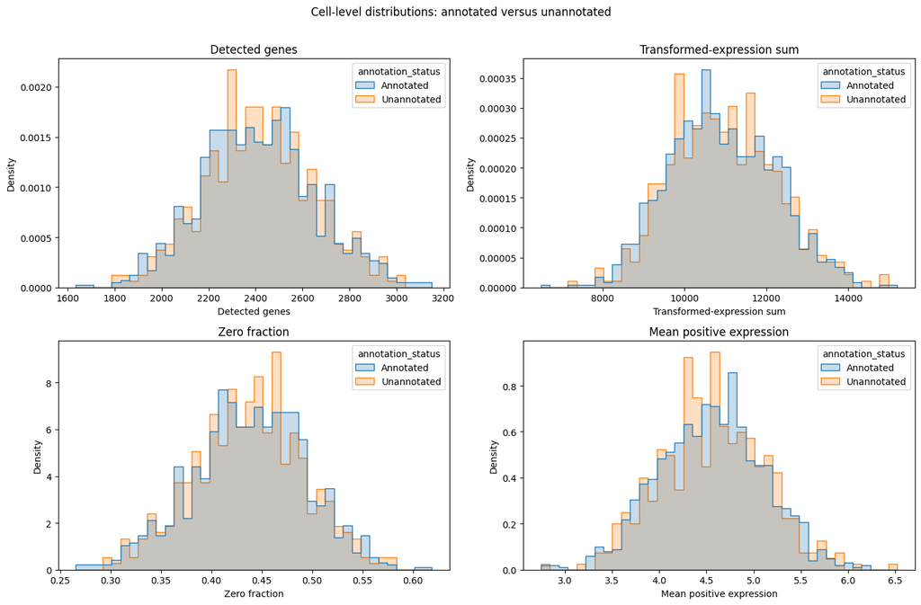

```python
fig, axes = plt.subplots(2, 2, figsize=(14, 9))
plot_metrics = [
    ("detected_genes", "Detected genes"),
    ("transformed_expression_sum", "Transformed-expression sum"),
    ("zero_fraction", "Zero fraction"),
    ("mean_positive_expression", "Mean positive expression"),
]

for ax, (column, label) in zip(axes.flat, plot_metrics):
    sns.histplot(
        data=adata_full.obs, x=column, hue="annotation_status",
        bins=40, stat="density", common_norm=False, element="step", ax=ax,
    )
    ax.set_title(label)
    ax.set_xlabel(label)

plt.suptitle("Cell-level distributions: annotated versus unannotated", y=1.01)
plt.tight_layout()
plt.show()
```

These four histograms compare the distribution of each metric between the 1,074 annotated cells and the 425 cells without supplied labels. They are drawn as density curves instead of raw counts, so the different group sizes do not distort the comparison, and as outlines instead of filled bars, so overlapping distributions stay readable. The comparison checks whether the two subsets appear to come from a similar measurement regime. A marked shift would suggest a technical batch difference or a biological domain represented unevenly by the annotated subset.

All four panels tell the same story: annotated and unannotated cells trace very similar single-peaked distributions, essentially one on top of the other, with no second bump or shifted peak. The unannotated curve looks visibly noisier because it contains fewer cells (425 versus 1,074), not because it forms an obviously separate technical population.

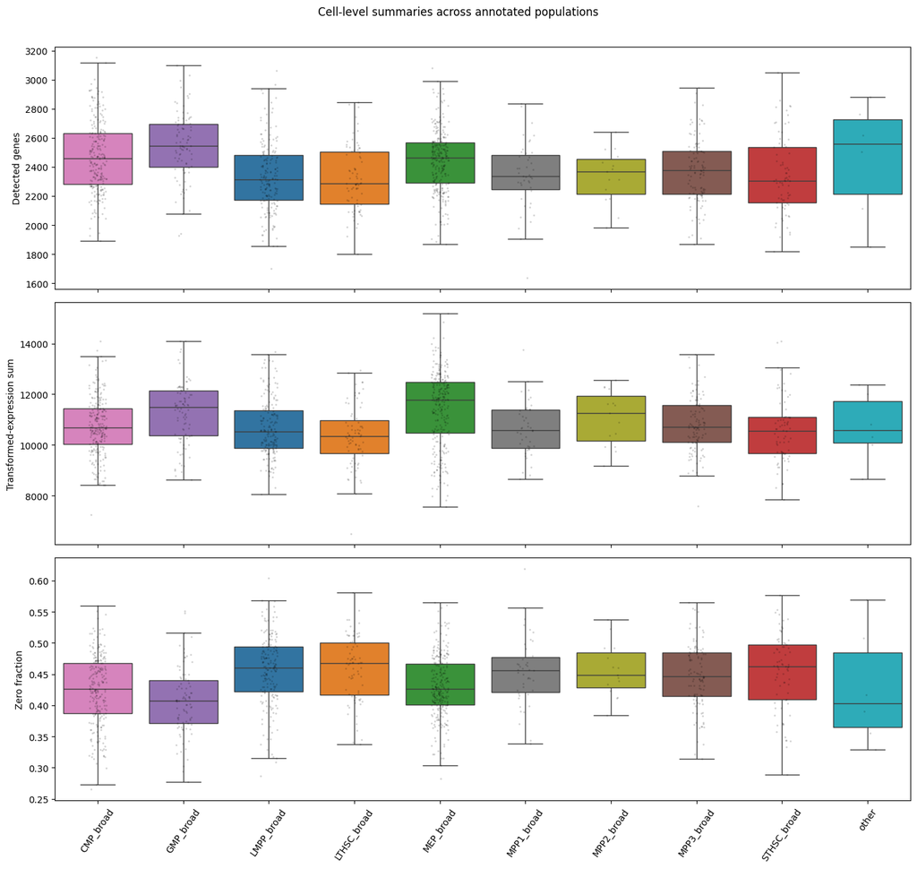

```python
annotated_mask = adata_full.obs["annotation_status"].eq("Annotated").to_numpy()
labeled_obs = adata_full.obs.loc[annotated_mask].copy()

fig, axes = plt.subplots(3, 1, figsize=(14, 13), sharex=True)
class_metric_plots = [
    ("detected_genes", "Detected genes"),
    ("transformed_expression_sum", "Transformed-expression sum"),
    ("zero_fraction", "Zero fraction"),
]

for ax, (column, label) in zip(axes, class_metric_plots):
    sns.boxplot(
        data=labeled_obs, x="cell_type", y=column, order=label_order,
        hue="cell_type", palette=palette, legend=False,
        showfliers=False, ax=ax,
    )
    sns.stripplot(
        data=labeled_obs, x="cell_type", y=column, order=label_order,
        color="black", alpha=0.18, size=2, ax=ax,
    )
    ax.set_ylabel(label)
    ax.set_xlabel("")

axes[-1].tick_params(axis="x", rotation=55)
plt.suptitle("Cell-level summaries across annotated populations", y=1.01)
plt.tight_layout()
plt.show()
```

Here the same three metrics are broken down by the ten known cell types instead of by annotation status, using a boxplot for the spread and a semi-transparent stripplot on top so individual cells in the very small classes stay visible. Classes keep the fixed order (`label_order`) used everywhere else, so each sits in the same position across every plot. The goal is to check whether any cell type has systematically different content, such as more or fewer detected genes or more zeros: that could be real biology, since some progenitor states are known to be transcriptionally quieter, or a technical artefact a later filtering step would need to account for.

No class stands sharply apart from the rest, but a consistent mild pattern runs across all three panels: **GMP_broad** tends to sit toward the richer end (more detected genes, higher expression sum, lower zero fraction), while **LTHSC_broad, STHSC_broad, LMPP_broad**, and **MPP1_broad** tend to sit toward the sparser end. **MEP_broad** has the highest median transformed-expression sum of any class. The `other` class has the widest box of all, which is expected given it has only 6 cells, so its position should be read with more caution than the others. None of these differences justifies treating any class differently in preprocessing. They are noted so a later difference in model performance for a specific class can be checked against this baseline instead of read straight away as a modelling failure.

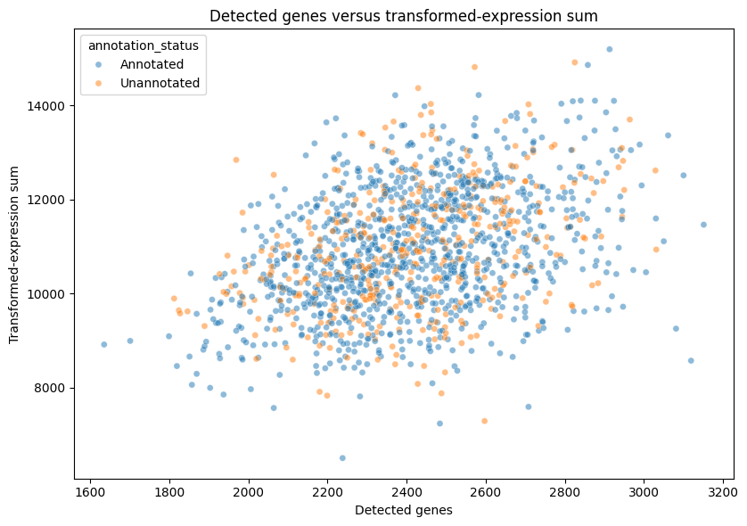

| cell_type | detected_genes | transformed_expression_sum | zero_fraction |
| --- | --- | --- | --- |
| CMP_broad | 2459.5 | 10672.208965 | 0.426690 |
| GMP_broad | 2543.5 | 11494.185710 | 0.407110 |
| LMPP_broad | 2315.5 | 10529.433497 | 0.460256 |
| LTHSC_broad | 2285.0 | 10353.557666 | 0.467366 |
| MEP_broad | 2462.5 | 11782.429358 | 0.425991 |
| MPP1_broad | 2335.0 | 10583.998650 | 0.455711 |
| MPP2_broad | 2368.0 | 11260.084926 | 0.448019 |
| MPP3_broad | 2376.5 | 10707.053845 | 0.446037 |
| STHSC_broad | 2306.0 | 10550.709166 | 0.462471 |
| other | 2560.0 | 10571.113967 | 0.403263 |

```python
fig, ax = plt.subplots(figsize=(8.5, 6))
sns.scatterplot(
    data=adata_full.obs,
    x="detected_genes", y="transformed_expression_sum",
    hue="annotation_status", alpha=0.5, s=26, ax=ax,
)
ax.set_title("Detected genes versus transformed-expression sum")
ax.set_xlabel("Detected genes")
ax.set_ylabel("Transformed-expression sum")
plt.tight_layout()
plt.show()

cell_rho, cell_rho_p = spearmanr(
    adata_full.obs["detected_genes"],
    adata_full.obs["transformed_expression_sum"],
)

class_medians = labeled_obs.groupby("cell_type", observed=True)[
    ["detected_genes", "transformed_expression_sum", "zero_fraction"]
].median().reindex(label_order)
display(class_medians)
```

## 5.4 Gene-Level Expression Summaries

Gene-level statistics distinguish broadly detected genes from rare or variable features:

- detection rate measures how often a gene is non-zero;
- mean expression measures its average magnitude on the supplied scale;
- variance measures spread but is naturally related to the mean;
- CV² divides variance by squared mean and can become unstable near zero.

Raw variance alone is not an HVG criterion because high-abundance genes have more opportunity to vary. Formal HVG selection will model variability relative to genes with similar mean expression.

```python
gene_symbols = adata_full.var["Symbol"].astype(str).to_numpy()
gene_ensembl = adata_full.var["ENSG"].astype(str).to_numpy()

gene_detection_count = (X_dense > 0).sum(axis=0)
gene_mean = X_dense.mean(axis=0)
gene_variance = X_dense.var(axis=0, ddof=1)
gene_nonzero_mean = np.divide(
    X_dense.sum(axis=0), gene_detection_count,
    out=np.zeros(adata_full.n_vars, dtype=float),
    where=gene_detection_count > 0,
)

gene_stats = pd.DataFrame({
    "gene_index": adata_full.var_names.astype(str),
    "ensembl_id": gene_ensembl,
    "symbol": gene_symbols,
    "n_cells_detected": gene_detection_count,
    "detection_rate": gene_detection_count / adata_full.n_obs,
    "mean_expression": gene_mean,
    "variance": gene_variance,
    "nonzero_mean": gene_nonzero_mean,
    "maximum_expression": X_dense.max(axis=0),
})
gene_stats["cv2"] = gene_stats["variance"] / np.maximum(
    gene_stats["mean_expression"] ** 2, 1e-12
)

display(gene_stats.describe(percentiles=[0.01, 0.05, 0.5, 0.95, 0.99]).T)
print("Genes detected in every cell:", int(gene_stats["detection_rate"].eq(1).sum()))
print("Genes detected in fewer than three cells:", int(gene_stats["n_cells_detected"].lt(3).sum()))
print("Zero-variance genes:", int(gene_stats["variance"].eq(0).sum()))
```

|  | count | mean | std | min | 1% | 5% | 50% | 95% | 99% | max |
| --- | --- | --- | --- | --- | --- | --- | --- | --- | --- | --- |
| n_cells_detected | 4290.0 | 842.765967 | 480.290933 | 3.000000 | 26.000000 | 77.450000 | 898.000000 | 1490.000000 | 1499.000000 | 1499.000000 |
| detection_rate | 4290.0 | 0.562219 | 0.320408 | 0.002001 | 0.017345 | 0.051668 | 0.599066 | 0.993996 | 1.000000 | 1.000000 |
| mean_expression | 4290.0 | 2.545510 | 2.259106 | 0.002653 | 0.029743 | 0.092970 | 1.970112 | 7.035883 | 9.196568 | 13.298916 |
| variance | 4290.0 | 5.771674 | 3.635642 | 0.004657 | 0.083770 | 0.274786 | 6.247551 | 10.777894 | 11.932348 | 15.326553 |
| nonzero_mean | 4290.0 | 3.716606 | 1.728260 | 0.972099 | 1.210000 | 1.414671 | 3.460847 | 7.092157 | 9.197441 | 13.298916 |
| maximum_expression | 4290.0 | 10.346998 | 1.237412 | 2.175632 | 6.472230 | 8.853582 | 10.335341 | 12.149745 | 13.598122 | 17.637044 |
| cv2 | 4290.0 | 8.572677 | 26.263631 | 0.002648 | 0.034180 | 0.148911 | 1.741634 | 35.944597 | 117.542916 | 661.570366 |

```
Genes detected in every cell: 95
Genes detected in fewer than three cells: 0
Zero-variance genes: 0
```

This step mirrors what was done for cells, with the gene as the unit of analysis. For each of the 4,290 genes, `detection_rate` counts what fraction of the 1,499 cells have a positive value, `mean_expression` and `variance` describe the average level and spread on the supplied scale, `nonzero_mean` restricts the average to cells where the gene is detected so a gene is not penalised for being sparse, and `cv2` normalises variance by the square of the mean, the first step toward separating a gene that varies for biological reasons from one that varies because it is highly expressed. The two counts printed below the table check whether the matrix has already been through minimal gene filtering.

The **95 genes detected in every single cell** deserve a more careful reading than "highly expressed". Detection is a stricter, binary property than average expression: a gene can have a respectable mean while still being absent in a meaningful fraction of cells, and most genes here behave that way, with a mean detection rate across all genes of only 0.56. A gene detected in **all 1,499 cells** is present at some level in every sampled state, from the most primitive stem cells to the most committed progenitors. Biologically that is the signature of a gene needed for basic survival and maintenance, such as translation, protein folding, or core metabolism, not of one tied to a lineage identity. That matters for later sections: a lineage marker is by definition expected to be *off* in some cell types, since that is what makes it useful for telling them apart. These 95 genes are therefore a natural list of genes we should **not** expect to appear later as differentially expressed markers between clusters, and if one did it would be worth a second look.

The detection-rate percentiles make the imbalance concrete: the 1st percentile sits at 0.017 (26 cells out of 1,499) while the 99th sits at 1.0. Genes range from almost never seen to always seen, and that spread is what later motivates working with a selected subset (HVGs) instead of treating all 4,290 as equally informative.

The skew in `cv2` points the same way. CV² measures variability *relative to* the average value, which makes it more informative than raw variance for comparing genes at very different expression levels. Its mean (8.57) sits far above its median (1.74), with a maximum of 661.6, so the distribution has a long right tail: most genes have unremarkable relative variability while a small number are dramatically noisier relative to their own average. Those tail genes are what a proper HVG procedure is designed to surface, and what a naive ranking by raw variance would fail to isolate, since raw variance is also inflated by expression level, as the next cell shows.

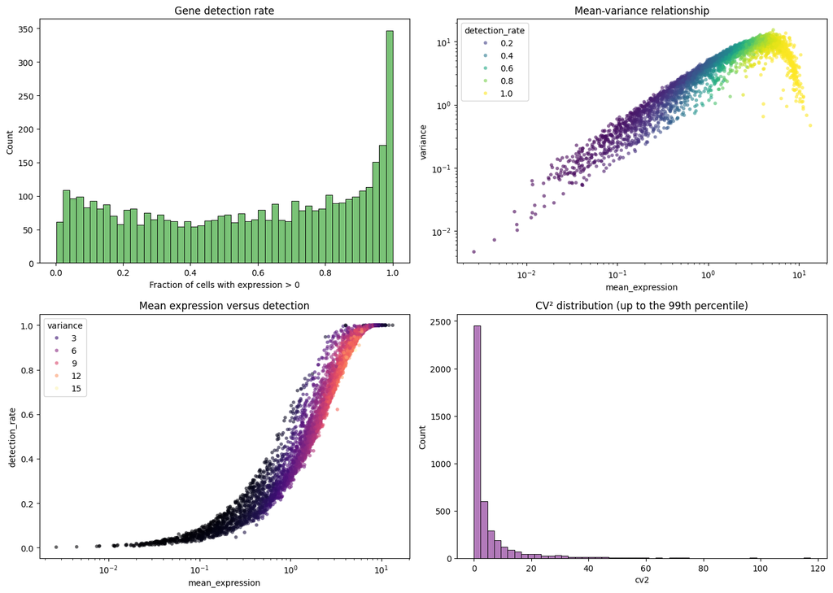

```python
fig, axes = plt.subplots(2, 2, figsize=(14, 10))

sns.histplot(gene_stats["detection_rate"], bins=50, color="#4daf4a", ax=axes[0, 0])
axes[0, 0].set_title("Gene detection rate")
axes[0, 0].set_xlabel("Fraction of cells with expression > 0")

sns.scatterplot(
    data=gene_stats, x="mean_expression", y="variance",
    hue="detection_rate", palette="viridis", linewidth=0,
    alpha=0.6, s=18, ax=axes[0, 1],
)
axes[0, 1].set_xscale("log")
axes[0, 1].set_yscale("log")
axes[0, 1].set_title("Mean-variance relationship")

sns.scatterplot(
    data=gene_stats, x="mean_expression", y="detection_rate",
    hue="variance", palette="magma", linewidth=0,
    alpha=0.6, s=18, ax=axes[1, 0],
)
axes[1, 0].set_xscale("log")
axes[1, 0].set_title("Mean expression versus detection")

cv2_limit = gene_stats["cv2"].quantile(0.99)
sns.histplot(
    gene_stats.loc[gene_stats["cv2"] <= cv2_limit, "cv2"],
    bins=50, color="#984ea3", ax=axes[1, 1],
)
axes[1, 1].set_title("CV² distribution (up to the 99th percentile)")

plt.tight_layout()
plt.show()
```

The detection-rate histogram is not a simple bell curve: a cluster of genes near zero detection, a broad flat middle range, and then the single tallest bar in the plot at a detection rate of 1.0. That spike is the visual counterpart of the 95 universally detected genes discussed above: a sizeable group behaves almost like an always-on switch, while the rest spreads across every intermediate level of partial detection.

The mean-variance panel is the most important one for justifying later HVG choices. At low mean expression (dark purple, low detection rate), variance rises roughly in step with the mean, since these genes are rarely detected and most of their values are zero. As mean expression increases, variance keeps climbing until detection approaches 1 (green to yellow). Then, for genes with both the highest mean expression and detection at or near 100%, variance visibly **bends downward** even as the mean keeps rising: once a gene is expressed in essentially every cell at a high level, its values already sit near a ceiling and there is less room for cell-to-cell differences to show up as spread. This is the concrete reason raw variance misleads as a ranking criterion. It would rank these saturated, always-on genes as unremarkable, defensible in itself since they no longer separate cells well, but it would also fail to reward a moderately expressed gene varying for real biological reasons, because both effects end up tangled in one number.

The CV² histogram confirms the same skew seen in the table. More than half of the 4,290 genes fall into the first bin near CV² ≈ 0, and even after restricting the plot to the 99th percentile a long thin tail still stretches past 100. The top 1% by relative variability is itself far from uniform: some of those genes are an order of magnitude noisier, relative to their own mean, than others in the same slice.

To make the mean-variance argument concrete, this step looks at the two extremes directly: the 12 genes with the highest mean stored expression, and, separately, the 12 genes with the highest raw variance. Showing both the table and the bar chart together makes the ranking easy to scan while keeping the exact numbers available to quote in the text.

```
Top genes by mean stored expression
```

|  | symbol | mean_expression | detection_rate | variance |
| --- | --- | --- | --- | --- |
| 56 | B2m | 13.298916 | 1.0 | 0.468267 |
| 3119 | Slc34a2 | 12.109084 | 1.0 | 0.678953 |
| 292 | Eif5a | 11.164401 | 1.0 | 1.347614 |
| 4192 | Atp5f1b | 11.129381 | 1.0 | 1.311822 |
| 3450 | Gpx1 | 11.101551 | 1.0 | 0.855442 |
| 602 | Fth1 | 11.089959 | 1.0 | 0.924957 |
| 2667 | Ly6e | 10.970767 | 1.0 | 1.125354 |
| 3887 | Tubb5 | 10.857443 | 1.0 | 1.857831 |
| 1052 | Npm1 | 10.716581 | 1.0 | 1.105301 |
| 2114 | ENSMUSG00000097971 | 10.570576 | 1.0 | 1.459168 |
| 1542 | Car2 | 10.428324 | 1.0 | 6.169472 |
| 3343 | Ldha | 10.425193 | 1.0 | 2.150875 |

```
Top genes by raw variance
```

|  | symbol | variance | mean_expression | detection_rate |
| --- | --- | --- | --- | --- |
| 3783 | Fos | 15.326553 | 5.196016 | 0.887258 |
| 2796 | Ly6a | 14.089352 | 5.065607 | 0.942628 |
| 675 | Mpl | 13.730426 | 4.766327 | 0.936624 |
| 1019 | Car1 | 13.607850 | 7.132696 | 0.996664 |
| 3539 | Dusp1 | 13.287822 | 4.622397 | 0.871247 |
| 1953 | Flt3 | 13.077007 | 5.273283 | 0.963976 |
| 1346 | Dntt | 13.050693 | 4.502739 | 0.931955 |
| 723 | Serpina3g | 13.041081 | 5.525455 | 0.955304 |
| 2122 | Rgs1 | 13.026762 | 4.369993 | 0.879920 |
| 3716 | Jun | 12.997576 | 5.691874 | 0.909940 |
| 1583 | Ces2g | 12.917269 | 4.348657 | 0.902602 |
| 2510 | Ctsg | 12.823579 | 5.227618 | 0.954636 |

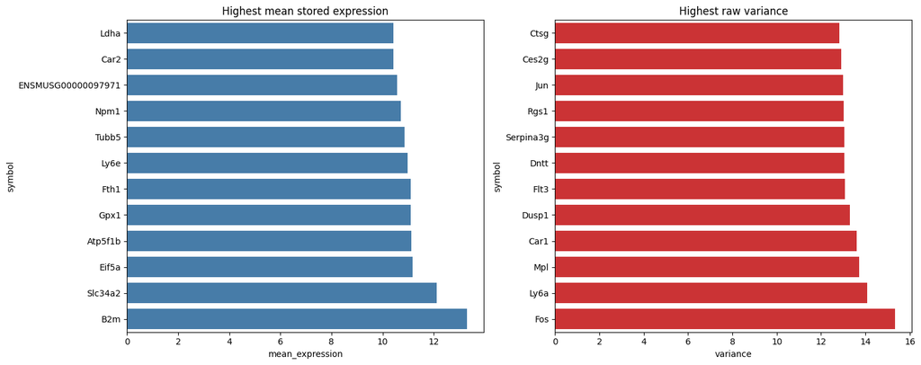

```python
top_n = 12
top_mean = gene_stats.nlargest(top_n, "mean_expression")
top_variance = gene_stats.nlargest(top_n, "variance")

print("Top genes by mean stored expression")
display(top_mean[["symbol", "mean_expression", "detection_rate", "variance"]])
print("Top genes by raw variance")
display(top_variance[["symbol", "variance", "mean_expression", "detection_rate"]])

fig, axes = plt.subplots(1, 2, figsize=(15, 6))
sns.barplot(
    data=top_mean.sort_values("mean_expression"),
    x="mean_expression", y="symbol", color="#377eb8", ax=axes[0],
)
axes[0].set_title("Highest mean stored expression")

sns.barplot(
    data=top_variance.sort_values("variance"),
    x="variance", y="symbol", color="#e41a1c", ax=axes[1],
)
axes[1].set_title("Highest raw variance")

plt.tight_layout()
plt.show()
```

The two lists barely overlap, and looking at what the genes are explains why. `B2m` tops the mean-expression list with the lowest variance of any gene in the top twelve (0.47): it encodes beta-2 microglobulin, part of the MHC class I complex present on virtually every nucleated cell, so 100% detection with very little spread is what should be expected. Several of its neighbours, `Eif5a` (a translation factor), `Atp5f1b` (a subunit of mitochondrial ATP synthase) and `Gpx1` (an antioxidant enzyme), belong to the same category: genes needed for basic cell maintenance, not for lineage identity. `Fth1` is a partial exception. It stores iron intracellularly, a generically useful function that becomes specifically important in erythroid cells because of their demand for iron during hemoglobin synthesis, so its presence is plausible both as a housekeeping gene and as a mild echo of this dataset's strong erythroid representation (`MEP_broad` is the largest class).

The high-variance list is where the biological signal shows up, and where a limitation shows up alongside it. Several of these genes are lineage markers already introduced earlier: `Ly6a` (stem/early progenitor), `Mpl` (the thrombopoietin receptor, tied to megakaryocyte bias), `Flt3` (lymphoid priming), and `Dntt`, encoding terminal deoxynucleotidyl transferase, a well-known marker of early lymphoid progenitors that was not in the canonical panel but fits it well. `Car1` and `Ctsg` are similarly consistent with erythroid and granulocyte/myeloid maturation. Raw variance, imperfect as it is, is already surfacing genes that make biological sense on this dataset rather than random noise.

At the same time, three of the twelve highest-variance genes (`Fos`, `Jun`, and `Dusp1`) are not lineage markers at all. They are classic **immediate-early genes**, switched on rapidly by a wide range of cellular stresses, and are specifically known in the scRNA-seq literature to be induced by the mechanical and enzymatic stress of tissue dissociation during sample preparation, independently of a cell's biological identity. Their presence does not mean anything here is wrong, since variability from real biology and from sample handling can coexist in the same ranking. It is a dataset-specific reason to treat high variance as a starting point for HVG selection and not a guarantee of biological relevance, and a reminder to sanity-check top-ranked genes in any later differential-expression result against this list.

Across the whole section, the numbers converge on one message: raw variance on its own would make a poor gene-selection rule on this dataset. The gene-level statistics show that detection and expression are already curated and not a raw whole-transcriptome dump, no gene is detected in fewer than three cells, none has zero variance, and 95 genes are detected everywhere. The mean-variance relationship is not monotonic: variance grows with expression only up to a point, then falls again for the handful of genes expressed at high, saturating levels in essentially every cell. Those are the genes that top the mean-expression ranking (`B2m`, `Slc34a2`, `Eif5a`...), and they turn out to be general maintenance genes, not markers of cell identity. The genes that top the variance ranking instead sit at a moderate expression level and include several genes already flagged earlier as canonical lineage or stem markers (`Ly6a`, `Mpl`, `Flt3`). Put together, this is the dataset-specific evidence for why the notebook does not rank genes by raw variance for HVG selection later on, but needs a criterion that compares each gene's variability against genes of similar mean expression.

## 5.5 Technical and Lineage-Associated Gene Families

Four gene families are checked for the same general reason single-cell pipelines usually check them, but not for the same specific reason in each case.

- **Mitochondrial genes** (`MT-*`) are the classic technical signal: when a cell is damaged or dying its membrane leaks, and cytoplasmic RNA is lost more readily than RNA enclosed in mitochondria, so an unusually high mitochondrial share normally flags a low-quality cell and not biology.
- **Ribosomal genes** (`RPL`/`RPS`) sit in a grey zone: they can reflect a more translationally active cell, or technical variation in how a cell was handled.
- **Hemoglobin genes** (`HB*`) and **immunoglobulin genes** (`IGH`/`IGK`/`IGL`) are different again. In most tissues they would barely register, but in a bone-marrow dataset they are direct biological signal: hemoglobin marks commitment toward the erythroid lineage, immunoglobulin marks a lymphoid, B-cell-associated programme. The same computed quantity is a quality-control flag for two families and a biological readout for the other two.

No precomputed flag is supplied, since `adata_full.var` carries only `ENSG` and `Symbol`, so each family is identified from the gene symbol text against a small set of prefixes: `MT-`, `RPL`/`RPS` (excluding `RPS6K`, a kinase whose name matches the pattern without being a ribosomal protein), `HB` (excluding `HBP`), and `IGH`/`IGK`/`IGL`. Symbols are upper-cased before matching, because mouse symbols conventionally use a leading capital (`Mt-Nd1`, `Hbb`) where human symbols are all capitals (`MT-ND1`, `HBB`), and normalising case first makes the same patterns work either way.

One naming choice needs stating. The value computed per family is a **transformed-expression share**, not the `pct_counts_mt`-style read fraction of standard pipelines. That metric is defined on raw counts, where summing reads across genes and dividing by a cell's total gives an exact fraction of its sequencing output. Here the stored values are already log-transformed, and summing them is not equivalent to summing the underlying counts (log(a) + log(b) ≠ log(a + b)). What follows is therefore a monotonic, order-preserving proxy for the read fraction, close enough to compare cells against each other but not something to quote as a standard QC percentage.

```python
symbol_upper = pd.Series(gene_symbols).str.upper()
family_masks = {
    "mitochondrial": symbol_upper.str.startswith("MT-").to_numpy(),
    "ribosomal": symbol_upper.str.match(r"^(RPL|RPS(?!6K))").to_numpy(),
    "hemoglobin": symbol_upper.str.match(r"^HB(?!P)").to_numpy(),
    "immunoglobulin": symbol_upper.str.startswith(("IGH", "IGK", "IGL")).to_numpy(),
}

row_stored_sum = X_dense.sum(axis=1)
family_rows = []
for family, mask in family_masks.items():
    symbols = gene_symbols[mask].tolist()
    family_rows.append({
        "family": family,
        "n_genes": int(mask.sum()),
        "symbols": ", ".join(symbols[:16]) + (" ..." if len(symbols) > 16 else ""),
    })
    column = f"{family}_transformed_share_pct"
    adata_full.obs[column] = (
        100 * X_dense[:, mask].sum(axis=1) / row_stored_sum if mask.any() else 0.0
    )

family_summary = pd.DataFrame(family_rows)
display(family_summary)
```

|  | family | n_genes | symbols |
| --- | --- | --- | --- |
| 0 | mitochondrial | 0 |  |
| 1 | ribosomal | 2 | Rps27l, Rpl39l |
| 2 | hemoglobin | 4 | Hbb-bt, Hbb-bs, Hba-a1, Hba-a2 |
| 3 | immunoglobulin | 38 | Igkv14-130, Igkv3-9, Igkv14-126, Igll1, Igkc, ... |

The family table is as informative for what it does *not* find as for what it does.

**Mitochondrial genes: 0.** Not low: zero. Not a single `MT-*` gene exists anywhere in this 4,290-gene panel. The most common QC signal in scRNA-seq, the mitochondrial-read percentage used almost everywhere to flag dying or damaged cells, cannot be computed on this dataset at all, for any cell, under any definition. It is not that the supplied cells are pristine; the feature is structurally absent from what we were given, and that absence has to be stated plainly instead of silently worked around.

**Ribosomal genes: 2** (`Rps27l`, `Rpl39l`). A real ribosomal-content signal normally rests on dozens of core `RPL`/`RPS` genes. Finding only two, and two relatively minor paralogs at that, is further evidence, on top of section 5.4, that this matrix is a curated subset of the mouse transcriptome and not the whole thing. With two genes behind it, the ribosomal panel is too thin to trust as a general activity signal.

**Hemoglobin genes: 4** (`Hbb-bt`, `Hbb-bs`, `Hba-a1`, `Hba-a2`): the two mouse adult beta-globin genes and the two alpha-globin genes, a textbook-complete adult set.

**Immunoglobulin genes: 38** (`Igkv14-130`, `Igkv3-9`, `Igll1`, `Igkc` and others, kappa and lambda light-chain genes).

The two biologically informative families are therefore well represented and the two technical ones are not, which fixes what the histograms below can and cannot be asked to show.

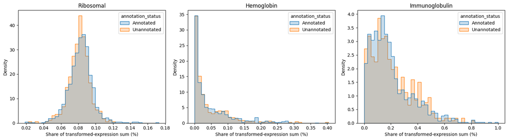

```python
family_columns = [
    f"{family}_transformed_share_pct"
    for family, mask in family_masks.items() if mask.any()
]

fig, axes = plt.subplots(1, len(family_columns), figsize=(16, 4.5))
if len(family_columns) == 1:
    axes = [axes]

for ax, column in zip(axes, family_columns):
    family = column.replace("_transformed_share_pct", "")
    sns.histplot(
        data=adata_full.obs, x=column, hue="annotation_status",
        bins=40, stat="density", common_norm=False, element="step", ax=ax,
    )
    ax.set_title(family.capitalize())
    ax.set_xlabel("Share of transformed-expression sum (%)")

plt.tight_layout()
plt.show()
```

Each panel is a histogram of one family's `transformed_expression_share_pct`: for every cell, the percentage of its total transformed-expression sum coming from that family's genes. Each is split into annotated and unannotated cells and normalised to density instead of raw counts, so the different group sizes (1,074 versus 425) sit on the same vertical scale. Mitochondrial genes are absent from the figure, since with zero genes behind that family there is nothing to plot.

**Ribosomal** is the narrowest and most symmetric: essentially every cell falls within roughly 0.02% to 0.18%, with a single sharp peak around 0.08% and almost no tail. With only two genes behind it, this panel shows the combined behaviour of `Rps27l` and `Rpl39l` rather than a broad ribosomal programme, and should be read as a narrow technical curiosity, not as an axis of biological variation.

**Hemoglobin** looks nothing like it: a tall spike at the low end, a long thin right tail out to roughly 0.4%, and a small secondary bump around 0.15-0.2% instead of a smooth decay. That is the classic shape of a signal off in most cells and meaningfully on in a minority, consistent with hemoglobin transcription being near-absent in most progenitors and switching on as cells commit toward the erythroid programme. The secondary bump suggests the "on" cells cluster loosely around a second typical value rather than spreading evenly along the tail, which would be consistent with a discrete erythroid-committed subgroup. That is worth rechecking once cell-type labels are reintroduced, plausibly among `MEP_broad`.

**Immunoglobulin** sits between the two: right-skewed, peaking around 0.1-0.15%, but broader than hemoglobin, with a fatter tail toward 1% and no sharp spike at zero. Some of that breadth is expected from averaging over 38 genes instead of 4, but the skew and the real density past 0.5% remain compatible with a graded lymphoid-priming signal stronger in some cells than others, and not with a flat baseline shared by the whole population.

In all three panels the annotated and unannotated curves track each other closely at every point, with no group shifted toward higher or lower shares. This is the same annotated-versus-unannotated check run earlier on the cell-level and gene-level summaries, repeated on a different kind of feature, and it returns the same answer.

## 5.6 Annotated Versus Unannotated Cells

The annotated and unannotated subsets are compared using label-free summaries before supervised modelling. A large shift could indicate a different technical batch or an underrepresented biological domain and would limit how broadly conclusions drawn from the labelled subset could be interpreted.

The Mann-Whitney test compares ranks without assuming normality. It is accompanied by a rank-biserial effect size because statistical significance alone does not quantify practical separation. Gene-wise mean expression provides a complementary global comparison.

```python
status_rows = []
for metric in cell_metrics:
    annotated_values = adata_full.obs.loc[annotated_mask, metric].to_numpy()
    unannotated_values = adata_full.obs.loc[~annotated_mask, metric].to_numpy()
    test = mannwhitneyu(annotated_values, unannotated_values, alternative="two-sided")
    rank_biserial = 2 * test.statistic / (
        annotated_values.size * unannotated_values.size
    ) - 1
    status_rows.append({
        "metric": metric,
        "annotated_median": np.median(annotated_values),
        "unannotated_median": np.median(unannotated_values),
        "rank_biserial": rank_biserial,
        "p_value": test.pvalue,
    })

status_comparison = pd.DataFrame(status_rows).set_index("metric")
display(status_comparison)
```

| metric | annotated_median | unannotated_median | rank_biserial | p_value |
| --- | --- | --- | --- | --- |
| detected_genes | 2404.500000 | 2418.000000 | -0.014551 | 0.660230 |
| transformed_expression_sum | 10801.938585 | 10916.285538 | -0.021203 | 0.521809 |
| zero_fraction | 0.439510 | 0.436364 | 0.014551 | 0.660230 |
| mean_positive_expression | 4.559652 | 4.575141 | -0.010753 | 0.745322 |
| maximum_expression | 13.628927 | 13.611468 | 0.029883 | 0.366622 |

None of the five Mann-Whitney tests comes close to significance at any conventional threshold (p-values range from 0.37 to 0.75), and every rank-biserial effect size sits under 0.03 in absolute value (from -0.021 for `transformed_expression_sum` to 0.030 for `maximum_expression`). Rank-biserial is easiest to read as a probability-of-superiority statistic: a value of 0 means that, given one randomly chosen annotated cell and one randomly chosen unannotated cell, it is essentially a coin flip which one has the higher value on that metric. Values this close to zero across all five metrics say the two groups are, for practical purposes, statistically indistinguishable on every cell-level summary checked so far. The annotated and unannotated medians in the table differ only in the third or fourth significant figure for every metric.

```
Spearman rho (annotated vs unannotated gene means): 0.9977
p-value: 0
```

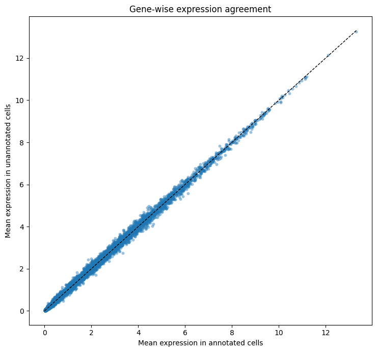

```python
annotated_gene_mean = X_dense[annotated_mask].mean(axis=0)
unannotated_gene_mean = X_dense[~annotated_mask].mean(axis=0)
gene_mean_rho, gene_mean_p = spearmanr(annotated_gene_mean, unannotated_gene_mean)
print(f"Spearman rho (annotated vs unannotated gene means): {gene_mean_rho:.4f}")
print(f"p-value: {gene_mean_p:.4g}")

fig, ax = plt.subplots(figsize=(7.5, 7))
sns.scatterplot(
    x=annotated_gene_mean, y=unannotated_gene_mean,
    alpha=0.45, s=18, linewidth=0, ax=ax,
)

plot_limit = max(annotated_gene_mean.max(), unannotated_gene_mean.max())
ax.plot([0, plot_limit], [0, plot_limit], "--", color="black", linewidth=1)
ax.set_xlabel("Mean expression in annotated cells")
ax.set_ylabel("Mean expression in unannotated cells")
ax.set_title("Gene-wise expression agreement")
plt.tight_layout()
plt.show()
```

The Spearman correlation behind the plot, **rho = 0.9977**, is about as close to perfect agreement as two independently estimated sets of 4,290 means could get. With the five non-significant, near-zero-effect Mann-Whitney tests above, this is as strong a case as label-free evidence can make that the 425 unannotated profiles were not measured differently, handled differently, or drawn from a clearly different technical population than the 1,074 labelled cells.

What this cannot rule out is a **class-composition** difference. Agreement on 4,290 gene averages and five cell-level summaries says the two groups look alike in bulk, but nothing about whether the *mixture* of the ten cell types among the 425 matches the mixture in the 1,074. That information is, by construction, what is missing, and no label-free comparison can recover it. The comparison still cannot reveal the unknown class mixture of the unannotated subset. Supervised performance is therefore estimated only through held-out annotated cells, while the unannotated profiles contribute solely to explicitly label-free or transductive analyses.

## 5.7 Canonical Marker Programmes

Section 4.4 introduced the canonical marker panel and the classes it was expected to align with, fixed before this data was inspected. Here that panel is checked against the supplied labels: if a cell is annotated `STHSC_broad`, does it switch on the genes associated with early stem/progenitor states, or not?

Three complementary views are used, because each hides something the others show:

- A **dot plot** combines two quantities per gene-by-class combination: average expression as colour, and the fraction of cells in that class detecting the gene as dot size. A large dark dot means a marker both broadly detected and comparatively strongly expressed in that class.
- A **heatmap** presents the same information as a compact numeric grid, easier to scan across many genes and classes at once.
- Selected **violin plots** show the full within-class distribution instead of a summary number, which matters because a class-level average can hide a class that is really a mix of one strongly positive and one essentially negative subgroup.

All three are built on the complete, unscaled expression matrix, not the z-scored analysis copy used later for PCA and clustering. Z-scaling forces every gene to the same mean and spread, which is what distance-based methods need, but it would erase the original expression scale this section depends on: the question here is how strongly a marker is expressed, not where a rescaled value sits relative to unrelated genes.

```python
marker_sets = {
    "Stem / early progenitor": ["Hlf", "Ly6a", "Gata2", "Kit"],
    "Lymphoid priming": ["Rag1", "Rag2", "Flt3"],
    "Megakaryocytic bias": ["Pf4"],
    "Granulocyte-monocyte": ["Mpo", "Elane"],
    "Erythroid / MEP": ["Gata1", "Epor"],
}

available_symbols = set(gene_symbols)
marker_availability = pd.DataFrame([
    {"program": program, "marker": marker, "available": marker in available_symbols}
    for program, markers in marker_sets.items() for marker in markers
])
display(marker_availability)

available_marker_sets = {
    program: [marker for marker in markers if marker in available_symbols]
    for program, markers in marker_sets.items()
}
available_marker_sets = {
    program: markers for program, markers in available_marker_sets.items() if markers
}
all_markers = [marker for markers in available_marker_sets.values() for marker in markers]
print(f"Available markers: {len(all_markers)}/{len(marker_availability)}")
```

|  | program | marker | available |
| --- | --- | --- | --- |
| 0 | Stem / early progenitor | Hlf | True |
| 1 | Stem / early progenitor | Ly6a | True |
| 2 | Stem / early progenitor | Gata2 | True |
| 3 | Stem / early progenitor | Kit | True |
| 4 | Lymphoid priming | Rag1 | True |
| 5 | Lymphoid priming | Rag2 | True |
| 6 | Lymphoid priming | Flt3 | True |
| 7 | Megakaryocytic bias | Pf4 | True |
| 8 | Granulocyte-monocyte | Mpo | True |
| 9 | Granulocyte-monocyte | Elane | True |
| 10 | Erythroid / MEP | Gata1 | True |
| 11 | Erythroid / MEP | Epor | True |

```
Available markers: 12/12
```

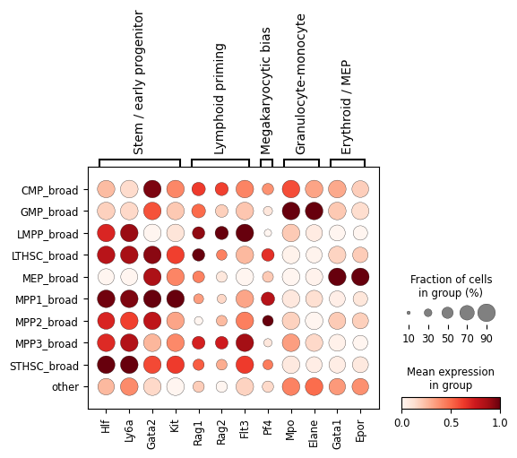

```python
adata_symbols = adata_full.copy()
adata_symbols.var_names = adata_symbols.var["Symbol"].astype(str)
adata_symbols.var_names_make_unique()
labeled_adata = adata_symbols[annotated_mask].copy()
labeled_adata.obs["cell_type"] = pd.Categorical(
    labeled_adata.obs["cell_type"], categories=label_order, ordered=True
)

sc.pl.dotplot(
    labeled_adata,
    var_names=available_marker_sets,
    groupby="cell_type",
    categories_order=label_order,
    standard_scale="var",
    color_map="Reds",
    dot_max=0.9,
    show=True,
)
```

### Reading the Dot Plot

Dot size is the fraction of cells with a positive value. Colour is the average expression after scaling each marker across the displayed classes, so a large dark dot combines broad detection with high expression relative to other populations. Because colour is relative within each gene, a dark `Mpo` dot and a dark `Hlf` dot are each high only against that gene's own range across classes; they cannot be compared to each other on a shared absolute scale.

One general pattern is worth carrying forward: no dot in the plot is fully white or absent. Every class shows some signal for every marker, which fits the running theme that hematopoietic differentiation behaves like a continuum and not like switches cleanly on in one class and off everywhere else.

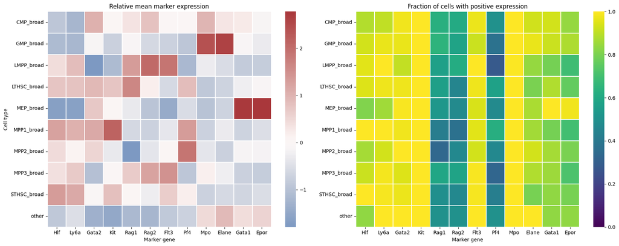

```python
symbol_to_first_index = {}
for index, symbol in enumerate(gene_symbols):
    symbol_to_first_index.setdefault(symbol, index)

marker_indices = [symbol_to_first_index[marker] for marker in all_markers]
marker_frame = pd.DataFrame(
    X_dense[annotated_mask][:, marker_indices], columns=all_markers
)
marker_frame["cell_type"] = adata_full.obs.loc[annotated_mask, "cell_type"].to_numpy()

marker_means = (
    marker_frame.groupby("cell_type", observed=True)[all_markers]
    .mean().reindex(label_order)
)
marker_positive_fraction = (
    marker_frame.assign(**{marker: marker_frame[marker] > 0 for marker in all_markers})
    .groupby("cell_type", observed=True)[all_markers]
    .mean().reindex(label_order)
)
marker_mean_z = (
    (marker_means - marker_means.mean(axis=0))
    / marker_means.std(axis=0, ddof=0).replace(0, np.nan)
)

fig, axes = plt.subplots(1, 2, figsize=(18, 7))
sns.heatmap(marker_mean_z, cmap="vlag", center=0, linewidths=0.3, ax=axes[0])
axes[0].set_title("Relative mean marker expression")
axes[0].set_xlabel("Marker gene")
axes[0].set_ylabel("Cell type")

sns.heatmap(
    marker_positive_fraction, cmap="viridis", vmin=0, vmax=1,
    linewidths=0.3, ax=axes[1],
)
axes[1].set_title("Fraction of cells with positive expression")
axes[1].set_xlabel("Marker gene")
axes[1].set_ylabel("")

plt.tight_layout()
plt.show()
```

### Reading the Heatmap

Both panels show the same classes-by-markers grid, each encoding one quantity through colour alone. The left panel is a **z-score**: for each marker independently, its per-class mean expression is centred and scaled by that gene's own mean and standard deviation across the ten classes, so dark red means high for this gene relative to how it varies across classes, and dark blue means low. As with the dot plot, colours compare only within a column. The right panel shows the **fraction of cells with a positive value** on a fixed 0-to-1 scale, comparable across the whole grid: yellow means most cells in that class detect the gene at all, dark purple means most do not, regardless of how strongly it is expressed when they do.

The left panel confirms and sharpens the dot plot. The four programmes tied to a single dominant class remain unambiguous: `Mpo` and `Elane` are the two darkest cells in the grid, both in `GMP_broad`; `Gata1` and `Epor` are equally dark in `MEP_broad`; the stem markers are darkest across `STHSC_broad`, `LTHSC_broad`, and `MPP1_broad`; `Rag2` and `Flt3` are darkest in `LMPP_broad`. `Pf4`, only mildly and diffusely elevated in the dot plot, stands out clearly here: once scaled against its own range, it is unambiguously darkest in `MPP2_broad`, the class it was chosen to mark. This is why the notebook uses more than one view of the same evidence, since a weak signal hard to see on one scale can become clear on another without the underlying data changing.

The `other` row is worth reading on its own. Across almost every marker column it sits pale blue, below the class average, with only a faint pink tint on the myeloid and erythroid markers, and no programme elevated the way one is for every other row. That fits how `other` was described from the start: a residual label for cells that did not fit cleanly elsewhere, not a coherent population with its own transcriptional identity.

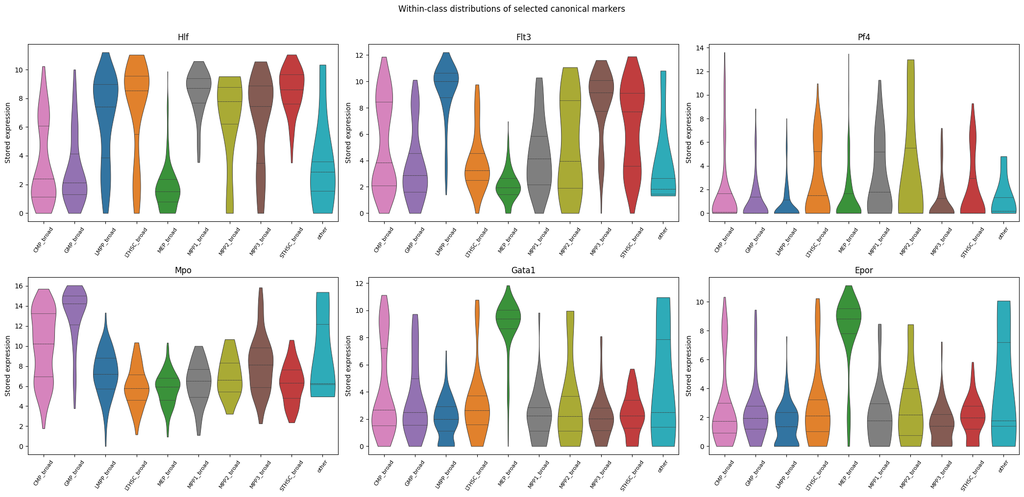

```python
selected_violin_markers = [
    marker for marker in ["Hlf", "Flt3", "Pf4", "Mpo", "Gata1", "Epor"]
    if marker in marker_frame.columns
]

violin_long = marker_frame[["cell_type", *selected_violin_markers]].melt(
    id_vars="cell_type", var_name="marker", value_name="expression"
)

fig, axes = plt.subplots(2, 3, figsize=(21, 10))
for ax, marker in zip(axes.flat, selected_violin_markers):
    sns.violinplot(
        data=violin_long.loc[violin_long["marker"].eq(marker)],
        x="cell_type", y="expression", order=label_order,
        hue="cell_type", palette=palette, legend=False,
        cut=0, inner="quartile", linewidth=0.7, ax=ax,
    )
    ax.set_title(marker)
    ax.set_xlabel("")
    ax.set_ylabel("Stored expression")
    ax.tick_params(axis="x", rotation=55, labelsize=8)

plt.suptitle("Within-class distributions of selected canonical markers", y=1.01)
plt.tight_layout()
plt.show()
```

### Reading the Violin Plots

Six markers are shown, one per panel, enough to cover a representative gene from each of the five programmes without redrawing the same argument twelve times. Each panel gives the full distribution of one gene's stored expression across individual cells in each class, in the same fixed class order used everywhere else. Violin width at a given height is proportional to how many cells sit at that value, and the three internal lines mark the 25th, 50th, and 75th percentiles. Unlike the dot plot and the heatmap, which collapse a class to one or two summary numbers, the shape is built from every individual cell. That is what lets the violin catch something the other views cannot: if a class is really a mix of a low-expressing and a high-expressing group, the average lands in between and looks unremarkable, while the violin shows two separate bulges.

`Gata1` and `Epor` give the cleanest signal in the panel. In `MEP_broad` both violins are tall, narrow, and sit almost entirely at high values with essentially no low-expressing tail, the closest thing to an on/off switch in this marker set, while every other class shows a low, narrow distribution for both. This is the strongest single piece of evidence in the marker analysis that `MEP_broad` corresponds to a real erythroid programme and not to an arbitrary label.

`Hlf` and `Flt3` are more layered. Across the stem/MPP/LMPP classes both genes sit at generally high values, matching the dot plot, but several of these violins are visibly **bimodal**: a wide body stretching from near zero up past 8 instead of one bump on the median. `CMP_broad`, `GMP_broad`, and `other` show the two-hump shape for `Hlf` even more clearly, with part of the class expressing it strongly and part almost none. This is a visible instance of two risks flagged in section 4.4, transitional cells sharing features of neighbouring states and a broad annotation containing internal heterogeneity. A mean or a dot-plot colour would have averaged both subpopulations into one number.

`Pf4` looks different from every other panel: in every class the bulk of the violin is pinned near zero, and only the length and thickness of the upper tail changes. `MPP2_broad` has the fattest, longest tail of the ten, consistent with the heatmap, but even there most cells sit close to zero. That is what a weak, dropout-affected marker looks like at single-cell resolution: not a shifted distribution, but the same mostly-zero shape with a slightly heavier high-expressing minority, far thinner evidence than the clean separation seen for `Gata1`/`Epor`.

`Mpo` confirms `GMP_broad` and `CMP_broad` as the two highest, tightest classes. The one surprise is `other`, whose `Mpo` violin is wide and reaches myeloid-level values despite the class not being myeloid by definition. With only 6 cells behind it, this is plausibly one or two cells with a myeloid-like profile pulling the shape upward, not evidence of a coherent granulocyte-monocyte identity.

Every plot so far has required visually scanning a grid to see which class "wins" for each marker. This step makes it explicit: `marker_means` (the class-by-marker mean-expression table already computed for the heatmap) is reduced with `idxmax()`, applied column by column, so for each of the twelve markers it returns the single class with the highest mean expression, not the marker's own value, just the *name* of the class that owns the top spot. The result is a direct, numeric answer to the question the dot plot, heatmap, and violin plots have all been circling: does each marker's single highest-expressing class match the class it was originally chosen to represent?

```python
top_marker_classes = marker_means.idxmax().to_dict()
display(pd.Series(top_marker_classes, name="class_with_highest_mean").to_frame())
```

|  | class_with_highest_mean |
| --- | --- |
| Hlf | STHSC_broad |
| Ly6a | STHSC_broad |
| Gata2 | MPP1_broad |
| Kit | MPP1_broad |
| Rag1 | LTHSC_broad |
| Rag2 | LMPP_broad |
| Flt3 | LMPP_broad |
| Pf4 | MPP2_broad |
| Mpo | GMP_broad |
| Elane | GMP_broad |
| Gata1 | MEP_broad |
| Epor | MEP_broad |

The stem/early-progenitor programme does not converge on one class but splits cleanly in two. `Hlf` and `Ly6a` peak in `STHSC_broad`, `Gata2` and `Kit` in `MPP1_broad`, the two most primitive classes in the hierarchy and immediately adjacent. That is a finer-grained result than the programme-level label promised, not a contradiction: `Hlf` and `Ly6a` are tied to the earliest, most quiescent stem state, while `Gata2` and `Kit` mark a broader progenitor/multipotency signature extending one step further into `MPP1_broad`. Four markers, two adjacent classes, is a more precise confirmation than a single shared winner would have been.

`Rag1` is the one outlier, and it is worth stating openly instead of folding it into the lymphoid-priming success story. Its highest mean sits in `LTHSC_broad`, a stem class, not in `LMPP_broad` where its two partners peak, which is an odd place for one of the more specific and well-established markers of lymphoid commitment. The likely explanation is not biological: the heatmap's detection-fraction panel already flagged `Rag1` as one of the two most dropout-affected markers, detected in only a modest fraction of cells in every class, and a mean computed from a dropout-thinned subset within a class of 75 is the kind of estimate a handful of unusual cells can distort. This does not invalidate the programme, since `Rag2` and `Flt3` still agree cleanly on `LMPP_broad`, but a top-class table is only as reliable as the means behind it.

Taken as a whole, the table supports what the dot plot, heatmap, and violin plots already pointed toward: the canonical panel is broadly consistent with the supplied labels, strongly enough to be hard to explain by chance, but not perfectly, and the one marker that lands somewhere unexpected does so for a reason that is itself informative.

# 6. Quality Control and Numerical-Scale Audit

The usual scRNA-seq QC pipeline starts from raw counts and may examine total counts, detected genes, mitochondrial read percentage, and possible doublets. It may then filter low-content cells and rarely detected genes.

Those operations cannot be applied honestly until we establish what the supplied matrix contains. Applying them blindly risks normalising or log-transforming an already-processed matrix a second time, which would silently distort every gene-to-gene ratio for the rest of the notebook. The audit proceeds in two stages: a first, broad fingerprint of the matrix (value type and range, integer-ness, whether raw counts or an alternative layer are available, whether mitochondrial genes are present, whether any transformation metadata was already declared), followed by a more targeted test of whether reversing a candidate logarithm recovers a count-like integer structure. Only once this evidence is in is it possible to decide, instead of assume, what preprocessing this dataset needs.

|  | value |
| --- | --- |
| matrix type | ndarray |
| dtype | float64 |
| minimum | 0.0 |
| maximum | 17.637044 |
| negative entries | 0 |
| zero fraction | 0.437781 |
| fraction non-integer among positive values | 1.0 |
| adata.raw available | False |
| layers available | 0 |
| log1p metadata available | False |
| MT-* genes available | 0 |

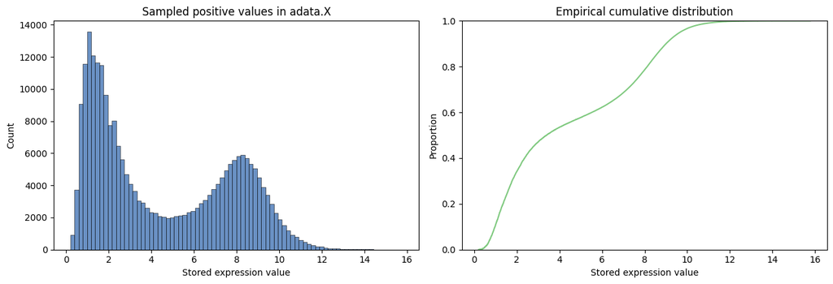

```python
X_nonzero = X_dense[X_dense != 0]

matrix_audit = pd.Series({
    "matrix type": type(X).__name__,
    "dtype": str(X_dense.dtype),
    "minimum": float(X_dense.min()),
    "maximum": float(X_dense.max()),
    "negative entries": int((X_dense < 0).sum()),
    "zero fraction": float((X_dense == 0).mean()),
    "fraction non-integer among positive values": float(
        np.mean(np.abs(X_nonzero - np.rint(X_nonzero)) > 1e-8)
    ),
    "adata.raw available": adata_full.raw is not None,
    "layers available": len(adata_full.layers),
    "log1p metadata available": "log1p" in adata_full.uns,
    "MT-* genes available": int(family_masks["mitochondrial"].sum()),
})
display(matrix_audit.to_frame("value"))

rng = np.random.default_rng(SEED)
sampled_values = rng.choice(X_nonzero, size=min(250_000, X_nonzero.size), replace=False)

fig, axes = plt.subplots(1, 2, figsize=(13, 4.5))
sns.histplot(sampled_values, bins=80, color="#386cb0", ax=axes[0])
axes[0].set_title("Sampled positive values in adata.X")
axes[0].set_xlabel("Stored expression value")

sns.ecdfplot(sampled_values, color="#7fc97f", ax=axes[1])
axes[1].set_title("Empirical cumulative distribution")
axes[1].set_xlabel("Stored expression value")

plt.tight_layout()
plt.show()
```

Three rows settle whether this could be raw count data. `fraction non-integer among positive values` is **1.0**. Not mostly: every positive entry in the matrix is a non-integer, and real UMI counts cannot produce that. `negative entries` is 0, consistent with a transform of the form `log(1 + y)` for non-negative `y`. And all four escape-hatch checks come back empty: no `adata.raw`, no extra layers, no declared `log1p` metadata, and zero mitochondrial genes. Nothing in the file recovers what the values looked like beforehand, which is why the reversal test in the next cells is necessary and not optional.

The histogram is worth reading carefully, because its shape is not a simple bell curve. It is visibly **bimodal**, with a sharper peak around 1-2 and a broader hump around 7-9, separated by a shallow dip near 4-5. This connects directly to what section 5.4 found about individual genes, where the detection-rate histogram was itself split between genes rarely detected and genes detected in almost every cell. Pooling every positive entry across all genes and cells mixes those two populations into one plot: the low hump is dominated by weakly and inconsistently detected genes, the high hump by genes expressed broadly and strongly. The cumulative distribution on the right shows the same structure, rising steeply to roughly 50% of the mass by a value of about 4, flattening, then climbing again toward the second hump, a two-stage climb instead of the single S-curve a unimodal distribution would give.

A more specific check asks whether a candidate logarithm can be reversed. If a cell's count-like values were multiplied by a cell-specific factor and then transformed as

$$ x=\log_b(1+y), $$

the inverse $y=b^x-1$ should recover values that are close to integer multiples of a smallest positive unit within that cell. We compare natural-log, base-2, and base-10 hypotheses. This diagnostic can identify a compatible base, but it cannot recover undocumented upstream laboratory or normalisation details.

```python
def lattice_summary(matrix, base, tolerance=1e-6):
    close_entries = 0
    total_entries = 0
    row_fractions = []
    units = []
    inverse_row_sums = []

    for row in matrix:
        positive = row[row > 0]
        if base == "e":
            inverted = np.expm1(positive)
        elif base == 2:
            inverted = np.exp2(positive) - 1
        else:
            inverted = np.power(10.0, positive) - 1
        unit = inverted.min()
        ratios = inverted / unit
        close = np.isclose(ratios, np.rint(ratios), rtol=tolerance, atol=tolerance)
        close_entries += close.sum()
        total_entries += close.size
        row_fractions.append(close.mean())
        units.append(unit)
        inverse_row_sums.append(inverted.sum())

    return {
        "base": str(base),
        "global integer-lattice fraction": close_entries / total_entries,
        "median per-cell lattice fraction": float(np.median(row_fractions)),
        "median smallest inverse unit": float(np.median(units)),
        "median inverse row sum": float(np.median(inverse_row_sums)),
    }


lattice_table = pd.DataFrame([
    lattice_summary(X_dense, base) for base in ["e", 2, 10]
]).set_index("base")
display(lattice_table)

base2_fraction = lattice_table.loc["2", "global integer-lattice fraction"]
base2_inverse_row_sums = np.array([
    (np.exp2(row[row > 0]) - 1).sum() for row in X_dense
])
```

| base | global integer-lattice fraction | median per-cell lattice fraction | median smallest inverse unit | median inverse row sum |
| --- | --- | --- | --- | --- |
| e | 0.253923 | 0.254757 | 2.082242 | 8.713033e+06 |
| 2 | 1.000000 | 1.000000 | 1.182009 | 4.167320e+05 |
| 10 | 0.599748 | 0.608808 | 12.355406 | 6.467660e+13 |

The three candidate bases produce clearly different results. Under natural log, 25.4% of positive values fall on their cell's integer lattice. Under base 10, the fraction is 60.0% globally (60.9% by the per-cell median), and reversing the transform implies a median total of approximately 6.5 × 10¹³ per cell, a value with no plausible interpretation as a biological count. Under base 2, both lattice fractions reach 100.0%, globally and at the per-cell median: every positive value falls on a whole-number-multiple lattice once inverted under this base. The median of the reconstructed per-cell sums is 416,732, but these sums vary substantially between cells. That number is therefore a descriptive median, not an identified normalisation target.

The exact lattice match provides strong evidence for a base-2 logarithmic transformation of scaled count-like values. It does not uniquely reconstruct the upstream normalisation procedure, because the original counts and per-cell scaling factors are unavailable. Combined with the absence of negative values, raw counts, layers, and transformation metadata, the safest conclusion is that the supplied matrix is already transformed and should not be normalised or logged again without stronger provenance information.

# 7. Preprocessing Justified by the Observed Data

## 7.1 Why Normalisation, Logarithms, and Scaling Are Different

These operations solve different problems and act along different axes:

| Operation | Applied along | Main purpose |
| --- | --- | --- |
| Library-size normalisation | within each cell/row | make cells with different sampling depth comparable |
| Log transformation | each matrix entry | compress the dynamic range and reduce right skew |
| Z-scaling | within each gene/column | give selected genes comparable weight in PCA and distance calculations |

Each addresses a distinct source of variation. Library-size normalisation corrects for two cells sequenced to different depths showing proportionally different counts for most genes, a technical consequence of capture depth independent of biology. Log transformation addresses the right-skewed distribution of raw counts, where a few genes reach large values while most stay low; without it, a distance- or variance-based method would be disproportionately influenced by those few. Z-scaling addresses genes still differing substantially in mean and spread after the log; without it, a high-variance gene would influence PCA in proportion to its scale and not to its biological relevance.

A target such as 10,000 in library-size normalisation is a conventional unit, not the number of genes and not a biological requirement. Section 6 found strong evidence for a base-2 transformation of scaled count-like values, but the varying reconstructed per-cell sums do not identify a single upstream normalisation target. Because raw counts and transformation metadata are unavailable, the existing scale is preserved rather than imposing a second, unverifiable normalisation and logarithm that could distort the supplied expression relationships.

Z-scaling is still needed later, but after highly variable gene selection rather than at this stage. HVG selection compares each gene's variance against genes of similar mean expression, and z-scaling equalises variance across all genes by construction, removing the very signal that comparison relies on. It is therefore applied only to an explicit analysis copy after feature selection, leaving the complete unscaled matrix available for marker and differential-expression interpretation.

## 7.2 Highly Variable Genes

Not every measured gene is equally informative for relationships between cells. Housekeeping genes may be abundant but relatively stable, while lineage and state programmes vary across the population. This is the same mean-variance pattern already observed in section 5.4, where genes expressed at a saturating, near-universal level showed comparatively low variance relative to genes expressed at moderate levels. HVG selection formalises this observation: it compares each gene's variability with genes of similar mean expression and retains features with unusually high dispersion, instead of ranking genes by raw variance alone.

The `seurat_v3` flavour models this mean-variance relationship under the assumption of raw, Poisson-like count data, which are not available here. We therefore use Scanpy's `seurat` flavour, designed for log-transformed input. Because the supplied transformation uses base 2 and lacks metadata, the base is recorded on a temporary copy so Scanpy can reverse it correctly when estimating mean and dispersion. This metadata assignment does **not** transform `X` again.

Instead of choosing 2,000 genes by convention, we examine several candidate set sizes and select the smallest one that captures a specified share of the total signal, so the final count reflects a property of this dataset and not a default carried over from elsewhere. The selected size is the smallest candidate capturing at least 95% of the total positive normalised-dispersion signal in the ranked genes. Labels are not used.

```python
adata_hvg_source = adata_full.copy()
adata_hvg_source.uns["log1p"] = {"base": 2}

sc.pp.highly_variable_genes(
    adata_hvg_source,
    flavor="seurat",
    n_top_genes=adata_hvg_source.n_vars,
    n_bins=20,
    inplace=True,
)

hvg_table = adata_hvg_source.var[[
    "means", "dispersions", "dispersions_norm"
]].copy()
hvg_table["symbol"] = adata_hvg_source.var["Symbol"].astype(str)
hvg_table["rank"] = hvg_table["dispersions_norm"].rank(
    method="first", ascending=False
)

candidate_hvg_counts = [250, 500, 750, 1000, 1250, 1500, 2000]
ranked_index = hvg_table["dispersions_norm"].sort_values(ascending=False).index
positive_dispersion = hvg_table["dispersions_norm"].clip(lower=0)
total_positive_dispersion = positive_dispersion.sum()

sensitivity_rows = []
for n_genes in candidate_hvg_counts:
    selected_index = ranked_index[:n_genes]
    sensitivity_rows.append({
        "n_hvg": n_genes,
        "minimum_normalised_dispersion": hvg_table.loc[
            selected_index, "dispersions_norm"
        ].min(),
        "share_of_positive_dispersion": (
            positive_dispersion.loc[selected_index].sum() / total_positive_dispersion
        ),
    })

hvg_sensitivity = pd.DataFrame(sensitivity_rows)
display(hvg_sensitivity)

eligible_counts = hvg_sensitivity.loc[
    hvg_sensitivity["share_of_positive_dispersion"] >= 0.95, "n_hvg"
]
N_HVG = int(eligible_counts.min())
selected_hvg_index = ranked_index[:N_HVG]
hvg_table["selected"] = hvg_table.index.isin(selected_hvg_index)

print(f"Data-driven HVG choice: {N_HVG} genes")
```

|  | n_hvg | minimum_normalised_dispersion | share_of_positive_dispersion |
| --- | --- | --- | --- |
| 0 | 250 | 1.425132 | 0.559262 |
| 1 | 500 | 0.769414 | 0.763333 |
| 2 | 750 | 0.494542 | 0.886098 |
| 3 | 1000 | 0.259619 | 0.957094 |
| 4 | 1250 | 0.099756 | 0.991798 |
| 5 | 1500 | -0.010567 | 1.000000 |
| 6 | 2000 | -0.196845 | 1.000000 |

```
Data-driven HVG choice: 1000 genes
```

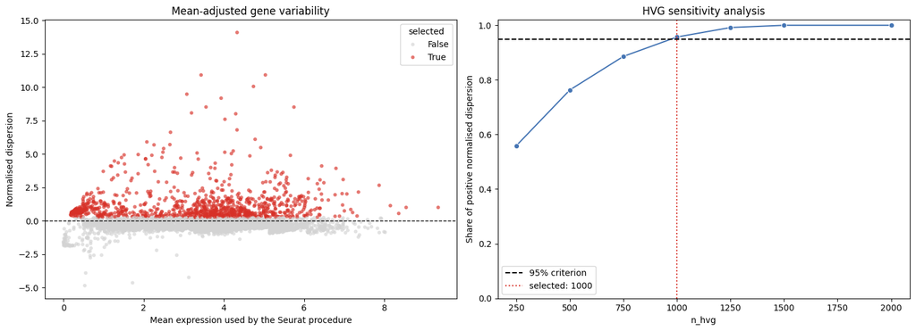

```python
fig, axes = plt.subplots(1, 2, figsize=(15, 5.5))

sns.scatterplot(
    data=hvg_table,
    x="means", y="dispersions_norm", hue="selected",
    palette={False: "lightgray", True: "#d73027"},
    alpha=0.65, s=18, linewidth=0, ax=axes[0],
)
axes[0].axhline(0, color="black", linestyle="--", linewidth=1)
axes[0].set_title("Mean-adjusted gene variability")
axes[0].set_xlabel("Mean expression used by the Seurat procedure")
axes[0].set_ylabel("Normalised dispersion")

sns.lineplot(
    data=hvg_sensitivity, x="n_hvg", y="share_of_positive_dispersion",
    marker="o", color="#4575b4", ax=axes[1],
)
axes[1].axhline(0.95, color="black", linestyle="--", label="95% criterion")
axes[1].axvline(N_HVG, color="#d73027", linestyle=":", label=f"selected: {N_HVG}")
axes[1].set_ylim(0, 1.02)
axes[1].set_title("HVG sensitivity analysis")
axes[1].set_ylabel("Share of positive normalised dispersion")
axes[1].legend()

plt.tight_layout()
plt.show()
```

Each point in the left panel represents one of the 4,290 genes, plotted by mean expression (on the scale used internally by the Seurat procedure) against normalised dispersion, which is variance corrected for expression level and the same metric that addresses the mean-variance confound identified in section 5.4. Selected genes (red) are not concentrated in any single region of the mean-expression axis: highly variable genes are found at low, intermediate, and high expression levels alike, indicating that the procedure is not simply selecting the most highly expressed genes. Nearly all selected points sit above the dashed line at zero, reflecting positive normalised dispersion, that is, greater variability than expected for their expression level. The single most extreme point, with a normalised dispersion of approximately 14.1, corresponds to `S100a9`.

The right panel shows, for each candidate gene-set size, the share of total positive dispersion signal captured. The curve rises steeply at first (0.559 at 250 genes, 0.763 at 500, 0.886 at 750) and flattens sharply beyond 1,000 genes (0.957 at 1,000, just past the 0.95 selection threshold; 0.992 at 1,250; 1.000 at 1,500 and 2,000). Doubling the gene count from 1,000 to 2,000 adds only a further 4 percentage points of captured signal, a clear diminishing-returns pattern that supports selecting fewer genes than the 2,000-gene convention commonly used without this kind of justification.

```python
print("Top 20 HVGs by normalised dispersion")
display(
    hvg_table.sort_values("dispersions_norm", ascending=False)
    .head(20)[["symbol", "means", "dispersions_norm", "rank"]]
)
```

```
Top 20 HVGs by normalised dispersion
```

|  | symbol | means | dispersions_norm | rank |
| --- | --- | --- | --- | --- |
| 844 | S100a9 | 4.331788 | 14.089215 | 1.0 |
| 3725 | Prg2 | 5.036649 | 10.913820 | 2.0 |
| 394 | Igll1 | 3.433909 | 10.908654 | 3.0 |
| 781 | S100a8 | 4.739456 | 10.052527 | 4.0 |
| 4029 | Ngp | 3.078781 | 9.473527 | 5.0 |
| 2370 | Mcpt8 | 3.933581 | 9.174589 | 6.0 |
| 4004 | H2-Eb1 | 3.557113 | 8.514472 | 7.0 |
| 809 | Mir6236 | 5.748594 | 8.507359 | 8.0 |
| 2664 | Prss34 | 3.195588 | 8.070496 | 9.0 |
| 3986 | H2-Aa | 4.297621 | 8.005021 | 10.0 |
| 3703 | Hba-a1 | 4.028851 | 7.596051 | 11.0 |
| 3088 | Pf4 | 4.329915 | 6.800036 | 12.0 |
| 3536 | Retnlg | 2.671493 | 6.622977 | 13.0 |
| 891 | Cd74 | 4.780881 | 6.097390 | 14.0 |
| 3298 | Ltf | 2.082204 | 5.901435 | 15.0 |
| 816 | Trgc1 | 2.656775 | 5.699956 | 16.0 |
| 3631 | Epx | 2.260831 | 5.681345 | 17.0 |
| 3980 | H2-Ab1 | 4.921053 | 5.479373 | 18.0 |
| 3839 | Lcn2 | 2.500251 | 5.407492 | 19.0 |
| 2030 | Ms4a2 | 4.234920 | 5.225758 | 20.0 |

The table lists the twenty genes with the highest normalised dispersion by symbol, since neither figure above reports gene names. Its purpose is not to justify the choice of 1,000 genes, which the sensitivity analysis already does, but to check what kind of genes drive the most extreme part of the ranking.

The result is informative without being reassuring. Most of the top twenty are not markers of the ten broad target classes but of specific, terminally differentiated immune subtypes: neutrophil granule genes (`S100a8`, `S100a9`, `Ngp`, `Retnlg`, `Ltf`, `Lcn2`), mast cell and basophil genes (`Mcpt8`, `Prss34`, `Ms4a2`), eosinophil genes (`Prg2`, `Epx`), and antigen-presentation genes (`H2-Eb1`, `H2-Aa`, `Cd74`, `H2-Ab1`). Only `Hba-a1` (erythroid, ranked eleventh), `Pf4` (megakaryocytic, twelfth) and `Igll1` (third, one of the immunoglobulin genes counted in section 5.5) correspond to programmes already discussed here.

That is consistent with the sample containing a minority of cells already committed to mature lineages beyond the ten broad progenitor categories, and not with the ten classes being separated primarily by their most variable genes. If so, a meaningful share of the HVG set encodes fine-grained, out-of-scope heterogeneity, while the signal separating the ten target classes may depend more on genes ranked lower in this table. This is a limitation to keep in mind when interpreting downstream results on the HVG-selected representation, not a defect in the selection procedure.

## 7.3 Two Explicit Representations and Gene-Wise Scaling

Two representations are constructed from here onward, kept as separate objects instead of one matrix serving both purposes:

1. `adata_biology`: all genes, unscaled transformed expression, for marker analysis and differential expression;
2. `adata_analysis`: selected HVGs, z-scaled and clipped, for PCA, neighbourhood construction, clustering, the SOM, and predictive representations.

Keeping both avoids a forced trade-off. PCA and distance-based methods need a feature-selected, scaled matrix to behave well, but restricting the matrix to that form would make canonical markers unavailable when they fall outside the HVG set, as ten of the twelve canonical markers do here.

Scaling subtracts each selected gene's mean and divides by its standard deviation, so every gene contributes on a comparable scale regardless of its original variance. Values are then clipped at an absolute z-score of 10, far enough into the tail to affect only a small number of extreme values while preventing them from dominating later distance calculations. Scaling changes the geometry downstream algorithms see; it creates no new biological measurement, and it is applied only to `adata_analysis`, leaving `adata_biology` on its original interpretable scale.

```python
adata_full.var["highly_variable"] = hvg_table["selected"].to_numpy()
adata_full.var["hvg_rank"] = hvg_table["rank"].to_numpy()
adata_full.var["dispersions_norm"] = hvg_table["dispersions_norm"].to_numpy()

adata_biology = adata_full.copy()
adata_analysis = adata_full[:, adata_full.var["highly_variable"]].copy()

adata_analysis.layers["transformed_unscaled"] = adata_analysis.X.copy()

unscaled_hvg_matrix = np.asarray(adata_analysis.X).copy()
sc.pp.scale(adata_analysis, zero_center=True, max_value=10)
scaled_hvg_matrix = np.asarray(adata_analysis.X)

scaling_check = pd.Series({
    "analysis cells": adata_analysis.n_obs,
    "analysis genes": adata_analysis.n_vars,
    "median absolute gene mean before scaling": float(
        np.median(np.abs(unscaled_hvg_matrix.mean(axis=0)))
    ),
    "median absolute gene mean after scaling": float(
        np.median(np.abs(scaled_hvg_matrix.mean(axis=0)))
    ),
    "median gene SD before scaling": float(
        np.median(unscaled_hvg_matrix.std(axis=0, ddof=1))
    ),
    "median gene SD after scaling": float(
        np.median(scaled_hvg_matrix.std(axis=0, ddof=1))
    ),
    "largest scaled value": float(scaled_hvg_matrix.max()),
    "smallest scaled value": float(scaled_hvg_matrix.min()),
})
display(scaling_check.to_frame("value"))
```

```
OMP: Info #276: omp_set_nested routine deprecated, please use omp_set_max_active_levels instead.
```

|  | value |
| --- | --- |
| analysis cells | 1.499000e+03 |
| analysis genes | 1.000000e+03 |
| median absolute gene mean before scaling | 1.540321e+00 |
| median absolute gene mean after scaling | 7.730826e-16 |
| median gene SD before scaling | 2.417825e+00 |
| median gene SD after scaling | 1.000000e+00 |
| largest scaled value | 1.000000e+01 |
| smallest scaled value | -6.221927e+00 |

Here we build the two representations and verify the scaling step numerically. HVG results are attached to `adata_full.var`. `adata_biology` is a full copy on the original transformed scale. `adata_analysis` is restricted to the 1,000 selected HVGs; its pre-scaling values are preserved in the `transformed_unscaled` layer before `sc.pp.scale` replaces them in place with per-gene z-scores, clipped at an absolute value of 10. `scaling_check` compares gene means and standard deviations before and after, plus the extreme scaled values, to confirm the operation behaved as expected.

Each expected property is confirmed: median absolute gene mean falls from 1.540 to 7.7 × 10⁻¹⁶ (numerically zero), and median gene standard deviation moves from 2.418 to exactly 1.000. The largest scaled value is exactly 10.0 (clipping reached), the smallest is −6.22 (clipping not reached). This asymmetry is structural, not an error: expression values cannot fall below zero, which bounds how far below the mean a gene's z-score can go, while the upper tail is unbounded in the same way and more likely to be clipped.

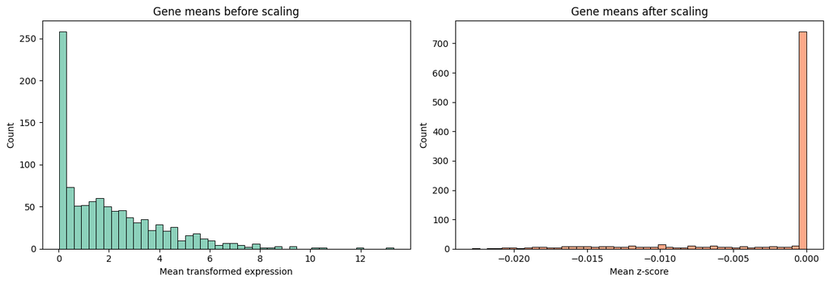

```python
fig, axes = plt.subplots(1, 2, figsize=(13, 4.5))

sns.histplot(
    unscaled_hvg_matrix.mean(axis=0), bins=45, color="#66c2a5", ax=axes[0],
)
axes[0].set_title("Gene means before scaling")
axes[0].set_xlabel("Mean transformed expression")

sns.histplot(
    scaled_hvg_matrix.mean(axis=0), bins=45, color="#fc8d62", ax=axes[1],
)
axes[1].set_title("Gene means after scaling")
axes[1].set_xlabel("Mean z-score")

plt.tight_layout()
plt.show()
```

The graphs visualise the same before-and-after comparison as histograms of gene means, instead of the single summary table above.

Before scaling, gene means are heavily right-skewed, from near zero out to about 13, consistent with section 5.4. After scaling, all 1,000 means collapse into a single narrow spike at zero, on an axis spanning barely 0.025 units. This is the expected effect of per-gene centring, but it shows concretely how differently scaled the genes were beforehand, and why unscaled features would have misled any method that treats scale as comparable across genes.

# 8. Preprocessing Decisions

Sections 6 and 7 established the evidence for each preprocessing choice. This section states the decisions themselves in one place, without repeating that evidence.

- Low-quality cells were not removed: no raw counts or mitochondrial genes are available to support standard QC thresholds, and no separated low-content population was found. All 1,499 cells were retained.
- Rarely detected genes were not removed: no gene is detected in fewer than three cells, and none has zero variance. All 4,290 genes were retained in `adata_biology`.
- Library-size normalisation was not applied: the matrix was already found to be cell-normalised, and raw counts are unavailable.
- A logarithm was not applied: the base-2 log-transformed state was established by the reversal test in section 6.
- Informative features were selected: 1,000 genes capture at least 95% of the positive normalised dispersion signal, selected without reference to the labels.
- Genes were scaled for geometric methods: the 1,000 selected genes were z-scaled and clipped at |z| = 10, only after feature selection, for the reasons in section 7.1.

The data and annotations are internally consistent. The known subset is strongly imbalanced, but annotated and unannotated cells occupy comparable global expression domains, and the canonical marker programmes in section 5.7 support the broad hematopoietic annotations while showing the overlap expected among differentiating progenitors. The conclusion carried forward is that `adata.X` is already normalised and base-2 log-transformed, so a second normalisation or logarithm would be an unjustified distortion, and no cell is removed using thresholds this dataset cannot support.

Two representations are now available: `adata_biology` (1,499 cells × 4,290 genes, unscaled transformed expression, for biological interpretation) and `adata_analysis` (1,499 cells × 1,000 HVGs, z-scaled, for PCA and other geometric methods, with the unscaled HVG values kept in a layer).

## From Preprocessing to Modelling

The preprocessing produced two objects: `adata_biology`, with all 4,290 genes on the supplied expression scale, and `adata_analysis`, with 1,000 scaled highly variable genes. The first is used for biological interpretation and the second for PCA and models based on distances.

The remaining analysis follows this order:

1. **PCA** compresses the scaled HVG space and exposes dominant linear directions;
2. a **nearest-neighbour graph**, **UMAP**, and **t-SNE** describe local expression geometry;
3. **K-means**, **Leiden**, and a **Self-Organizing Map** discover structure without labels;
4. differential expression and canonical markers support cautious biological interpretation;
5. **PCA, an autoencoder, and a denoising autoencoder** are compared as representations;
6. supervised models are evaluated only on annotated cells and the selected pipeline is finally refitted to predict the 425 unannotated cells.

`cell_type` and `class_code` are not used to fit PCA, embeddings, clustering or the SOM. They are added afterwards to interpret the results.

### Scope

The notebook includes PCA, t-SNE, UMAP, clustering, information-theoretic metrics, SOMs, neural networks, autoencoders and denoising autoencoders. Logistic regression, SVM, Random Forest and XGBoost are used as supervised comparisons. CNNs and RNNs are not included because the rows are neither images nor sequences; agent-based and evolutionary methods address different types of questions.

# 9. Principal Component Analysis

## 9.1 Why a Linear Representation Is Needed

A cell is initially represented by thousands of gene-expression coordinates. Direct Euclidean distances in such a space are noisy, computationally expensive, and affected by the concentration-of-distances phenomenon. HVG selection has already removed many weakly informative genes, but it has **not** created combinations of genes or removed correlation among them.

PCA addresses a different question. Given the centred data matrix $X$, it finds orthonormal directions $v_j$ that successively maximise projected variance:

$$ v_1=\arg\max_{\lVert v\rVert=1}\operatorname{Var}(Xv),\qquad v_j=\arg\max_{\lVert v\rVert=1,\,v\perp v_1,\ldots,v_{j-1}}\operatorname{Var}(Xv). $$

The **scores** $Z=XV$ are the coordinates of cells in the new space. The **loadings** in $V$ describe how strongly each gene contributes to a component. Their signs define opposite directions on an arbitrary axis; flipping the sign of an entire PC changes no result.

Gene-wise scaling precedes PCA because otherwise genes with larger numerical variance would dominate the covariance matrix simply because of scale. PCA is useful here as a reproducible linear compression and partial denoising step. It does not prove that the visible directions are cell types, and a modest explained-variance percentage is not a failure in a heterogeneous, noisy transcriptomic dataset.

## 9.2 Fitting PCA and Selecting a Working Dimension

We first fit 50 components, far fewer than the 1,000 HVGs but enough to inspect a plausible range. The working dimension is chosen without labels using three pieces of evidence:

- the scree curve and cumulative explained variance;
- a small set of candidate dimensions (10, 20, 30, 40, 50);
- stability of each cell's 15-nearest-neighbour set relative to the 50-PC reference.

For two neighbour sets $N_a(i)$ and $N_b(i)$, the overlap is $|N_a(i)\cap N_b(i)|/15$. We select the smallest candidate with mean overlap at least 0.80. The threshold balances dimensionality reduction with preservation of local neighbours; the known cell-type labels are not used in this choice.

```python
X_hvg_scaled = np.asarray(adata_analysis.X, dtype=np.float32)
X_hvg_unscaled = np.asarray(
    adata_analysis.layers["transformed_unscaled"], dtype=np.float32
)

MAX_PCS = 50
pca_global = PCA(n_components=MAX_PCS, svd_solver="full")
X_pca_50 = pca_global.fit_transform(X_hvg_scaled)

explained = pca_global.explained_variance_ratio_
cumulative = np.cumsum(explained)

def neighbour_indices(X, n_neighbors=15):
    model = NearestNeighbors(n_neighbors=n_neighbors + 1, metric="euclidean")
    indices = model.fit(X).kneighbors(X, return_distance=False)
    return indices[:, 1:]

def mean_neighbour_overlap(reference, candidate):
    return float(np.mean([
        len(set(a).intersection(b)) / len(a)
        for a, b in zip(reference, candidate)
    ]))

pc_candidates = [10, 20, 30, 40, 50]
reference_knn = neighbour_indices(X_pca_50, n_neighbors=15)
pc_stability_rows = []

for n_pc in pc_candidates:
    candidate_knn = neighbour_indices(X_pca_50[:, :n_pc], n_neighbors=15)
    pc_stability_rows.append({
        "n_pcs": n_pc,
        "cumulative_variance": cumulative[n_pc - 1],
        "mean_15NN_overlap_vs_50PC": mean_neighbour_overlap(
            reference_knn, candidate_knn
        ),
    })

pc_stability = pd.DataFrame(pc_stability_rows)
eligible_pc = pc_stability.loc[
    pc_stability["mean_15NN_overlap_vs_50PC"] >= 0.80, "n_pcs"
]
N_PCS = int(eligible_pc.min()) if len(eligible_pc) else MAX_PCS
X_pca = X_pca_50[:, :N_PCS]

adata_analysis.obsm["X_pca"] = X_pca_50
adata_analysis.uns["pca"] = {
    "variance": pca_global.explained_variance_,
    "variance_ratio": explained,
    "params": {"zero_center": True, "use_highly_variable": True},
}
adata_analysis.varm["PCs"] = pca_global.components_.T

display(pc_stability.style.format({
    "cumulative_variance": "{:.1%}",
    "mean_15NN_overlap_vs_50PC": "{:.3f}",
}))
print(f"Selected working dimension: {N_PCS} PCs")
```

|  | n_pcs | cumulative_variance | mean_15NN_overlap_vs_50PC |
| --- | --- | --- | --- |
| 0 | 10 | 25.0% | 0.445 |
| 1 | 20 | 29.8% | 0.573 |
| 2 | 30 | 32.9% | 0.668 |
| 3 | 40 | 35.5% | 0.775 |
| 4 | 50 | 38.0% | 1.000 |

```
Selected working dimension: 50 PCs
```

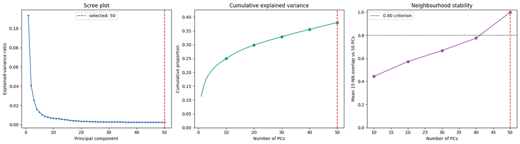

```python
fig, axes = plt.subplots(1, 3, figsize=(17, 4.8))
components = np.arange(1, MAX_PCS + 1)

axes[0].plot(components, explained, marker="o", markersize=3, color="#4575b4")
axes[0].axvline(N_PCS, linestyle="--", color="#d73027", label=f"selected: {N_PCS}")
axes[0].set_title("Scree plot")
axes[0].set_xlabel("Principal component")
axes[0].set_ylabel("Explained-variance ratio")
axes[0].legend()

axes[1].plot(components, cumulative, color="#1b9e77")
axes[1].scatter(pc_candidates, cumulative[np.array(pc_candidates) - 1], color="#1b9e77")
axes[1].axvline(N_PCS, linestyle="--", color="#d73027")
axes[1].set_title("Cumulative explained variance")
axes[1].set_xlabel("Number of PCs")
axes[1].set_ylabel("Cumulative proportion")
axes[1].set_ylim(0, min(1.0, cumulative[-1] * 1.12))

axes[2].plot(
    pc_stability["n_pcs"],
    pc_stability["mean_15NN_overlap_vs_50PC"],
    marker="o", color="#984ea3",
)
axes[2].axhline(0.80, linestyle=":", color="black", label="0.80 criterion")
axes[2].axvline(N_PCS, linestyle="--", color="#d73027")
axes[2].set_title("Neighbourhood stability")
axes[2].set_xlabel("Number of PCs")
axes[2].set_ylabel("Mean 15-NN overlap vs 50 PCs")
axes[2].set_ylim(0, 1.02)
axes[2].legend()

plt.tight_layout()
plt.show()
```

The table and the first two panels summarise the fitted 50-component PCA from three angles: the scree plot gives each component's explained-variance ratio, the cumulative plot the running total, and the table reports both alongside the neighbourhood-stability criterion at each candidate dimension. The third panel plots those stability values with the 0.80 threshold and the selected dimension marked. The two scatterplots then show the same PC1-PC2 projection twice: coloured by annotation status, to check that unannotated cells occupy the same region of the space, and with the ten cell-type labels overlaid, strictly after the fact and never used in fitting.

The scree plot drops sharply after the first two or three components, then trails off across the remaining 50 with no distinct elbow. The cumulative plot agrees: even at 50 components only 38.0% of total variance is explained (25.0% at 10, rising to 38.0% at 50). The neighbourhood-stability criterion gives the more consequential result. Mean 15-nearest-neighbour overlap against the 50-PC reference rises steadily but slowly (0.445 at 10 components, 0.573 at 20, 0.668 at 30, 0.775 at 40) and never reaches the 0.80 threshold below the reference itself, so the procedure retains all 50 components. This is a legitimate application of the stated rule rather than a failure of it, but it does mean the working representation achieves no reduction relative to the 50-component fit, a direct consequence of variance spread thinly across many components instead of concentrated in a few.

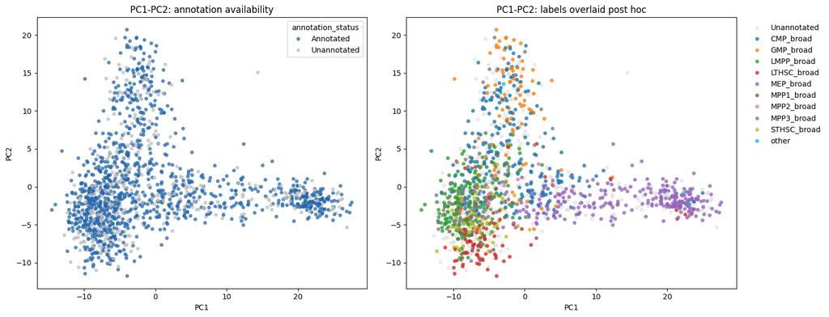

```python
pca_plot = pd.DataFrame({
    "PC1": X_pca_50[:, 0],
    "PC2": X_pca_50[:, 1],
    "annotation_status": adata_analysis.obs["annotation_status"].astype(str).to_numpy(),
    "cell_type": adata_analysis.obs["cell_type"].astype(object).to_numpy(),
})

fig, axes = plt.subplots(1, 2, figsize=(15.5, 6))
sns.scatterplot(
    data=pca_plot, x="PC1", y="PC2", hue="annotation_status",
    hue_order=["Annotated", "Unannotated"],
    palette={"Annotated": "#2166ac", "Unannotated": "#bdbdbd"},
    s=24, alpha=0.75, linewidth=0, ax=axes[0],
)
axes[0].set_title("PC1-PC2: annotation availability")

axes[1].scatter(
    pca_plot.loc[pca_plot["annotation_status"].eq("Unannotated"), "PC1"],
    pca_plot.loc[pca_plot["annotation_status"].eq("Unannotated"), "PC2"],
    color="#d9d9d9", s=18, alpha=0.45, label="Unannotated",
)
sns.scatterplot(
    data=pca_plot.loc[pca_plot["annotation_status"].eq("Annotated")],
    x="PC1", y="PC2", hue="cell_type", hue_order=label_order,
    palette="tab10", s=25, alpha=0.8, linewidth=0, ax=axes[1],
)
axes[1].set_title("PC1-PC2: labels overlaid post hoc")
axes[1].legend(bbox_to_anchor=(1.02, 1), loc="upper left", frameon=False)

plt.tight_layout()
plt.show()
```

The PC1-PC2 scatterplots show two things. First, annotated and unannotated cells occupy the same regions of the plot with no visible separation, consistent with the label-free comparisons already carried out in earlier sections. Second, once the labels are overlaid, `MEP_broad` (purple) forms a distinct, elongated arm extending to high PC1 values, separated from the remaining classes, while `CMP_broad` and `GMP_broad` concentrate toward high PC2 and `LTHSC_broad`/`STHSC_broad` concentrate toward low PC2, with `LMPP_broad`, `MPP1_broad`, `MPP2_broad`, and `MPP3_broad` overlapping heavily in a dense central region instead of forming their own separated groups. This is consistent with the continuum interpretation used throughout the notebook: PC1 and PC2 separate the most transcriptionally distinct programme (erythroid/megakaryocytic) and a broad myeloid-versus-stem gradient, but do not resolve the more closely related progenitor states from one another. Those remain a question for the neighbour-graph and clustering methods introduced next, which are not limited to two dimensions.

# 10. Nearest-Neighbour Graph, UMAP, and t-SNE

This section builds three related representations from the same 50-PC space: a nearest-neighbour graph, used directly by Leiden in the next section, and two 2D visualisations, UMAP and t-SNE, used only to look at the data. Both are stochastic and neither is used for clustering: section 11 clusters in the original PC space, because compressing 50 dimensions to 2 for the sake of a drawing discards information a clustering algorithm should still have.

Before any label is examined, every embedding here is checked for one thing: whether the 425 cells needing predictions occupy the same region of the layout as the 1,074 labelled cells. This is the check already run on individual metrics in sections 5.3 and 5.6, applied to the geometry of the embeddings themselves. If the unlabelled cells clustered separately, that would suggest they were measured differently or represent a biological state the labelled data does not cover, either of which would undermine the assumption that a model trained on the labelled cells transfers to the rest. The known labels are overlaid only afterwards, and never used to fit any representation below.

## 10.1 Nearest-Neighbour Graph

A k-nearest-neighbour graph represents each cell as a node and connects it to the cells closest to it in the selected PCA space (the `N_PCS` components chosen in section 9). This graph is the shared foundation for everything else in this notebook that depends on local structure instead of global coordinates: UMAP and t-SNE both start from measuring similarity between neighbours, and Leiden in section 11 uses this same graph directly instead of rebuilding it. The Self-Organizing Map in section 11.5 is the exception: it is trained on the `N_PCS`-dimensional PCA coordinates themselves, rescaled by their global standard deviation, so it reads the same space the graph was built from without consuming the graph.

The graph is built once, on `adata_analysis`, using Euclidean distance and a fixed neighbourhood size of $k=15$. It is built on the full `N_PCS`-dimensional space, not on any 2D projection, because a two-dimensional display necessarily discards information the graph should still capture. No labels are used at this stage.

```python
REFERENCE_NEIGHBORS = 15
sc.pp.neighbors(
    adata_analysis,
    n_neighbors=REFERENCE_NEIGHBORS,
    n_pcs=N_PCS,
    use_rep="X_pca",
    metric="euclidean",
    random_state=SEED,
)

graph_summary = pd.Series({
    "nodes": adata_analysis.n_obs,
    "requested neighbours per cell": REFERENCE_NEIGHBORS,
    "PC dimensions used": N_PCS,
    "non-zero connectivities": int(adata_analysis.obsp["connectivities"].nnz),
    "labels used": "none",
})
display(graph_summary.to_frame("value"))
```

|  | value |
| --- | --- |
| nodes | 1499 |
| requested neighbours per cell | 15 |
| PC dimensions used | 50 |
| non-zero connectivities | 33386 |
| labels used | none |

The neighbour graph connects 1,499 nodes through 33,386 non-zero entries in its connectivity matrix, which is 16,693 undirected edges and an average of roughly 22 neighbour links per cell. That is higher than the requested 15 because the graph is symmetrised: if cell A lists cell B as one of its 15 nearest neighbours but B does not list A, the edge is still kept, so the final degree exceeds the requested neighbourhood size. This is the graph Leiden uses directly in section 11.

## 10.2 UMAP

UMAP treats the data as lying on a manifold and builds a low-dimensional layout that keeps points close on that manifold close together, while letting distant points be pushed further apart than their exact high-dimensional distance would suggest. Its objective is a cross-entropy between two sets of edge weights: $\mu(a)$, the strength assigned to a pair of points $a$ in the high-dimensional graph, and $\nu(a)$, the strength assigned to the same pair in the low-dimensional layout being optimised:

$$ C = \sum_{a \in A} \left( \mu(a)\log\frac{\mu(a)}{\nu(a)} + (1-\mu(a))\log\frac{1-\mu(a)}{1-\nu(a)} \right) $$

The first term is an attractive force: when two points are strongly connected in the high-dimensional graph ($\mu(a)$ large), the cost is minimised only by placing them close in the layout ($\nu(a)$ large). The second is repulsive in the opposite case. Two hyperparameters control the balance: `n_neighbors` sets how many neighbours enter the high-dimensional graph, trading local detail against global consistency, and `min_dist` controls how tightly points may pack in the drawing.

Instead of fixing these two hyperparameters by convention, several combinations are compared using two different measures. The primary criterion is **trustworthiness**: the fraction of each point's nearest neighbours in the low-dimensional embedding that are also true nearest neighbours in the original PCA space, averaged over all points. It measures whether the layout is a faithful local representation of the same 50-PC geometry used everywhere else in the notebook, independent of any clustering algorithm. A **silhouette score** from a K-means partition on each embedding is reported alongside it for comparison only: it quantifies how compact and separated the layout looks, a looser question than whether it is faithful. Selection uses trustworthiness, because a configuration can be tuned to look more separated without being more faithful, and both measures are reported so that distinction is visible in the numbers.

|  | n_neighbors | min_dist | trustworthiness_15NN | silhouette_kmeans10 |
| --- | --- | --- | --- | --- |
| 0 | 10 | 0.100000 | 0.929 | 0.469 |
| 1 | 10 | 0.300000 | 0.922 | 0.446 |
| 2 | 10 | 0.500000 | 0.918 | 0.425 |
| 3 | 15 | 0.100000 | 0.925 | 0.472 |
| 4 | 15 | 0.300000 | 0.921 | 0.449 |
| 5 | 15 | 0.500000 | 0.915 | 0.433 |
| 6 | 30 | 0.100000 | 0.918 | 0.498 |
| 7 | 30 | 0.300000 | 0.911 | 0.437 |
| 8 | 30 | 0.500000 | 0.906 | 0.431 |
| 9 | 50 | 0.100000 | 0.909 | 0.476 |
| 10 | 50 | 0.300000 | 0.905 | 0.452 |
| 11 | 50 | 0.500000 | 0.903 | 0.421 |

```
Selected UMAP configuration (highest trustworthiness): (10, 0.1)
```

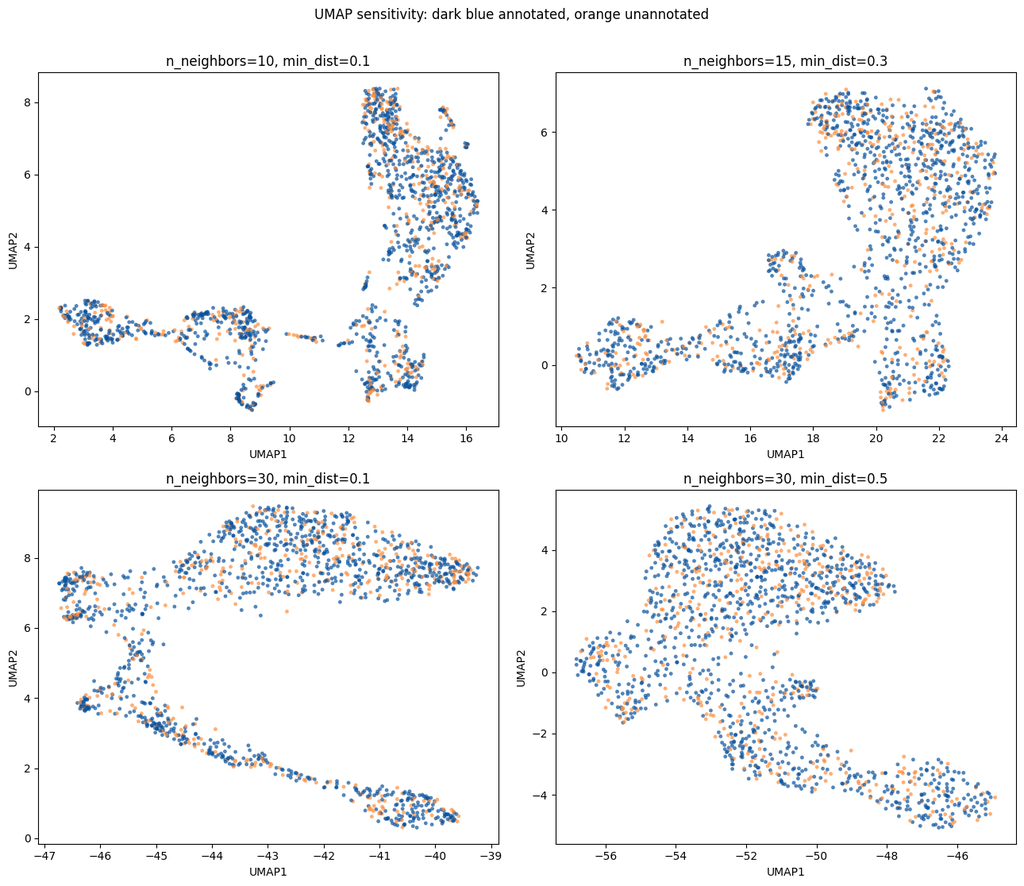

```python
umap_configs = [
    {"n_neighbors": n, "min_dist": d}
    for n in [10, 15, 30, 50]
    for d in [0.1, 0.3, 0.5]
]
umap_embeddings = {}
umap_rows = []

for config in umap_configs:
    key = (config["n_neighbors"], config["min_dist"])
    reducer = umap.UMAP(
        n_components=2,
        metric="euclidean",
        random_state=SEED,
        n_jobs=1,
        **config,
    )
    embedding = reducer.fit_transform(X_pca)
    umap_embeddings[key] = embedding
    silhouette_labels = KMeans(
        n_clusters=10, n_init=10, random_state=SEED
    ).fit_predict(embedding)
    umap_rows.append({
        **config,
        "trustworthiness_15NN": trustworthiness(X_pca, embedding, n_neighbors=15),
        "silhouette_kmeans10": silhouette_score(embedding, silhouette_labels),
    })

umap_sensitivity = pd.DataFrame(umap_rows)
display(umap_sensitivity.style.format({
    "trustworthiness_15NN": "{:.3f}",
    "silhouette_kmeans10": "{:.3f}",
}))

best_umap_row = umap_sensitivity.loc[umap_sensitivity["trustworthiness_15NN"].idxmax()]
REFERENCE_UMAP = (int(best_umap_row["n_neighbors"]), float(best_umap_row["min_dist"]))
print(f"Selected UMAP configuration (highest trustworthiness): {REFERENCE_UMAP}")

ANNOTATED_COLOR = "#08519c"
UNANNOTATED_COLOR = "#fd8d3c"
status_colors = np.where(
    adata_analysis.obs["annotation_status"].astype(str).eq("Annotated"),
    ANNOTATED_COLOR, UNANNOTATED_COLOR,
)

plot_configs = [
    {"n_neighbors": 10, "min_dist": 0.10},
    {"n_neighbors": 15, "min_dist": 0.30},
    {"n_neighbors": 30, "min_dist": 0.10},
    {"n_neighbors": 30, "min_dist": 0.50},
]
fig, axes = plt.subplots(2, 2, figsize=(13, 11))
for ax, config in zip(axes.flat, plot_configs):
    key = (config["n_neighbors"], config["min_dist"])
    emb = umap_embeddings[key]
    ax.scatter(emb[:, 0], emb[:, 1], c=status_colors, s=12, alpha=0.7, linewidth=0)
    ax.set_title(f"n_neighbors={key[0]}, min_dist={key[1]}")
    ax.set_xlabel("UMAP1")
    ax.set_ylabel("UMAP2")
plt.suptitle("UMAP sensitivity: dark blue annotated, orange unannotated", y=1.01)
plt.tight_layout()
plt.show()
```

The widened UMAP grid makes the distinction between the two reported measures concrete. Trustworthiness ranges from 0.903 (`n_neighbors=50, min_dist=0.5`) to 0.929 (`n_neighbors=10, min_dist=0.1`), decreasing steadily as either parameter grows: smaller neighbourhoods and tighter packing stay closer to the original 50-PC geometry. Silhouette tells a different story: its maximum, 0.498, is reached at `n_neighbors=30, min_dist=0.1`, not at the trustworthiness-selected configuration, whose own silhouette is only 0.469. The two criteria agree that a small `min_dist` helps, since tighter packing improves both a faithful layout and a visually compact one, but they disagree on `n_neighbors`, and the configuration finally used (`n_neighbors=10, min_dist=0.1`) is the one selected by trustworthiness, not the one that would have been selected by silhouette. This is the concrete version of the methodological point made above: optimising for apparent separation and optimising for local fidelity are not the same objective, and here they visibly pull in different directions.

In the 2×2 sensitivity plot, annotated (dark blue) and unannotated (orange) cells are mixed throughout all four panels, with no configuration producing a visibly separate region for either group.

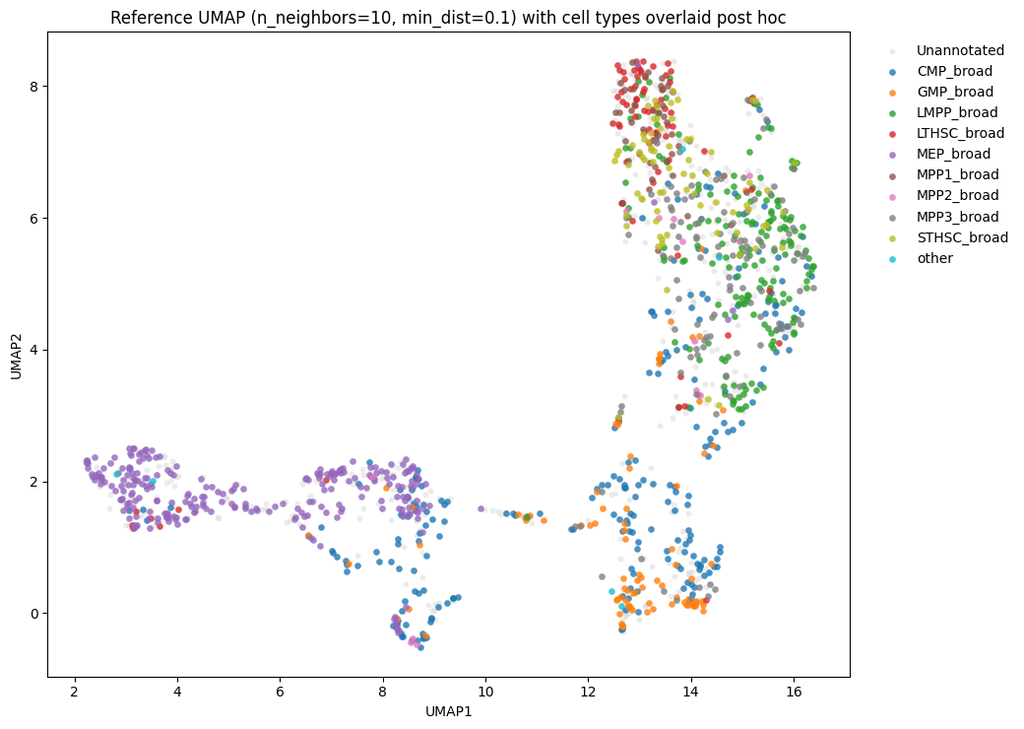

```python
X_umap = umap_embeddings[REFERENCE_UMAP]
adata_analysis.obsm["X_umap"] = X_umap

fig, ax = plt.subplots(figsize=(10.5, 7.5))
unlabeled = ~annotated_mask
ax.scatter(
    X_umap[unlabeled, 0], X_umap[unlabeled, 1],
    c="#d9d9d9", s=18, alpha=0.5, label="Unannotated", linewidth=0,
)
palette = dict(zip(label_order, sns.color_palette("tab10", len(label_order))))
for label in label_order:
    mask = annotated_mask & adata_analysis.obs["cell_type"].astype(object).eq(label).to_numpy()
    ax.scatter(
        X_umap[mask, 0], X_umap[mask, 1],
        s=23, alpha=0.8, color=palette[label], label=label, linewidth=0,
    )
ax.set_title(f"Reference UMAP (n_neighbors={REFERENCE_UMAP[0]}, min_dist={REFERENCE_UMAP[1]}) with cell types overlaid post hoc")
ax.set_xlabel("UMAP1")
ax.set_ylabel("UMAP2")
ax.legend(bbox_to_anchor=(1.02, 1), loc="upper left", frameon=False)
plt.tight_layout()
plt.show()
```

The reference UMAP with cell types overlaid shows one population standing clearly apart: `MEP_broad` forms an isolated island on the left, consistent with its distinct position on PC1 and its unambiguous marker signal in section 5.7. Every other class sits inside one connected, sprawling structure instead of forming its own separated island: `LTHSC_broad` and `STHSC_broad` cluster loosely toward one end, `LMPP_broad` toward another, and `CMP_broad` and `GMP_broad` scatter through the middle. There is visible substructure but no clean boundaries, consistent with the continuum already described from the PCA and marker sections.

## 10.3 t-SNE

t-SNE converts distances into probabilities and matches them across the two spaces. In the original high-dimensional space, the similarity between points $i$ and $j$ is modelled with a Gaussian centred on $i$,

$$ p_{j\mid i} = \frac{\exp\left(-\lVert x_i-x_j\rVert^2 / 2\sigma_i^2\right)}{\sum_{k\neq i}\exp\left(-\lVert x_i-x_k\rVert^2/2\sigma_i^2\right)}, \qquad p_{ij}=\frac{p_{j\mid i}+p_{i\mid j}}{2N}, $$

where the bandwidth $\sigma_i$ of each cell's Gaussian is chosen so that the resulting distribution has a fixed **perplexity**,

$$ \mathrm{Perp}(P_i) = 2^{H(P_i)}, \qquad H(P_i) = -\sum_j p_{j\mid i}\log_2 p_{j\mid i}, $$

which behaves like an effective neighbourhood size: a perplexity of 30 corresponds, loosely, to weighing around 30 neighbours per point.

A low perplexity is a known source of misleading pictures, not a free choice of resolution: with too few effective neighbours, t-SNE can fragment even a continuous manifold into small, visually separated islands that correspond to no real discrete structure. This is a documented failure mode, not a rare edge case (Wattenberg, Viégas & Johnson, 2016, [How to Use t-SNE Effectively](https://distill.pub/2016/misread-tsne/)), and one more reason trustworthiness is used below to select among perplexities.

In the low-dimensional layout, similarity between the same pair of points is instead modelled with a Student-t distribution on one degree of freedom,

$$ q_{ij} = \frac{\left(1+\lVert y_i-y_j\rVert^2\right)^{-1}}{\sum_{k\neq l}\left(1+\lVert y_k-y_l\rVert^2\right)^{-1}}, $$

whose heavier tails let dissimilar points sit further apart than a Gaussian would allow, preventing crowded, unrelated points from being forced together. The layout is optimised by minimising the Kullback-Leibler divergence between the two distributions,

$$ D_{KL}(P\lVert Q) = \sum_{i\neq j} p_{ij}\log\frac{p_{ij}}{q_{ij}}, $$

so that pairs with large $p_{ij}$ (close in the original space) are penalised heavily unless $q_{ij}$ is also large, while pairs with small $p_{ij}$ contribute little to the cost regardless of where they end up. That asymmetry is what makes t-SNE prioritise local structure over global distances.

As with UMAP, several perplexity values are compared on trustworthiness, with a K-means silhouette reported for comparison and not for selection. The final KL divergence is also reported, but it depends on perplexity in a way that is not comparable across settings, so it is read as a per-run convergence diagnostic and not as a fourth selection criterion.

|  | perplexity | trustworthiness_15NN | silhouette_kmeans10 | final_KL_divergence |
| --- | --- | --- | --- | --- |
| 0 | 5 | 0.935 | 0.404 | 1.533 |
| 1 | 15 | 0.947 | 0.431 | 1.425 |
| 2 | 30 | 0.948 | 0.433 | 1.226 |
| 3 | 50 | 0.949 | 0.433 | 1.040 |
| 4 | 75 | 0.950 | 0.437 | 0.881 |

```
Selected t-SNE perplexity (highest trustworthiness): 75
```

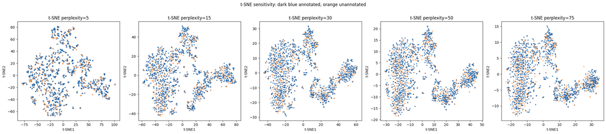

```python
tsne_perplexities = [5, 15, 30, 50, 75]
tsne_embeddings = {}
tsne_rows = []

for perplexity in tsne_perplexities:
    tsne = TSNE(
        n_components=2,
        perplexity=perplexity,
        learning_rate="auto",
        init="pca",
        max_iter=1000,
        random_state=SEED,
    )
    embedding = tsne.fit_transform(X_pca)
    tsne_embeddings[perplexity] = embedding
    silhouette_labels = KMeans(
        n_clusters=10, n_init=10, random_state=SEED
    ).fit_predict(embedding)
    tsne_rows.append({
        "perplexity": perplexity,
        "trustworthiness_15NN": trustworthiness(X_pca, embedding, n_neighbors=15),
        "silhouette_kmeans10": silhouette_score(embedding, silhouette_labels),
        "final_KL_divergence": tsne.kl_divergence_,
    })

tsne_sensitivity = pd.DataFrame(tsne_rows)
display(tsne_sensitivity.style.format({
    "trustworthiness_15NN": "{:.3f}",
    "silhouette_kmeans10": "{:.3f}",
    "final_KL_divergence": "{:.3f}",
}))

REFERENCE_TSNE = int(
    tsne_sensitivity.loc[tsne_sensitivity["trustworthiness_15NN"].idxmax(), "perplexity"]
)
print(f"Selected t-SNE perplexity (highest trustworthiness): {REFERENCE_TSNE}")

fig, axes = plt.subplots(1, 5, figsize=(24, 5.2))
for ax, perplexity in zip(axes, tsne_perplexities):
    emb = tsne_embeddings[perplexity]
    ax.scatter(emb[:, 0], emb[:, 1], c=status_colors, s=11, alpha=0.7, linewidth=0)
    ax.set_title(f"t-SNE perplexity={perplexity}")
    ax.set_xlabel("t-SNE1")
    ax.set_ylabel("t-SNE2")
plt.suptitle("t-SNE sensitivity: dark blue annotated, orange unannotated", y=1.01)
plt.tight_layout()
plt.show()

X_tsne = tsne_embeddings[REFERENCE_TSNE]
adata_analysis.obsm["X_tsne"] = X_tsne
```

The t-SNE grid shows the same pattern from another angle. Trustworthiness rises from 0.935 at perplexity 5 to 0.950 at perplexity 75, but almost all of the gain arrives by perplexity 15 (0.947), and silhouette behaves the same way, climbing from 0.404 to roughly 0.43 by perplexity 15 and barely moving afterward. The final KL divergence falls steadily with perplexity (1.533 to 0.881), the expected behaviour of an easier optimisation problem at a larger effective neighbourhood size and not evidence of a better embedding. Visually, perplexity 5 gives a fragmented, noisy scatter matching its lower scores; from perplexity 15 onward the same structure, one dense body plus a curved tail, reappears at every setting, only tighter, with annotated and unannotated cells mixed throughout.

None of this rules out real cluster structure; it reflects what these layouts are built to do. Both were selected to preserve local neighbourhoods faithfully rather than to look maximally separated, and a manifold continuous in 50 dimensions still looks continuous compressed to two, however the compression is tuned. Whether the ten populations form statistically defensible clusters is answered in the next section, in the full 50-PC space.

# 11. Unsupervised Clustering

Clustering asks whether expression profiles form internally coherent groups **without being told the ten cell types**. A cluster number is an arbitrary identifier and has no relation to the supplied class code. Moreover, a one-to-one match is not required: one biological label may contain substructure, while neighbouring progenitor labels may form a continuum that an unsupervised algorithm merges.

We compare complementary assumptions:

- **K-means** partitions the PCA space into approximately convex groups by minimising within-cluster squared distance, $J=\sum_{k=1}^{K}\sum_{i\in C_k}\lVert z_i-\mu_k\rVert^2$;
- **Leiden** finds communities in the neighbour graph by improving a graph-partition quality function; its `resolution` controls granularity;
- a **Self-Organizing Map** learns a topological grid of prototypes and is examined in section 11.5.

Internal selection uses inertia, silhouette, and stability across random seeds. Labels are opened only afterwards for contingency tables, ARI, NMI, purity, and composition entropy.

## 11.1 K-means: Internally Selected $K$ and the Separate $K=10$ Experiment

K-means minimises $J=\sum_{k=1}^{K}\sum_{i\in C_k}\lVert z_i-\mu_k\rVert^2$ (introduced in the section overview above) by alternating two steps until convergence. First, every cell is assigned to its nearest centroid, $$r_{ik}=\begin{cases}1 & k=\arg\min_l \lVert z_i-\mu_l\rVert^2\\0 & \text{otherwise}\end{cases},$$ then each centroid is recomputed as the mean of the cells currently assigned to it, $$\mu_k=\frac{\sum_i r_{ik}z_i}{\sum_i r_{ik}}.$$ Neither step increases $J$, so the algorithm always converges, though only to a local optimum: different initialisations can land on different solutions, which is what the seed-stability check below catches. K-means is efficient and interpretable but assumes Euclidean, roughly spherical groups of comparable scale, and inertia always decreases as $K$ grows, so an elbow must be read together with silhouette and seed stability.

Silhouette quantifies, for each cell $i$, how much closer it sits to its own cluster than to the nearest other one: $$s(i)=\frac{b(i)-a(i)}{\max\{a(i),b(i)\}},$$ where $a(i)$ is the mean distance from $i$ to the other cells in its own cluster (cohesion) and $b(i)$ the mean distance to the nearest neighbouring cluster (separation). The reported value averages $s(i)$ over all cells, in $[-1,1]$, with values near 1 meaning cells sit comfortably inside well-separated clusters.

The main solution is selected without labels: among the candidate $K$ values whose partition is stable across random seeds, the one with the highest silhouette is kept. A second fit with $K=10$ answers a different, explicitly constrained question: *what happens if the algorithm is forced to produce as many groups as known classes?* It is not presented as the unbiased optimum.

```python
K_RANGE = range(2, 15)
CLUSTER_SEEDS = [11, 42, 73, 101]
kmeans_rows = []
kmeans_labels_by_k = {}

for k in K_RANGE:
    seed_labels = []
    seed_inertias = []
    for seed in CLUSTER_SEEDS:
        model = KMeans(n_clusters=k, n_init=20, random_state=seed)
        labels = model.fit_predict(X_pca)
        seed_labels.append(labels)
        seed_inertias.append(model.inertia_)
    pairwise_stability = [
        adjusted_rand_score(seed_labels[i], seed_labels[j])
        for i, j in combinations(range(len(seed_labels)), 2)
    ]
    reference_labels = seed_labels[CLUSTER_SEEDS.index(SEED)]
    kmeans_labels_by_k[k] = reference_labels
    kmeans_rows.append({
        "k": k,
        "mean_inertia": np.mean(seed_inertias),
        "silhouette": silhouette_score(X_pca, reference_labels),
        "mean_seed_ARI": np.mean(pairwise_stability),
        "sd_seed_ARI": np.std(pairwise_stability),
    })

kmeans_sweep = pd.DataFrame(kmeans_rows)
stable_k = kmeans_sweep.loc[kmeans_sweep["mean_seed_ARI"] >= 0.80]
selection_pool = stable_k if len(stable_k) else kmeans_sweep
BEST_K = int(selection_pool.loc[selection_pool["silhouette"].idxmax(), "k"])

adata_analysis.obs["kmeans_internal"] = pd.Categorical(
    kmeans_labels_by_k[BEST_K].astype(str)
)
adata_analysis.obs["kmeans_k10"] = pd.Categorical(
    kmeans_labels_by_k[10].astype(str)
)

display(kmeans_sweep.style.format({
    "mean_inertia": "{:.1f}",
    "silhouette": "{:.3f}",
    "mean_seed_ARI": "{:.3f}",
    "sd_seed_ARI": "{:.3f}",
}))
print(f"Internally selected K: {BEST_K}")
```

|  | k | mean_inertia | silhouette | mean_seed_ARI | sd_seed_ARI |
| --- | --- | --- | --- | --- | --- |
| 0 | 2 | 395462.1 | 0.273 | 1.000 | 0.000 |
| 1 | 3 | 349696.4 | 0.194 | 0.999 | 0.001 |
| 2 | 4 | 316471.4 | 0.207 | 0.999 | 0.001 |
| 3 | 5 | 297430.9 | 0.184 | 0.991 | 0.008 |
| 4 | 6 | 287679.7 | 0.183 | 0.978 | 0.005 |
| 5 | 7 | 278906.2 | 0.168 | 0.985 | 0.006 |
| 6 | 8 | 271848.2 | 0.162 | 0.843 | 0.056 |
| 7 | 9 | 265670.3 | 0.144 | 0.732 | 0.076 |
| 8 | 10 | 259976.3 | 0.146 | 0.682 | 0.098 |
| 9 | 11 | 254783.1 | 0.140 | 0.671 | 0.073 |
| 10 | 12 | 250576.1 | 0.122 | 0.737 | 0.109 |
| 11 | 13 | 245795.4 | 0.122 | 0.651 | 0.066 |
| 12 | 14 | 242009.9 | 0.144 | 0.690 | 0.066 |

```
Internally selected K: 2
```

Silhouette peaks at **K=2** (0.273) and declines steadily as $K$ grows, with a smaller local rise at K=4 (0.207) before continuing to fall. Seed stability stays close to perfect (mean ARI ≥ 0.978) through K=7, then falls away from K=8 onward, to 0.843 at K=8 and as low as 0.651 at K=13. Beyond roughly seven groups, different random initialisations start finding substantially different partitions of the same data, so no specific finer solution is a reliable property of the data itself. Inertia decreases monotonically across the whole range, as it must by construction, and shows no clear elbow, consistent with the continuum already observed in the PCA and UMAP sections and not with a small number of tight, well-separated groups. Because K=2 is both stable and has the highest silhouette in the entire sweep, it is the internally selected solution.

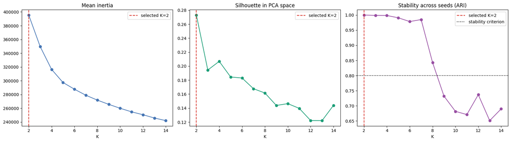

```python
fig, axes = plt.subplots(1, 3, figsize=(17, 4.8))
plot_specs = [
    ("mean_inertia", "Mean inertia", "#4575b4"),
    ("silhouette", "Silhouette in PCA space", "#1b9e77"),
    ("mean_seed_ARI", "Stability across seeds (ARI)", "#984ea3"),
]
for ax, (column, title, color) in zip(axes, plot_specs):
    ax.plot(kmeans_sweep["k"], kmeans_sweep[column], marker="o", color=color)
    ax.axvline(BEST_K, color="#d73027", linestyle="--", label=f"selected K={BEST_K}")
    if column == "mean_seed_ARI":
        ax.axhline(0.80, color="black", linestyle=":", label="stability criterion")
    ax.set_xlabel("K")
    ax.set_title(title)
    ax.legend()
plt.tight_layout()
plt.show()
```

The three panels show why K=2 is selected without contradiction between criteria. The inertia curve falls smoothly with no kink to suggest a natural stopping point on its own. The silhouette curve has its single highest point at K=2, dropping and staying below 0.21 for every larger K tested. The stability curve sits far above the 0.80 threshold (dashed line) through K=7, is still above it at K=8 (0.843), and then drops below and stays below from K=9 onward, never recovering the threshold at any larger K tested. The vertical dashed line marking the selected K=2 sits at the peak of both the silhouette curve and the stable region of the ARI curve, which is why the label-free selection converges there instead of resting on an arbitrary tie-break.

## 11.2 Leiden Communities on the Neighbour Graph

K-means partitions every point using distances to centroids. Leiden instead uses the pattern of local graph connections in the neighbour graph built in section 10.1, making it suitable for irregular communities that do not fit the roughly spherical shape K-means assumes. Leiden searches for a partition into communities that maximises a resolution-weighted modularity, $$Q_\gamma=\frac{1}{2m}\sum_{i,j}\left(A_{ij}-\gamma\frac{k_ik_j}{2m}\right)\delta(c_i,c_j),$$ where $A_{ij}$ is the neighbour-graph edge weight between cells $i$ and $j$, $k_i$ is the total edge weight touching cell $i$, $m$ is the total edge weight in the graph, and $\delta(c_i,c_j)$ is 1 when $i$ and $j$ are placed in the same community and 0 otherwise. The subtracted term is the edge weight expected between $i$ and $j$ under a random graph with the same degree sequence, so $Q_\gamma$ rewards communities whose internal connectivity exceeds that baseline. The `resolution` parameter $\gamma$ scales the baseline, which is why higher values generally split the graph into more, smaller communities. There is no universal resolution, and ten communities are not imposed.

We test six resolutions and three random seeds. For each resolution we record the number of communities, silhouette in the PCA space, and pairwise ARI between seeds. Silhouette is not the Leiden objective, and Leiden never sees it; it is used only as one geometric diagnostic alongside stability, as for K-means.

```python
LEIDEN_RESOLUTIONS = [0.20, 0.35, 0.50, 0.70, 0.90, 1.20]
LEIDEN_SEEDS = [11, 42, 73]
leiden_rows = []
leiden_labels_by_resolution = {}

for resolution in LEIDEN_RESOLUTIONS:
    seed_labels = []
    for seed in LEIDEN_SEEDS:
        key = f"leiden_r{resolution:.2f}_s{seed}"
        sc.tl.leiden(
            adata_analysis,
            resolution=resolution,
            key_added=key,
            random_state=seed,
            flavor="igraph",
            n_iterations=2,
            directed=False,
        )
        seed_labels.append(adata_analysis.obs[key].astype(str).to_numpy())

    reference_labels = seed_labels[LEIDEN_SEEDS.index(SEED)]
    leiden_labels_by_resolution[resolution] = reference_labels
    pairwise_stability = [
        adjusted_rand_score(seed_labels[i], seed_labels[j])
        for i, j in combinations(range(len(seed_labels)), 2)
    ]
    n_clusters = len(np.unique(reference_labels))
    leiden_rows.append({
        "resolution": resolution,
        "n_clusters": n_clusters,
        "silhouette": silhouette_score(X_pca, reference_labels),
        "mean_seed_ARI": np.mean(pairwise_stability),
        "sd_seed_ARI": np.std(pairwise_stability),
    })

leiden_sweep = pd.DataFrame(leiden_rows)
eligible_leiden = leiden_sweep.loc[
    (leiden_sweep["n_clusters"] >= 2)
    & (leiden_sweep["mean_seed_ARI"] >= 0.80)
]
leiden_pool = eligible_leiden if len(eligible_leiden) else leiden_sweep
BEST_RESOLUTION = float(
    leiden_pool.loc[leiden_pool["silhouette"].idxmax(), "resolution"]
)
adata_analysis.obs["leiden"] = pd.Categorical(
    leiden_labels_by_resolution[BEST_RESOLUTION]
)

display(leiden_sweep.style.format({
    "resolution": "{:.2f}",
    "silhouette": "{:.3f}",
    "mean_seed_ARI": "{:.3f}",
    "sd_seed_ARI": "{:.3f}",
}))
print(f"Selected resolution: {BEST_RESOLUTION:.2f}")
print("Selected number of Leiden communities:", adata_analysis.obs["leiden"].nunique())
```

|  | resolution | n_clusters | silhouette | mean_seed_ARI | sd_seed_ARI |
| --- | --- | --- | --- | --- | --- |
| 0 | 0.20 | 4 | 0.191 | 0.962 | 0.019 |
| 1 | 0.35 | 4 | 0.193 | 0.849 | 0.033 |
| 2 | 0.50 | 6 | 0.152 | 0.779 | 0.092 |
| 3 | 0.70 | 8 | 0.152 | 0.768 | 0.008 |
| 4 | 0.90 | 10 | 0.130 | 0.861 | 0.042 |
| 5 | 1.20 | 13 | 0.117 | 0.806 | 0.053 |

```
Selected resolution: 0.35
Selected number of Leiden communities: 4
```

Resolution 0.20 and 0.35 both settle on **4 communities** with nearly identical silhouette (0.191 and 0.193) and high seed stability (0.962 and 0.849), suggesting this four-way partition is a fairly robust feature of the graph and not an artefact of one specific resolution value. Stability then dips below the 0.80 threshold at resolution 0.50 and 0.70 (0.779 and 0.768), where the partition grows to 6 and 8 communities respectively. At these intermediate granularities, different random seeds land on substantially different splits, so neither is treated as reliable. Stability recovers somewhat at resolution 0.90 and 1.20 (0.861 and 0.806, with 10 and 13 communities), but their silhouette is markedly lower (0.130 and 0.117) than at the coarser, more stable resolutions. Among the resolutions that clear the stability bar, 0.35 has the highest silhouette and is selected, giving **4 communities**.

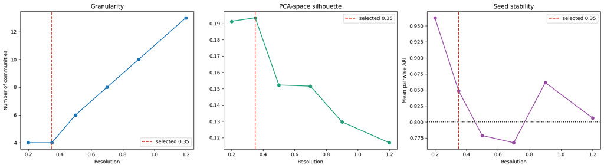

```python
fig, axes = plt.subplots(1, 3, figsize=(17, 4.8))
axes[0].plot(leiden_sweep["resolution"], leiden_sweep["n_clusters"], marker="o")
axes[0].set_title("Granularity")
axes[0].set_ylabel("Number of communities")

axes[1].plot(leiden_sweep["resolution"], leiden_sweep["silhouette"], marker="o", color="#1b9e77")
axes[1].set_title("PCA-space silhouette")

axes[2].plot(leiden_sweep["resolution"], leiden_sweep["mean_seed_ARI"], marker="o", color="#984ea3")
axes[2].axhline(0.80, color="black", linestyle=":")
axes[2].set_title("Seed stability")
axes[2].set_ylabel("Mean pairwise ARI")

for ax in axes:
    ax.axvline(BEST_RESOLUTION, color="#d73027", linestyle="--", label=f"selected {BEST_RESOLUTION:.2f}")
    ax.set_xlabel("Resolution")
    ax.legend()
plt.tight_layout()
plt.show()
```

The granularity panel shows the expected step pattern: more communities as resolution grows, though not strictly linearly (a jump from 4 to 6 communities between resolution 0.35 and 0.50, then to 8 at 0.70, before continuing to 10 and 13). The silhouette panel peaks at the two lowest resolutions and declines from there, mirroring the K-means result: finer partitions of this graph are not more geometrically well-separated, they are less. The stability panel is the one that decides the selection. It dips at the two resolutions (0.50 and 0.70) whose silhouette had already started declining, and the selected resolution (red dashed line) sits at the last point before that dip, where both silhouette and stability are still high.

## 11.3 Hierarchical Clustering (Ward Linkage)

Agglomerative clustering starts with every cell as its own cluster and repeatedly merges the two closest clusters until only one remains, recording each merge's height to build a dendrogram. With Ward linkage the pair merged at each step is the one producing the smallest increase in total within-cluster variance, the same quantity K-means minimises directly (section 11.1), which makes Ward its natural counterpart in the hierarchical family. Unlike K-means or Leiden, no cluster count is fixed in advance: the hierarchy is built once on the same 50-PC space (`X_pca`) used everywhere else, and any number of clusters can be read off by cutting the tree.

Instead of a separate sweep, the merge heights supply the diagnostic: the gap between consecutive merges shows whether stopping at a given cluster count cuts across a well-separated jump or in the middle of a gradual progression. Two cuts are read off: the one the gap structure points to, and $K=10$, kept for comparability with the forced K-means experiment.

|  | clusters_remaining | merge_height | gap_from_previous |
| --- | --- | --- | --- |
| 0 | 2 | 480.4 | nan |
| 1 | 3 | 317.0 | 163.5 |
| 2 | 4 | 248.4 | 68.6 |
| 3 | 5 | 172.5 | 75.8 |
| 4 | 6 | 148.7 | 23.8 |
| 5 | 7 | 122.8 | 25.9 |
| 6 | 8 | 120.6 | 2.2 |
| 7 | 9 | 118.7 | 1.9 |
| 8 | 10 | 108.4 | 10.3 |
| 9 | 11 | 108.1 | 0.3 |
| 10 | 12 | 106.3 | 1.8 |
| 11 | 13 | 100.4 | 5.9 |
| 12 | 14 | 96.6 | 3.7 |
| 13 | 15 | 91.1 | 5.5 |
| 14 | 16 | 81.7 | 9.5 |

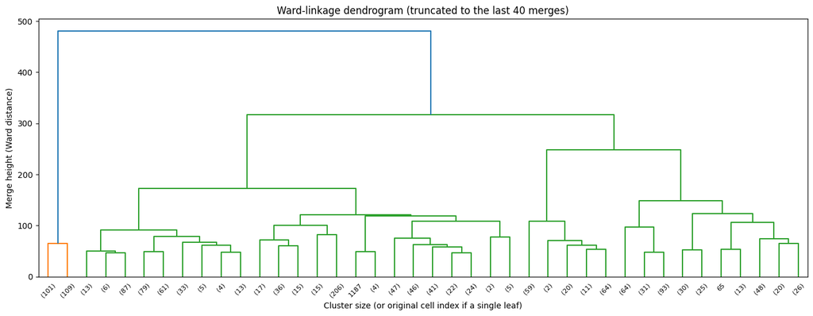

```python
hierarchical_linkage = linkage(X_pca, method="ward", metric="euclidean")

n_clusters_before_merge = np.arange(2, 17)
merge_heights_desc = hierarchical_linkage[-15:, 2][::-1]
merge_gap_table = pd.DataFrame({
    "clusters_remaining": n_clusters_before_merge,
    "merge_height": merge_heights_desc,
})
merge_gap_table["gap_from_previous"] = merge_gap_table["merge_height"].diff().abs()
display(merge_gap_table.style.format({"merge_height": "{:.1f}", "gap_from_previous": "{:.1f}"}))

fig, ax = plt.subplots(figsize=(14, 5.5))
dendrogram(
    hierarchical_linkage,
    truncate_mode="lastp",
    p=40,
    show_leaf_counts=True,
    leaf_font_size=8,
    ax=ax,
)
ax.set_title("Ward-linkage dendrogram (truncated to the last 40 merges)")
ax.set_xlabel("Cluster size (or original cell index if a single leaf)")
ax.set_ylabel("Merge height (Ward distance)")
plt.tight_layout()
plt.show()

hierarchical_k2 = fcluster(hierarchical_linkage, t=2, criterion="maxclust").astype(str)
hierarchical_k10 = fcluster(hierarchical_linkage, t=10, criterion="maxclust").astype(str)
adata_analysis.obs["hierarchical_k2"] = pd.Categorical(hierarchical_k2)
adata_analysis.obs["hierarchical_k10"] = pd.Categorical(hierarchical_k10)
```

The gap between merge heights gives an unambiguous answer: going from 2 clusters to 3 requires a height drop of **163.5**, by far the largest gap anywhere near the top of the tree, an isolated jump of the kind that signals a real structural break and not an arbitrary cut. The next-largest gaps, between 4 and 5 clusters (75.8) and 3 and 4 (68.6), are markedly smaller but still stand out from everything beyond 6 clusters, where every gap drops below 26 and mostly under 10. This is a third independent confirmation of the two-scale structure found by K-means (silhouette peaking at K=2) and Leiden (4 stable communities): a dominant two-way split, a weaker case for around four groups, and no support anywhere for a ten-way division. The dendrogram shows one short, early branch splitting off at very high merge distance before the rest resolves gradually, consistent with one distinct population separating first and then a continuum. Whether that first branch is `MEP_broad`, as it has been for every other clustering method so far, is checked quantitatively below once the labels are opened.

## 11.4 Post-Hoc Comparison with the Known Annotations

Only now are the 1,074 annotated cells used, and only to *evaluate* the partitions already selected above without labels. None of the four metrics below is used to refit or reselect any unsupervised model.

**ARI** (Adjusted Rand Index) counts, over all pairs of cells, how often the clustering and the known cell type agree on whether a pair is together or apart, corrected so a random partition scores 0 and a perfect match 1: $$\mathrm{ARI}=\frac{\mathrm{RI}-\mathbb{E}[\mathrm{RI}]}{\max(\mathrm{RI})-\mathbb{E}[\mathrm{RI}]},$$ where RI is the raw fraction of agreeing pairs. Being computed over pairs, it penalises both merging distinct types into one cluster and splitting one type across several.

**NMI** (Normalised Mutual Information) instead measures shared information between the two partitions using entropy instead of pairwise agreement: $$\mathrm{NMI}(C,T)=\frac{2\,I(C,T)}{H(C)+H(T)}, \qquad I(C,T)=\sum_{k,t}p(k,t)\log\frac{p(k,t)}{p(k)p(t)},$$ where $C$ is the clustering, $T$ the known cell type, and $I(C,T)$ their mutual information. NMI is bounded in $[0,1]$ and, unlike ARI, is not chance-adjusted, so it sits somewhat higher for the same partition.

**Purity** assigns each cluster its majority known label and counts correctly labelled cells; it inflates with many small clusters, since a tiny cluster is easy to make pure by chance.

**Entropy** $H(C)=-\sum_t p(t\mid C)\log_2p(t\mid C)$ measures label mixture *within* a cluster instead of agreement across the whole partition. We report a size-weighted entropy normalised by $\log_2(10)$, so zero is pure and one is maximally mixed across ten classes.

The **cosine similarity** used later in this section for pairs of biologically related classes measures the angle, not the distance, between two distribution vectors: $$\cos(x,y)=\frac{\sum_i x_iy_i}{\sqrt{\sum_i x_i^2}\sqrt{\sum_i y_i^2}}=\frac{x\cdot y}{\lVert x\rVert\lVert y\rVert},$$ applied to each known class's distribution across discovered clusters, asking whether two related classes spread across the solution in a similar pattern regardless of their different sizes.

All five partitions obtained so far (the two K-means solutions, Leiden, and the two hierarchical cuts) are compared together in this section, using the cluster assignments already stored in `adata_analysis.obs`.

```python
known_types = adata_analysis.obs.loc[annotated_mask, "cell_type"].astype(str).to_numpy()

def contingency_for(labels):
    table = pd.crosstab(
        pd.Series(np.asarray(labels)[annotated_mask], name="cluster"),
        pd.Categorical(known_types, categories=label_order, ordered=True),
        dropna=False,
    )
    return table.reindex(columns=label_order, fill_value=0)

def clustering_posthoc_metrics(labels):
    labels_known = np.asarray(labels)[annotated_mask].astype(str)
    table = contingency_for(labels)
    n = table.to_numpy().sum()
    purity = table.max(axis=1).sum() / n
    cluster_sizes = table.sum(axis=1).to_numpy()
    entropies = []
    for row in table.to_numpy():
        probabilities = row[row > 0] / row.sum()
        entropies.append(scipy_entropy(probabilities, base=2))
    weighted_entropy = np.average(entropies, weights=cluster_sizes) / np.log2(len(label_order))
    return {
        "n_clusters": len(np.unique(labels_known)),
        "ARI": adjusted_rand_score(known_types, labels_known),
        "NMI": normalized_mutual_info_score(known_types, labels_known),
        "purity": purity,
        "normalised_weighted_entropy": weighted_entropy,
    }

clustering_solutions = {
    f"K-means internal (K={BEST_K})": adata_analysis.obs["kmeans_internal"].astype(str).to_numpy(),
    "K-means forced (K=10)": adata_analysis.obs["kmeans_k10"].astype(str).to_numpy(),
    f"Leiden (resolution={BEST_RESOLUTION:.2f})": adata_analysis.obs["leiden"].astype(str).to_numpy(),
    "Hierarchical (Ward, K=2)": adata_analysis.obs["hierarchical_k2"].astype(str).to_numpy(),
    "Hierarchical (Ward, K=10)": adata_analysis.obs["hierarchical_k10"].astype(str).to_numpy(),
}

cluster_comparison = pd.DataFrame({
    name: clustering_posthoc_metrics(labels)
    for name, labels in clustering_solutions.items()
}).T
display(cluster_comparison.style.format({
    "ARI": "{:.3f}", "NMI": "{:.3f}", "purity": "{:.3f}",
    "normalised_weighted_entropy": "{:.3f}",
}))
```

|  | n_clusters | ARI | NMI | purity | normalised_weighted_entropy |
| --- | --- | --- | --- | --- | --- |
| K-means internal (K=2) | 2.000000 | 0.075 | 0.231 | 0.384 | 0.741 |
| K-means forced (K=10) | 10.000000 | 0.292 | 0.418 | 0.553 | 0.490 |
| Leiden (resolution=0.35) | 4.000000 | 0.194 | 0.401 | 0.482 | 0.585 |
| Hierarchical (Ward, K=2) | 2.000000 | 0.025 | 0.171 | 0.345 | 0.777 |
| Hierarchical (Ward, K=10) | 10.000000 | 0.263 | 0.388 | 0.529 | 0.528 |

With all five partitions now compared, K-means forced to K=10 remains the best on every metric (ARI 0.292, NMI 0.418, purity 0.553, entropy 0.490), and the hierarchical K=10 cut lands close behind it (ARI 0.263, NMI 0.388, purity 0.529, entropy 0.528). Both solutions forced to ten clusters clearly outperform every internally, label-free-selected solution, regardless of which algorithm produced them. Leiden (ARI 0.194, 4 communities) sits between the two K=10 solutions and the two K=2 solutions. The two internally selected two-way splits tell a more surprising story: K-means's own K=2 (ARI 0.075) outperforms hierarchical's K=2 (ARI 0.025) on every single metric, even though the dendrogram's gap statistic pointed to K=2 with the same confidence K-means's silhouette and stability did. The gap in the tree correctly identifies where a genuine structural break exists; it does not guarantee that cutting there produces the same partition another algorithm would find at the same K. The heatmap below shows why.

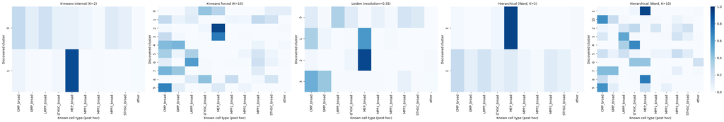

```python
fig, axes = plt.subplots(1, len(clustering_solutions), figsize=(6.5 * len(clustering_solutions), 5.5))
for ax, (name, labels) in zip(axes, clustering_solutions.items()):
    table = contingency_for(labels)
    row_proportions = table.div(table.sum(axis=1), axis=0).fillna(0)
    sns.heatmap(
        row_proportions, cmap="Blues", vmin=0, vmax=1,
        cbar=ax is axes[-1], ax=ax,
    )
    ax.set_title(name, fontsize=10)
    ax.set_xlabel("Known cell type (post hoc)")
    ax.set_ylabel("Discovered cluster")
plt.tight_layout()
plt.show()
```

The contingency heatmap summarises composition numerically, but it cannot show whether a discovered cluster occupies a spatially coherent region of the manifold or is scattered across it. As a complementary, purely illustrative check, each clustering solution, fitted entirely in the 50-PC space and never on 2D coordinates, is projected onto the same reference UMAP used in section 10. This plot does not feed back into any selection made above; it is read only for whether cluster boundaries correspond to visually contiguous regions of the embedding.

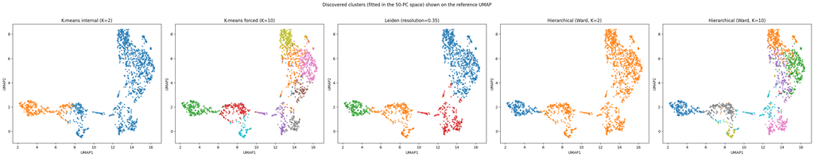

```python
fig, axes = plt.subplots(1, len(clustering_solutions), figsize=(6.2 * len(clustering_solutions), 5.8))
for ax, (name, labels) in zip(axes, clustering_solutions.items()):
    labels = np.asarray(labels)
    unique_labels = sorted(np.unique(labels), key=lambda x: int(x))
    cluster_palette = dict(zip(unique_labels, sns.color_palette("tab10", len(unique_labels))))
    point_colors = [cluster_palette[label] for label in labels]
    ax.scatter(X_umap[:, 0], X_umap[:, 1], c=point_colors, s=14, alpha=0.75, linewidth=0)
    ax.set_title(name)
    ax.set_xlabel("UMAP1")
    ax.set_ylabel("UMAP2")
plt.suptitle("Discovered clusters (fitted in the 50-PC space) shown on the reference UMAP", y=1.02)
plt.tight_layout()
plt.show()
```

```python
lineage_pairs = [
    ("LTHSC_broad", "STHSC_broad"),
    ("MPP1_broad", "LMPP_broad"),
    ("MPP3_broad", "CMP_broad"),
    ("CMP_broad", "GMP_broad"),
    ("MPP2_broad", "MEP_broad"),
]

pair_rows = []
for method, labels in clustering_solutions.items():
    type_by_cluster = pd.crosstab(
        pd.Categorical(known_types, categories=label_order),
        np.asarray(labels)[annotated_mask].astype(str),
        normalize="index",
        dropna=False,
    ).reindex(label_order).fillna(0)
    for first, second in lineage_pairs:
        a = type_by_cluster.loc[first].to_numpy()
        b = type_by_cluster.loc[second].to_numpy()
        denominator = np.linalg.norm(a) * np.linalg.norm(b)
        similarity = float(np.dot(a, b) / denominator) if denominator else np.nan
        pair_rows.append({
            "method": method,
            "biological_pair": f"{first.replace('_broad','')} - {second.replace('_broad','')}",
            "cluster-distribution cosine similarity": similarity,
        })

lineage_pair_similarity = pd.DataFrame(pair_rows)
display(lineage_pair_similarity.pivot(
    index="biological_pair",
    columns="method",
    values="cluster-distribution cosine similarity",
).style.format("{:.3f}"))
```

| method biological_pair | Hierarchical (Ward, K=10) | Hierarchical (Ward, K=2) | K-means forced (K=10) | K-means internal (K=2) | Leiden (resolution=0.35) |
| --- | --- | --- | --- | --- | --- |
| CMP - GMP | 0.792 | 1.000 | 0.726 | 0.999 | 0.795 |
| LTHSC - STHSC | 0.922 | 0.996 | 0.619 | 0.995 | 0.996 |
| MPP1 - LMPP | 0.347 | 1.000 | 0.240 | 1.000 | 1.000 |
| MPP2 - MEP | 0.092 | 0.626 | 0.095 | 0.389 | 0.262 |
| MPP3 - CMP | 0.571 | 1.000 | 0.611 | 0.999 | 0.590 |

The one result consistent and low across every method and granularity is **MPP2-MEP**: 0.389 at K-means K=2, 0.262 for Leiden, 0.095 at K-means K=10, 0.092 at hierarchical K=10. The expected megakaryocyte-erythroid link is the single pre-specified pair no clustering solution places together at any resolution. The apparent exception, hierarchical K=2's 0.626, is not a recovery of that link but the same coarse-partition inflation, made worse because hierarchical's K=2 clusters do not isolate `MEP_broad` as completely as K-means's do, so its distribution across the two clusters is less extreme and its similarity with every other class is mechanically pulled upward. The finer K=10 comparisons agree with section 5.7: `MPP2_broad` is the smallest class after `other` and its defining marker `Pf4` is the weakest and most dropout-affected in the panel, so its transcriptional identity is the least distinct to begin with. Unsupervised and marker evidence reach that conclusion independently.

## 11.5 Self-Organizing Map: A Topological View of the Continuum

A Self-Organizing Map (SOM) is an unsupervised, single-layer neural map arranged on a two-dimensional grid. Each node has a prototype vector $w_j$ in the selected PCA space. For an input cell $x$, the **Best Matching Unit** is

$$\operatorname{BMU}(x)=\arg\min_j\lVert x-w_j\rVert.$$

Tangherloni's slides distinguish two legitimate training rules. In the **online** rule, one sampled observation updates the BMU and its neighbours:

$$w_j(t+1)=w_j(t)+\alpha(t)h_{j,\operatorname{BMU}}(t)[x-w_j(t)],$$

where $\alpha(t)$ is a decaying learning rate and $h$ is a Gaussian neighbourhood kernel whose radius also shrinks. Early updates organise global topology; later updates refine local prototypes.

The lecture recommends the **batch** rule for practical applications. At each epoch all cells are assigned to BMUs and every prototype becomes a neighbourhood-weighted mean:

$$ w_j(t+1)=\frac{\sum_i h_{j,\operatorname{BMU}(x_i)}(t)x_i} {\sum_i h_{j,\operatorname{BMU}(x_i)}(t)}. $$

Batch training removes the learning-rate parameter and is deterministic once the initial prototypes are fixed, so we use batch updates, a Gaussian neighbourhood, and PCA initialisation, all described in the lecture. A more common route would be `SimpSOM` with `train_algo="online"` or `MiniSom.train_random`; the NumPy/SciPy implementation here follows the batch equation directly and avoids an extra dependency.

Kohonen's size heuristic is roughly $5\sqrt{n}$ map units, so $n=1{,}499$ cells give about 194 and the nearest square grid is **14x14 = 196 nodes**. That is a map resolution, not a claim that 196 biological populations exist. Rectangular and hexagonal lattices are both valid; the rectangular one is kept because hit maps and U-matrices then read directly as aligned heatmaps.

PCA initialisation places the grid along the two largest covariance directions, reducing arbitrary rotation and speeding up ordering. A hit map counts assigned cells, the U-matrix reports distances between neighbouring prototypes, quantisation error measures representation accuracy, and topographic error tests whether the two closest prototypes are adjacent. Label composition is inspected only after training, and SOM adjacency can reveal gradual organisation without establishing temporal direction or lineage ancestry.

```python
class BatchSOM:
    '''Deterministic rectangular SOM using the batch update from the lecture.'''

    def __init__(self, rows, cols, input_dim):
        self.rows = rows
        self.cols = cols
        self.input_dim = input_dim
        self.grid = np.array(
            [(r, c) for r in range(rows) for c in range(cols)], dtype=float
        )
        self.grid_distance_sq = cdist(
            self.grid, self.grid, metric="sqeuclidean"
        )
        self.weights = None
        self.history_ = None

    def _pca_initialise(self, X):
        centre = X.mean(axis=0)
        covariance = np.cov(X, rowvar=False)
        eigenvalues, eigenvectors = np.linalg.eigh(covariance)
        order = np.argsort(eigenvalues)[::-1]
        axes = eigenvectors[:, order[:2]]
        scales = np.sqrt(np.maximum(eigenvalues[order[:2]], 0))

        row_coordinate = np.linspace(-1.5, 1.5, self.rows)
        col_coordinate = np.linspace(-1.5, 1.5, self.cols)
        coefficients = np.array([
            (row_coordinate[int(r)], col_coordinate[int(c)])
            for r, c in self.grid
        ])
        self.weights = (
            centre
            + coefficients[:, [0]] * scales[0] * axes[:, 0]
            + coefficients[:, [1]] * scales[1] * axes[:, 1]
        )

    def fit(self, X, n_epochs=30, sigma_start=None, sigma_end=0.75):
        X = np.asarray(X, dtype=np.float64)
        sigma_start = sigma_start or max(self.rows, self.cols) / 2
        self._pca_initialise(X)
        history = []

        for epoch in range(n_epochs):
            fraction = epoch / max(1, n_epochs - 1)
            sigma = sigma_start * (sigma_end / sigma_start) ** fraction

            distances = cdist(X, self.weights, metric="sqeuclidean")
            bmu = np.argmin(distances, axis=1)
            neighbourhood = np.exp(
                -self.grid_distance_sq[:, bmu] / (2 * sigma ** 2)
            )
            denominator = neighbourhood.sum(axis=1, keepdims=True)
            self.weights = neighbourhood @ X / np.maximum(denominator, 1e-12)

            updated_bmu = self.bmu_indices(X)
            quantisation_error = np.mean(np.linalg.norm(
                X - self.weights[updated_bmu], axis=1
            ))
            history.append({
                "epoch": epoch + 1,
                "sigma": sigma,
                "quantisation_error": quantisation_error,
            })

        self.history_ = pd.DataFrame(history)
        return self

    def bmu_indices(self, X):
        return np.argmin(cdist(np.asarray(X), self.weights, metric="sqeuclidean"), axis=1)

    def u_matrix(self):
        values = np.zeros(len(self.grid))
        for index, location in enumerate(self.grid):
            neighbours = np.where(
                (np.max(np.abs(self.grid - location), axis=1) == 1)
            )[0]
            values[index] = np.mean(np.linalg.norm(
                self.weights[neighbours] - self.weights[index], axis=1
            ))
        return values.reshape(self.rows, self.cols)

    def topographic_error(self, X):
        distances = cdist(np.asarray(X), self.weights, metric="sqeuclidean")
        two_best = np.argsort(distances, axis=1)[:, :2]
        grid_separation = np.max(
            np.abs(self.grid[two_best[:, 0]] - self.grid[two_best[:, 1]]), axis=1
        )
        return float(np.mean(grid_separation > 1))

SOM_TARGET_NODES = int(round(5 * np.sqrt(adata_analysis.n_obs)))
SOM_SIDE = int(round(np.sqrt(SOM_TARGET_NODES)))
SOM_ROWS, SOM_COLS = SOM_SIDE, SOM_SIDE
SOM_NODES = SOM_ROWS * SOM_COLS
som_scale = float(np.std(X_pca))
X_som = X_pca / som_scale

som = BatchSOM(SOM_ROWS, SOM_COLS, N_PCS).fit(
    X_som, n_epochs=30
)
som_bmu = som.bmu_indices(X_som)
som_hits = np.bincount(som_bmu, minlength=SOM_NODES).reshape(SOM_ROWS, SOM_COLS)
som_umatrix = som.u_matrix()
som_quantisation_error = float(np.mean(np.linalg.norm(
    X_som - som.weights[som_bmu], axis=1
)))
som_topographic_error = som.topographic_error(X_som)

adata_analysis.obs["som_node"] = pd.Categorical(som_bmu.astype(str))

display(pd.Series({
    "Kohonen target 5*sqrt(n)": SOM_TARGET_NODES,
    "grid": f"{SOM_ROWS} x {SOM_COLS}",
    "implemented nodes": SOM_NODES,
    "training rule": "batch",
    "initialisation": "PCA",
    "batch epochs": len(som.history_),
    "occupied nodes": int((som_hits > 0).sum()),
    "median hits among occupied nodes": float(np.median(som_hits[som_hits > 0])),
    "quantisation error": som_quantisation_error,
    "topographic error": som_topographic_error,
}).to_frame("value"))
```

|  | value |
| --- | --- |
| Kohonen target 5*sqrt(n) | 194 |
| grid | 14 x 14 |
| implemented nodes | 196 |
| training rule | batch |
| initialisation | PCA |
| batch epochs | 30 |
| occupied nodes | 192 |
| median hits among occupied nodes | 7.0 |
| quantisation error | 3.969525 |
| topographic error | 0.031354 |

The Kohonen heuristic gives **194** target nodes; the nearest square grid is **14x14 = 196** nodes, of which **192** end up occupied after training (the remaining 4 never become any cell's best matching unit), with a median of 7 cells per occupied node, consistent with 1,499 cells spread reasonably evenly across a map of this size. After 30 deterministic batch epochs, the mean quantisation error is **3.970** (in the same rescaled PCA units used to fit the map) and the topographic error is **0.031**: only 3.1% of cells have their two best-matching units in non-adjacent grid cells, so the map's topology is locally consistent for the large majority of cells. Nearby cells in expression space are almost always mapped to nearby, not distant, prototypes.

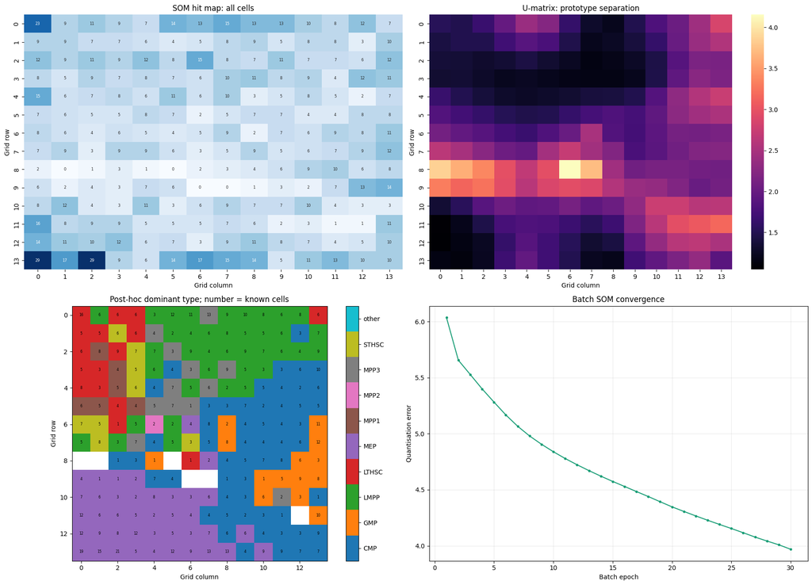

```python
node_known_counts = pd.crosstab(
    pd.Series(som_bmu[annotated_mask], name="node"),
    pd.Categorical(known_types, categories=label_order),
    dropna=False,
).reindex(index=range(SOM_ROWS * SOM_COLS), columns=label_order, fill_value=0)

dominant_code = np.full(SOM_ROWS * SOM_COLS, np.nan)
known_node_total = node_known_counts.sum(axis=1).to_numpy()
occupied_known = known_node_total > 0
dominant_code[occupied_known] = np.argmax(
    node_known_counts.to_numpy()[occupied_known], axis=1
)

fig, axes = plt.subplots(2, 2, figsize=(18, 13))
sns.heatmap(
    som_hits, cmap="Blues", annot=True, fmt="d", cbar=False,
    annot_kws={"fontsize": 6}, ax=axes[0, 0],
)
axes[0, 0].set_title("SOM hit map: all cells")
axes[0, 0].set_xlabel("Grid column")
axes[0, 0].set_ylabel("Grid row")

sns.heatmap(som_umatrix, cmap="magma", ax=axes[0, 1])
axes[0, 1].set_title("U-matrix: prototype separation")
axes[0, 1].set_xlabel("Grid column")
axes[0, 1].set_ylabel("Grid row")

dominant_grid = dominant_code.reshape(SOM_ROWS, SOM_COLS)
masked = np.ma.masked_invalid(dominant_grid)
im = axes[1, 0].imshow(masked, cmap="tab10", vmin=-0.5, vmax=9.5)
for node, total in enumerate(known_node_total):
    if total:
        r, c = divmod(node, SOM_COLS)
        axes[1, 0].text(c, r, str(int(total)), ha="center", va="center", fontsize=5.5)
axes[1, 0].set_title("Post-hoc dominant type; number = known cells")
axes[1, 0].set_xlabel("Grid column")
axes[1, 0].set_ylabel("Grid row")
cbar = fig.colorbar(im, ax=axes[1, 0], ticks=range(len(label_order)))
cbar.ax.set_yticklabels([x.replace("_broad", "") for x in label_order])

axes[1, 1].plot(
    som.history_["epoch"], som.history_["quantisation_error"],
    marker="o", markersize=3, color="#1b9e77",
)
axes[1, 1].set_title("Batch SOM convergence")
axes[1, 1].set_xlabel("Batch epoch")
axes[1, 1].set_ylabel("Quantisation error")
axes[1, 1].grid(alpha=0.25)

plt.tight_layout()
plt.show()
```

```python
som_node_k_rows = []
som_node_clusterings = {}
for k in range(2, 13):
    labels = KMeans(n_clusters=k, n_init=30, random_state=SEED).fit_predict(som.weights)
    som_node_clusterings[k] = labels
    som_node_k_rows.append({
        "k": k,
        "prototype_silhouette": silhouette_score(som.weights, labels),
    })

som_node_sweep = pd.DataFrame(som_node_k_rows)
SOM_K = int(som_node_sweep.loc[
    som_node_sweep["prototype_silhouette"].idxmax(), "k"
])
som_cell_clusters = som_node_clusterings[SOM_K][som_bmu].astype(str)
adata_analysis.obs["som_cluster"] = pd.Categorical(som_cell_clusters)

som_name = f"SOM prototypes + K-means (K={SOM_K})"
clustering_solutions[som_name] = som_cell_clusters
som_metrics = clustering_posthoc_metrics(som_cell_clusters)
cluster_comparison.loc[som_name] = som_metrics

display(som_node_sweep.style.format({"prototype_silhouette": "{:.3f}"}))
display(cluster_comparison.style.format({
    "ARI": "{:.3f}", "NMI": "{:.3f}", "purity": "{:.3f}",
    "normalised_weighted_entropy": "{:.3f}",
}))
```

|  | k | prototype_silhouette |
| --- | --- | --- |
| 0 | 2 | 0.395 |
| 1 | 3 | 0.300 |
| 2 | 4 | 0.347 |
| 3 | 5 | 0.294 |
| 4 | 6 | 0.291 |
| 5 | 7 | 0.289 |
| 6 | 8 | 0.288 |
| 7 | 9 | 0.282 |
| 8 | 10 | 0.297 |
| 9 | 11 | 0.303 |
| 10 | 12 | 0.315 |

|  | n_clusters | ARI | NMI | purity | normalised_weighted_entropy |
| --- | --- | --- | --- | --- | --- |
| K-means internal (K=2) | 2.000000 | 0.075 | 0.231 | 0.384 | 0.741 |
| K-means forced (K=10) | 10.000000 | 0.292 | 0.418 | 0.553 | 0.490 |
| Leiden (resolution=0.35) | 4.000000 | 0.194 | 0.401 | 0.482 | 0.585 |
| Hierarchical (Ward, K=2) | 2.000000 | 0.025 | 0.171 | 0.345 | 0.777 |
| Hierarchical (Ward, K=10) | 10.000000 | 0.263 | 0.388 | 0.529 | 0.528 |
| SOM prototypes + K-means (K=2) | 2.000000 | 0.089 | 0.246 | 0.390 | 0.732 |

# 12. Differential Expression and Biological Interpretation of Clusters

Clustering produces groups; it does not name them. We now ask which genes distinguish each of the four Leiden communities selected in section 11.2 from all remaining cells, returning to `adata_biology` with all 4,290 genes on the transformed but **unscaled** scale. Restricting the test to HVGs would make marker discovery circular and could remove stable lineage markers, and z-scores would obscure the original expression contrasts.

For each gene and cluster, a Wilcoxon rank-sum test compares the ranks of expression values inside the cluster with those outside it. This is the same test already used in section 5.6, there via `scipy.stats.mannwhitneyu` on cell-level summary metrics, here via Scanpy's implementation applied gene by gene. Ranking instead of comparing raw means makes the test far less sensitive to the extreme values a dropout-heavy, non-normal distribution produces. For a cluster of $n_1$ cells against $n_2$ elsewhere, ranks are assigned across the pooled $n_1+n_2$ values, and

$$U = R_1 - \frac{n_1(n_1+1)}{2},$$

where $R_1$ is the sum of ranks held by the in-cluster cells; the `scores` column reported below is the z-statistic of the normal approximation to $U$, so a larger magnitude means a more extreme rank imbalance, in either direction.

Testing 4,290 genes across four clusters means over 17,000 simultaneous tests, so raw $p$-values would produce false positives by chance. Benjamini-Hochberg controls this: $p$-values are sorted ascending and every hypothesis up to the largest $k$ satisfying $p_{(k)}\le\frac{k}{m}\alpha$ is declared significant, keeping the *expected proportion* of false positives among declared genes at or below $\alpha$ (here 0.05). That is a controlled error rate, not a guarantee that any individual gene is a true marker.

Important limitations remain. Cells are treated as independent observations even though no donor or batch metadata are available, and rank-based differential expression describes association, not regulation. A cluster is interpreted from converging evidence:

1. post-hoc label composition;
2. several dataset-discovered differential genes;
3. coherent canonical marker programmes;
4. its relation to neighbouring progenitor populations.

No identity is assigned from one gene alone.

```python
adata_de = adata_biology.copy()
adata_de.var_names = adata_de.var["Symbol"].astype(str)
adata_de.var_names_make_unique()
adata_de.obs["leiden"] = pd.Categorical(
    adata_analysis.obs["leiden"].astype(str).to_numpy()
)
adata_de.uns["log1p"] = {"base": 2}

sc.tl.rank_genes_groups(
    adata_de,
    groupby="leiden",
    method="wilcoxon",
    reference="rest",
    corr_method="benjamini-hochberg",
    pts=True,
    use_raw=False,
    key_added="leiden_wilcoxon",
)

de_tables = {}
top_de_rows = []
for cluster in adata_de.obs["leiden"].cat.categories:
    table = sc.get.rank_genes_groups_df(
        adata_de, group=cluster, key="leiden_wilcoxon"
    )
    table = table.replace([np.inf, -np.inf], np.nan)
    significant = table.loc[
        table["pvals_adj"].lt(0.05)
        & table["logfoldchanges"].gt(0.25)
    ].copy()
    selected = significant.head(8) if len(significant) else table.head(8)
    selected.insert(0, "cluster", str(cluster))
    de_tables[str(cluster)] = table
    top_de_rows.append(selected)

top_de_markers = pd.concat(top_de_rows, ignore_index=True)
de_display_columns = [
    column for column in [
        "cluster", "names", "scores", "logfoldchanges", "pvals_adj",
        "pct_nz_group", "pct_nz_reference",
    ] if column in top_de_markers.columns
]
display(top_de_markers[de_display_columns].style.format({
    "scores": "{:.2f}",
    "logfoldchanges": "{:.2f}",
    "pvals_adj": "{:.2e}",
    "pct_nz_group": "{:.2f}",
    "pct_nz_reference": "{:.2f}",
}))
```

|  | cluster | names | scores | logfoldchanges | pvals_adj | pct_nz_group | pct_nz_reference |
| --- | --- | --- | --- | --- | --- | --- | --- |
| 0 | 0 | Lsp1 | 28.03 | 5.51 | 1.45e-169 | 1.00 | 0.94 |
| 1 | 0 | Gimap6 | 27.78 | 5.06 | 1.24e-166 | 1.00 | 0.96 |
| 2 | 0 | Ly6a | 27.74 | 6.07 | 2.19e-166 | 0.99 | 0.89 |
| 3 | 0 | Gcnt2 | 26.69 | 4.93 | 4.75e-154 | 0.99 | 0.93 |
| 4 | 0 | Hlf | 25.87 | 5.29 | 8.17e-145 | 0.97 | 0.83 |
| 5 | 0 | Adgrl4 | 25.73 | 4.62 | 2.88e-143 | 1.00 | 0.96 |
| 6 | 0 | Shisa5 | 25.37 | 3.33 | 2.59e-139 | 1.00 | 1.00 |
| 7 | 0 | Gm19590 | 25.24 | 3.80 | 5.78e-138 | 1.00 | 0.98 |
| 8 | 1 | Apoe | 23.78 | 5.60 | 2.34e-121 | 1.00 | 0.99 |
| 9 | 1 | Mfsd2b | 22.95 | 6.02 | 3.48e-113 | 1.00 | 0.94 |
| 10 | 1 | Vamp5 | 21.20 | 3.00 | 1.40e-96 | 1.00 | 0.99 |
| 11 | 1 | S100a10 | 19.15 | 1.97 | 1.01e-78 | 1.00 | 1.00 |
| 12 | 1 | Gm15915 | 18.66 | 5.19 | 6.88e-75 | 0.99 | 0.85 |
| 13 | 1 | Gata2 | 17.94 | 3.77 | 2.65e-69 | 1.00 | 0.96 |
| 14 | 1 | Cdk6 | 17.42 | 1.84 | 1.93e-65 | 1.00 | 1.00 |
| 15 | 1 | Gata1 | 17.36 | 4.65 | 5.27e-65 | 0.99 | 0.88 |
| 16 | 2 | C1qtnf12 | 22.12 | 6.92 | 6.97e-105 | 1.00 | 0.96 |
| 17 | 2 | Fth1 | 22.10 | 2.08 | 6.97e-105 | 1.00 | 1.00 |
| 18 | 2 | Tmem14c | 22.07 | 4.05 | 8.15e-105 | 1.00 | 1.00 |
| 19 | 2 | Ctse | 22.04 | 6.90 | 1.33e-104 | 1.00 | 0.95 |
| 20 | 2 | Nxpe2 | 22.01 | 7.46 | 1.63e-104 | 1.00 | 0.90 |
| 21 | 2 | Car2 | 22.00 | 4.28 | 1.63e-104 | 1.00 | 1.00 |
| 22 | 2 | Prdx2 | 22.00 | 2.82 | 1.63e-104 | 1.00 | 1.00 |
| 23 | 2 | Rhag | 22.00 | 8.42 | 1.63e-104 | 1.00 | 0.70 |
| 24 | 3 | Ctsg | 23.88 | 7.82 | 2.16e-122 | 1.00 | 0.95 |
| 25 | 3 | Mpo | 23.46 | 6.71 | 2.18e-118 | 1.00 | 1.00 |
| 26 | 3 | Plac8 | 22.36 | 3.75 | 1.32e-107 | 1.00 | 1.00 |
| 27 | 3 | Rab44 | 22.30 | 6.52 | 3.65e-107 | 1.00 | 0.77 |
| 28 | 3 | Prtn3 | 22.26 | 4.83 | 7.77e-107 | 1.00 | 0.99 |
| 29 | 3 | Atp8b4 | 20.86 | 6.21 | 8.11e-94 | 0.99 | 0.70 |
| 30 | 3 | Tyrobp | 20.56 | 5.58 | 3.71e-91 | 0.99 | 0.83 |
| 31 | 3 | Ap3s1 | 20.49 | 4.19 | 1.38e-90 | 1.00 | 0.90 |

Every one of the top eight genes per cluster clears both filters by a wide margin: adjusted $p$-values run as low as $10^{-169}$ and log fold-changes sit between roughly 2 and 8, well above the 0.25 threshold. These are strong signals, not marginal calls surviving on sample size alone. `pct_nz_group` is at or near 1.00 for essentially every gene listed, so each is detected in nearly every cell of its cluster, while `pct_nz_reference` varies from 0.70 (`Rhag` in cluster 2, `Atp8b4` in cluster 3) up to 1.00 for several genes in cluster 2 (`Fth1`, `Car2`, `Prdx2`). Where the reference detection rate is already high, the significance comes from a level difference and not a detection difference, which is a different and in some ways more robust kind of marker than an on/off dropout-sensitive one.

Two dot plots place the dataset-discovered genes and the canonical panel side by side, on the same four Leiden clusters, so the two independent sources of evidence can be compared directly and not only in a table. The first uses the three most significant discovered genes per cluster (twelve genes total); the second reuses the canonical marker panel from sections 4.4 and 5.7, grouped by the programme each marker was chosen to represent. In both, dot size is the fraction of cells in the cluster with a positive value and colour is mean expression, scaled per gene so that only the pattern across clusters is compared, never absolute levels between different genes.

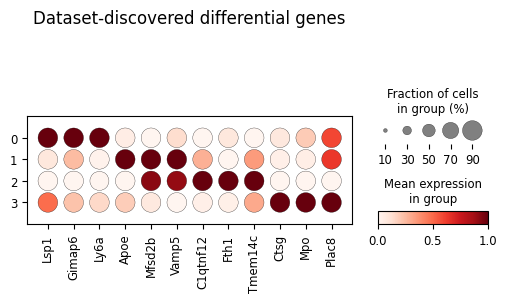

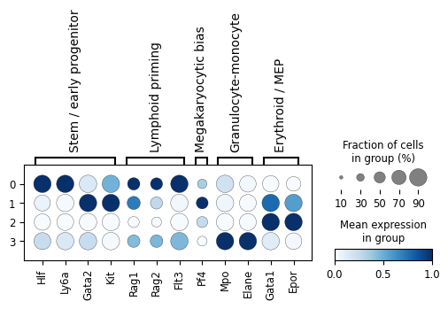

```python
cluster_order = list(adata_de.obs["leiden"].cat.categories)
dotplot_genes = []
for cluster in cluster_order:
    candidates = top_de_markers.loc[
        top_de_markers["cluster"].eq(str(cluster)), "names"
    ].head(3)
    for gene in candidates:
        if gene not in dotplot_genes:
            dotplot_genes.append(gene)

sc.pl.dotplot(
    adata_de,
    var_names=dotplot_genes,
    groupby="leiden",
    categories_order=cluster_order,
    standard_scale="var",
    color_map="Reds",
    dot_max=0.9,
    title="Dataset-discovered differential genes",
    show=True,
)

sc.pl.dotplot(
    adata_de,
    var_names=available_marker_sets,
    groupby="leiden",
    categories_order=cluster_order,
    standard_scale="var",
    color_map="Blues",
    dot_max=0.9,
    show=True,
)
```

The three sources of evidence considered so far (composition, discovered genes, canonical programme) are now assembled into a single table, one row per cluster, so each cluster's interpretation can be read as a whole instead of reassembled from three separate outputs. The canonical programme is the one with the highest mean z-scored expression across that programme's genes, computed on the per-cluster gene means; the discovered genes are the same ones already shown in the dot plot above.

```python
leiden_labels_all = adata_analysis.obs["leiden"].astype(str).to_numpy()
leiden_contingency = contingency_for(leiden_labels_all)

canonical_indices = {
    program: [adata_de.var_names.get_loc(gene) for gene in genes if gene in adata_de.var_names]
    for program, genes in available_marker_sets.items()
}
canonical_indices = {k: v for k, v in canonical_indices.items() if v}

cluster_gene_means = pd.DataFrame(
    np.vstack([
        np.asarray(adata_de.X[leiden_labels_all == cluster]).mean(axis=0)
        for cluster in cluster_order
    ]),
    index=cluster_order,
    columns=adata_de.var_names,
)
gene_sd_across_clusters = cluster_gene_means.std(axis=0).replace(0, 1)
cluster_gene_z = (cluster_gene_means - cluster_gene_means.mean(axis=0)) / gene_sd_across_clusters

program_scores = pd.DataFrame(index=cluster_order)
for program, genes in available_marker_sets.items():
    present = [gene for gene in genes if gene in cluster_gene_z.columns]
    if present:
        program_scores[program] = cluster_gene_z[present].mean(axis=1)

interpretation_rows = []
for cluster in cluster_order:
    composition = leiden_contingency.loc[cluster].sort_values(ascending=False)
    total_known = int(composition.sum())
    dominant_type = composition.index[0] if total_known else "No annotated cells"
    dominant_fraction = composition.iloc[0] / total_known if total_known else np.nan
    composition_text = "; ".join(
        f"{label.replace('_broad','')} {count / total_known:.0%}"
        for label, count in composition.head(3).items() if count > 0 and total_known
    )
    discovered = top_de_markers.loc[
        top_de_markers["cluster"].eq(str(cluster)), "names"
    ].head(5).tolist()
    strongest_program = program_scores.loc[cluster].idxmax()
    interpretation_rows.append({
        "Leiden cluster": cluster,
        "annotated cells": total_known,
        "dominant known type": dominant_type,
        "dominant fraction": dominant_fraction,
        "top composition": composition_text,
        "strongest canonical programme": strongest_program,
        "top discovered genes": ", ".join(discovered),
    })

cluster_interpretation = pd.DataFrame(interpretation_rows)
display(cluster_interpretation.style.format({"dominant fraction": "{:.1%}"}))
```

|  | Leiden cluster | annotated cells | dominant known type | dominant fraction | top composition | strongest canonical programme | top discovered genes |
| --- | --- | --- | --- | --- | --- | --- | --- |
| 0 | 0 | 542 | LMPP_broad | 32.3% | LMPP 32%; MPP3 18%; STHSC 13% | Lymphoid priming | Lsp1, Gimap6, Ly6a, Gcnt2, Hlf |
| 1 | 1 | 209 | MEP_broad | 59.8% | MEP 60%; CMP 33%; GMP 4% | Megakaryocytic bias | Apoe, Mfsd2b, Vamp5, S100a10, Gm15915 |
| 2 | 2 | 138 | MEP_broad | 91.3% | MEP 91%; LTHSC 4%; CMP 3% | Erythroid / MEP | C1qtnf12, Fth1, Tmem14c, Ctse, Nxpe2 |
| 3 | 3 | 185 | CMP_broad | 49.7% | CMP 50%; GMP 39%; MPP3 8% | Granulocyte-monocyte | Ctsg, Mpo, Plac8, Rab44, Prtn3 |

The four clusters fall into two kinds. **Cluster 2** is the most compositionally concentrated: 91.3% of its annotated cells are `MEP_broad`, its strongest canonical programme is Erythroid/MEP, and its top discovered genes (`C1qtnf12`, `Fth1`, `Tmem14c`, `Ctse`, `Nxpe2`) fit that identity. `Fth1` (ferritin, iron storage for haemoglobin synthesis) and, further down its ranked list, `Car2` and `Rhag` are the kind of genes an erythroid-committed population is expected to express. **Cluster 3** is nearly as concentrated (49.7% `CMP_broad` plus 39% `GMP_broad`, so 89% across the two most closely related myeloid classes), its programme is Granulocyte-monocyte, and its discovered genes (`Ctsg`, `Mpo`, `Plac8`, `Rab44`, `Prtn3`) are canonical granulocyte granule proteins. **Cluster 1** sits in between: 59.8% `MEP_broad` with a 33% `CMP_broad` remainder, a Megakaryocytic-bias programme, and discovered genes (`Apoe`, `Mfsd2b`, `Vamp5`, `S100a10`, `Gm15915`) that sit outside the canonical panel entirely, a real but less exclusively defined identity than cluster 2's.

**Cluster 0** is the outlier: no known type reaches even a third of its annotated cells (`LMPP_broad` 32%, `MPP3_broad` 18%, `STHSC_broad` 13%, the remaining 37% spread across the rest), and its canonical signature, elevated on the stem and lymphoid-priming markers at once, reflects that mixture instead of contradicting it. It is the same cluster the heatmap in section 11.4 showed absorbing `LMPP_broad`, `LTHSC_broad`, `MPP3_broad`, and `STHSC_broad` with no clean boundary. Such mixture can reflect a true developmental continuum, a resolution merging adjacent states, broad reference labels, or insufficient discriminative signal, and the data here cannot conclusively distinguish between those explanations.

Read together, the four clusters recover the two programmes with the strongest, most specific signatures in the notebook, erythroid (`MEP_broad`) and granulocyte-monocyte (`CMP_broad`/`GMP_broad`), as clean, well-separated clusters, while the stem, multipotent, and lymphoid-primed classes stay folded into one broad compartment. That is the differential-expression counterpart of what PCA, UMAP, and every clustering method in section 11 already found. Neither the discovered genes nor the canonical markers establish a causal interaction or a developmental trajectory; they describe association at a single time point.

# 13. Comparing PCA, an Autoencoder, and a Denoising Autoencoder

## 13.1 Representation Learning Question

PCA is a linear encoder. An autoencoder replaces the linear map with an encoder network $z=f_\phi(x)$ and a decoder $\hat{x}=g_\theta(z)$. The parameters minimise mean squared reconstruction error,

$$\mathcal{L}_{AE}=\frac{1}{n}\sum_i\lVert x_i-g_\theta(f_\phi(x_i))\rVert_2^2.$$

A single-hidden-layer **linear** autoencoder trained with MSE also spans the same optimal principal subspace as PCA, up to rotations and optimisation error. Fitting it as a fourth representation would therefore duplicate the PCA baseline. The AE below contains ReLU nonlinearities, so the comparison is PCA versus nonlinear AE versus nonlinear DAE at the same latent dimension.

The bottleneck forces compression but does not force the latent space to align with cell types, and with only 1,499 cells a large network could memorise the input. We therefore use a small symmetric architecture, weight decay, a validation split, and early stopping, with a grid search over the two main capacity knobs beforehand so the choice is justified the same way `N_PCS` and the HVG count were.

For the denoising autoencoder (DAE), controlled Gaussian noise is added to the scaled input while the clean vector remains the target:

$$\mathcal{L}_{DAE}=\mathbb{E}_{\epsilon}\lVert x-g_\theta(f_\phi(x+\epsilon))\rVert_2^2.$$

This encourages local robustness. It does **not** mean every observed zero is an error to repair, and it does not guarantee a more class-separable representation. AE and DAE share the *same* architecture, differing only in whether noise is injected, so a difference in outcome cannot come from a difference in capacity. The models here are label-blind and use all cells; the predictive comparison in section 14 refits every representation inside each training fold.

The section proceeds in four steps: selecting the architecture (13.2), fitting the AE, the DAE, and a dimension-matched PCA baseline (13.3), examining how well each represents the data through reconstruction error (13.4) and latent content (13.5), and comparing all three as feature spaces (13.6–13.7).

```python
torch.manual_seed(SEED)
torch.set_num_threads(2)
DEVICE = torch.device("cpu")

class TabularAutoencoder(nn.Module):
    def __init__(self, input_dim, latent_dim=16, hidden_dim=64):
        super().__init__()
        self.encoder = nn.Sequential(
            nn.Linear(input_dim, hidden_dim),
            nn.ReLU(),
            nn.Linear(hidden_dim, latent_dim),
        )
        self.decoder = nn.Sequential(
            nn.Linear(latent_dim, hidden_dim),
            nn.ReLU(),
            nn.Linear(hidden_dim, input_dim),
        )

    def forward(self, x):
        return self.decoder(self.encoder(x))

def encode_matrix(model, X, batch_size=256):
    model.eval()
    outputs = []
    with torch.no_grad():
        for start in range(0, len(X), batch_size):
            batch = torch.as_tensor(
                X[start:start + batch_size], dtype=torch.float32, device=DEVICE
            )
            outputs.append(model.encoder(batch).cpu().numpy())
    return np.vstack(outputs)

def reconstruct_matrix(model, X, batch_size=256):
    model.eval()
    outputs = []
    with torch.no_grad():
        for start in range(0, len(X), batch_size):
            batch = torch.as_tensor(
                X[start:start + batch_size], dtype=torch.float32, device=DEVICE
            )
            outputs.append(model(batch).cpu().numpy())
    return np.vstack(outputs)

def fit_autoencoder(
    X,
    noise_std=0.0,
    seed=42,
    latent_dim=16,
    hidden_dim=64,
    validation_fraction=0.20,
    max_epochs=120,
    patience=12,
    batch_size=128,
):
    torch.manual_seed(seed)
    rng = np.random.default_rng(seed)
    indices = np.arange(len(X))
    train_idx, val_idx = train_test_split(
        indices, test_size=validation_fraction, random_state=seed
    )
    X_train = np.asarray(X[train_idx], dtype=np.float32)
    X_val = np.asarray(X[val_idx], dtype=np.float32)

    model = TabularAutoencoder(
        input_dim=X.shape[1], latent_dim=latent_dim, hidden_dim=hidden_dim
    ).to(DEVICE)
    optimizer = torch.optim.Adam(model.parameters(), lr=1e-3, weight_decay=1e-4)
    criterion = nn.MSELoss()
    generator = torch.Generator().manual_seed(seed)
    loader = DataLoader(
        TensorDataset(torch.from_numpy(X_train)),
        batch_size=batch_size,
        shuffle=True,
        generator=generator,
        num_workers=0,
    )

    val_clean = torch.from_numpy(X_val).to(DEVICE)
    val_noise = torch.from_numpy(
        rng.normal(0, noise_std, size=X_val.shape).astype(np.float32)
    ).to(DEVICE)
    val_input = val_clean + val_noise

    history = []
    best_loss = np.inf
    best_state = None
    epochs_without_improvement = 0
    start_time = perf_counter()

    for epoch in range(1, max_epochs + 1):
        model.train()
        running_loss = 0.0
        observations = 0
        for (clean_batch,) in loader:
            clean_batch = clean_batch.to(DEVICE)
            if noise_std > 0:
                noisy_batch = clean_batch + noise_std * torch.randn_like(clean_batch)
            else:
                noisy_batch = clean_batch
            optimizer.zero_grad()
            reconstruction = model(noisy_batch)
            loss = criterion(reconstruction, clean_batch)
            loss.backward()
            optimizer.step()
            running_loss += loss.item() * len(clean_batch)
            observations += len(clean_batch)

        model.eval()
        with torch.no_grad():
            val_loss = criterion(model(val_input), val_clean).item()
        train_loss = running_loss / observations
        history.append({"epoch": epoch, "training_loss": train_loss, "validation_loss": val_loss})

        if val_loss < best_loss - 1e-5:
            best_loss = val_loss
            best_state = copy.deepcopy(model.state_dict())
            epochs_without_improvement = 0
        else:
            epochs_without_improvement += 1
            if epochs_without_improvement >= patience:
                break

    model.load_state_dict(best_state)
    clean_reconstruction = reconstruct_matrix(model, X_val)
    clean_val_mse = float(np.mean((clean_reconstruction - X_val) ** 2))
    return {
        "model": model,
        "history": pd.DataFrame(history),
        "train_idx": train_idx,
        "val_idx": val_idx,
        "best_objective_val_loss": float(best_loss),
        "clean_validation_mse": clean_val_mse,
        "epochs": len(history),
        "seconds": perf_counter() - start_time,
        "noise_std": noise_std,
    }
```

## 13.2 Selecting the Autoencoder Architecture

Two hyperparameters control the network's capacity: `hidden_dim`, the width of the single hidden layer in the encoder and decoder, and `latent_dim`, the size of the bottleneck itself. A small grid is tested: three latent sizes (8, 16, 32) against three hidden widths (32, 64, 128), nine configurations in total, each trained once without injected noise and compared through validation reconstruction MSE. Noise is left out of this search so that AE and DAE retain the same selected architecture and differ only in their training objective.

The same validation split and reconstruction loss contribute both to early stopping within each fit and to comparison across architectures. This is a practical exploratory strategy, but it means that the MSE of the selected configuration is mildly optimistic and should not be interpreted as performance on an independent test set. A separate outer validation layer would be required for an unbiased estimate of architecture-selection performance.

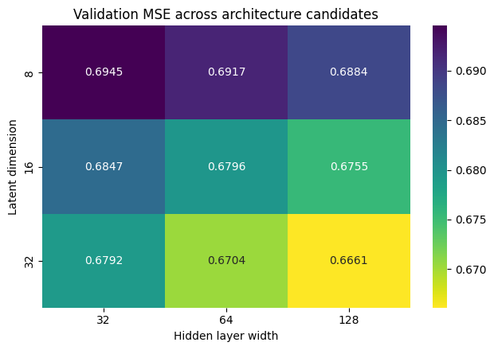

```
Selected architecture: latent_dim=32, hidden_dim=128
```

```python
architecture_grid = [
    {"latent_dim": latent_dim, "hidden_dim": hidden_dim}
    for latent_dim in [8, 16, 32]
    for hidden_dim in [32, 64, 128]
]
architecture_rows = []
for config in architecture_grid:
    trial_fit = fit_autoencoder(X_hvg_scaled, noise_std=0.0, seed=SEED, **config)
    architecture_rows.append({
        **config,
        "validation_MSE": trial_fit["best_objective_val_loss"],
        "epochs_to_converge": trial_fit["epochs"],
    })

architecture_sweep = pd.DataFrame(architecture_rows)
best_architecture = architecture_sweep.loc[architecture_sweep["validation_MSE"].idxmin()]
LATENT_DIM = int(best_architecture["latent_dim"])
HIDDEN_DIM = int(best_architecture["hidden_dim"])

architecture_pivot = architecture_sweep.pivot(
    index="latent_dim", columns="hidden_dim", values="validation_MSE"
)
fig, ax = plt.subplots(figsize=(6.5, 4.5))
sns.heatmap(architecture_pivot, annot=True, fmt=".4f", cmap="viridis_r", ax=ax)
ax.set_title("Validation MSE across architecture candidates")
ax.set_xlabel("Hidden layer width")
ax.set_ylabel("Latent dimension")
plt.tight_layout()
plt.show()

print(f"Selected architecture: latent_dim={LATENT_DIM}, hidden_dim={HIDDEN_DIM}")
```

Validation MSE decreases monotonically along both axes of the grid, from 0.6945 at the smallest configuration (`latent_dim=8, hidden_dim=32`) to 0.6661 at the largest (`latent_dim=32, hidden_dim=128`), with no interior minimum anywhere in between. The selected architecture therefore sits at a corner of the tested range instead of inside it. More capacity kept helping throughout, so this search establishes the best configuration *among those tested*, not a confirmed optimum; a wider grid extending past 32 latent dimensions or 128 hidden units might continue the same trend. This is reported openly: the same situation already arose for `N_PCS` in section 9, where neighbourhood stability never plateaued below the full 50 components either. The gap across the whole grid is modest in absolute terms (0.6945 to 0.6661, roughly 4% relative), so capacity clearly matters within this range but is not the dominant factor in reconstruction quality. The choice of `latent_dim=32` and `hidden_dim=128` is retained as the best available trade-off, not as a claim that a larger network would not do slightly better still.

## 13.3 Training the Autoencoder and the Denoising Autoencoder

With the architecture fixed, the plain autoencoder (`noise_std=0`) and the denoising autoencoder (`noise_std=0.15`) are each trained once, identical in every respect except the noise injected during training. A PCA baseline is fitted at the same `LATENT_DIM`, on the same training split used by the autoencoders, so that reconstruction quality can be compared at a matched dimensionality instead of against the full 50-component PCA used elsewhere in this notebook. The question here is representation quality *per dimension*, not how many dimensions PCA needs on its own terms.

```python
ae_fit = fit_autoencoder(
    X_hvg_scaled, noise_std=0.0, seed=SEED, latent_dim=LATENT_DIM, hidden_dim=HIDDEN_DIM
)
dae_fit = fit_autoencoder(
    X_hvg_scaled, noise_std=0.15, seed=SEED, latent_dim=LATENT_DIM, hidden_dim=HIDDEN_DIM
)

pca_baseline = PCA(n_components=LATENT_DIM, svd_solver="full")
pca_baseline.fit(X_hvg_scaled[ae_fit["train_idx"]])
pca_latent = pca_baseline.transform(X_hvg_scaled)
pca_val_reconstruction = pca_baseline.inverse_transform(pca_latent[ae_fit["val_idx"]])
pca_val_mse = float(np.mean(
    (pca_val_reconstruction - X_hvg_scaled[ae_fit["val_idx"]]) ** 2
))

print(f"AE parameters: {sum(p.numel() for p in ae_fit['model'].parameters())}")
print(f"AE epochs / seconds: {ae_fit['epochs']} / {ae_fit['seconds']:.1f}")
print(f"DAE epochs / seconds: {dae_fit['epochs']} / {dae_fit['seconds']:.1f}")
print(f"PCA-{LATENT_DIM} validation MSE: {pca_val_mse:.4f}")
```

```
AE parameters: 265480
AE epochs / seconds: 44 / 0.5
DAE epochs / seconds: 47 / 1.1
PCA-32 validation MSE: 0.6450
```

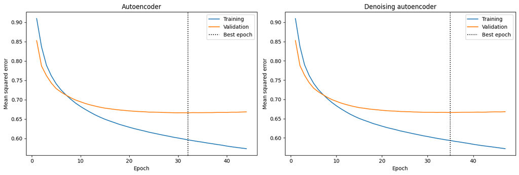

```python
fig, axes = plt.subplots(1, 2, figsize=(14, 4.8))
for ax, fit, title in [
    (axes[0], ae_fit, "Autoencoder"),
    (axes[1], dae_fit, "Denoising autoencoder"),
]:
    history = fit["history"]
    ax.plot(history["epoch"], history["training_loss"], label="Training")
    ax.plot(history["epoch"], history["validation_loss"], label="Validation")
    ax.axvline(history.loc[history["validation_loss"].idxmin(), "epoch"],
               color="black", linestyle=":", label="Best epoch")
    ax.set_title(title)
    ax.set_xlabel("Epoch")
    ax.set_ylabel("Mean squared error")
    ax.legend()
plt.tight_layout()
plt.show()
```

Both networks train cleanly. Validation loss falls sharply over the first ten epochs, flattens, and the training curve keeps decreasing slightly below it afterwards. This is a small, expected training-validation gap that appears once the model starts fitting patterns specific to the training split instead of the shared underlying structure, and it is what early stopping is designed to catch before it grows further. The AE reaches its best validation loss at epoch 32, the DAE at epoch 35, both stopping 12 epochs later (44 and 47 total) once `patience` is exhausted with no further improvement. The two curves are close to indistinguishable in shape and in final level (~0.665), because the DAE's own validation loss is computed against the same modestly noised input used during training (`noise_std=0.15`). This plot compares two training trajectories on their own respective objectives, not yet the two models' ability to reconstruct *clean* data, which is examined directly in the next section.

## 13.4 Reconstruction Quality on Held-Out Cells

A single mean MSE, as printed above, can hide very different behaviour underneath it: the same average could come from every cell being reconstructed moderately well, or from most cells being reconstructed well and a handful being reconstructed very poorly. The per-cell reconstruction error is examined directly for this reason, for all three representations on the same held-out validation cells used throughout this section.

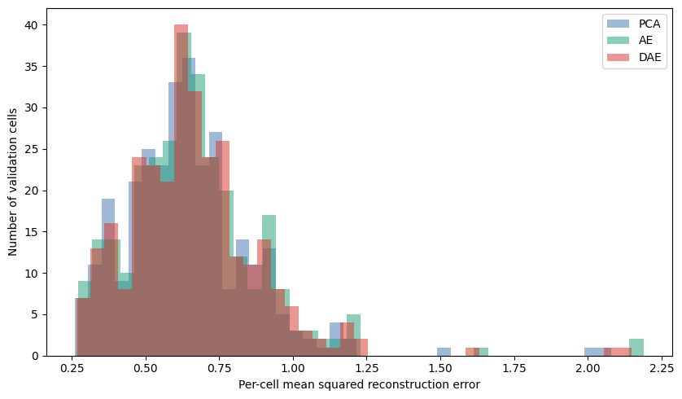

|  | mean | median | std | max |
| --- | --- | --- | --- | --- |
| PCA | 0.6450 | 0.6270 | 0.2282 | 2.0803 |
| AE | 0.6661 | 0.6439 | 0.2382 | 2.1891 |
| DAE | 0.6652 | 0.6427 | 0.2358 | 2.1496 |

```python
val_idx = ae_fit["val_idx"]
X_val = X_hvg_scaled[val_idx]

ae_val_reconstruction = reconstruct_matrix(ae_fit["model"], X_val)
dae_val_reconstruction = reconstruct_matrix(dae_fit["model"], X_val)

per_cell_error = pd.DataFrame({
    "PCA": np.mean((pca_val_reconstruction - X_val) ** 2, axis=1),
    "AE": np.mean((ae_val_reconstruction - X_val) ** 2, axis=1),
    "DAE": np.mean((dae_val_reconstruction - X_val) ** 2, axis=1),
})

fig, ax = plt.subplots(figsize=(8.5, 5))
for name, color in zip(per_cell_error.columns, ["#4575b4", "#1b9e77", "#d73027"]):
    ax.hist(per_cell_error[name], bins=40, alpha=0.5, label=name, color=color)
ax.set_xlabel("Per-cell mean squared reconstruction error")
ax.set_ylabel("Number of validation cells")
ax.legend()
plt.tight_layout()
plt.show()

display(per_cell_error.agg(["mean", "median", "std", "max"]).T.style.format("{:.4f}"))
```

All three distributions are unimodal, right-skewed, and overlap almost entirely, with the same handful of outlier cells stretching out past 1.5 for every representation, and no method produces a distinct population of catastrophically mis-reconstructed cells that the others avoid. PCA sits consistently, if modestly, ahead of both neural models on every summary statistic: the lowest mean (0.6450) and median (0.6270), the smallest spread (std 0.2282), and the lowest single worst case (2.0803). AE and DAE are close to indistinguishable from each other (mean 0.6661 against 0.6652, essentially a tie given the scale of the differences), and both sit slightly above PCA on every statistic, including a marginally heavier tail (max 2.1891 and 2.1496). This confirms, at the level of individual cells instead of a single averaged number, what the architecture grid search in section 13.2 already suggested: within the capacity range explored here, the nonlinear bottleneck does not reconstruct the scaled expression matrix more faithfully than a linear PCA projection of the same size. That does not mean the nonlinear representations are without value: reconstruction fidelity and usefulness for downstream classification are different questions, examined next.

## 13.5 What Does the Latent Space Actually Encode?

Two complementary checks look inside the 32-dimensional bottleneck rather than only at how well it reconstructs its input. The first asks whether all 32 latent dimensions are used: unlike PCA, whose components have strictly decreasing variance by construction, nothing in the autoencoder's objective prevents some units collapsing to a near-constant value while others carry the signal, a well-documented failure mode of undercomplete autoencoders worth checking directly. The second asks whether the latent space aligns with the canonical marker panel used throughout the notebook. Correlating each latent dimension against the twelve canonical markers is a direct, if partial, test of whether the compression corresponds to anything already understood about the biology or to some other axis of variation entirely.

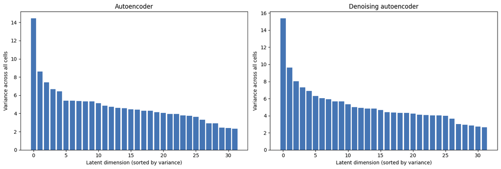

```
AE: lowest / highest dimension variance = 2.3011 / 14.4609
DAE: lowest / highest dimension variance = 2.6379 / 15.3982
```

```python
ae_latent = encode_matrix(ae_fit["model"], X_hvg_scaled)
dae_latent = encode_matrix(dae_fit["model"], X_hvg_scaled)

ae_dimension_variance = pd.Series(
    ae_latent.var(axis=0), index=range(LATENT_DIM)
).sort_values(ascending=False)
dae_dimension_variance = pd.Series(
    dae_latent.var(axis=0), index=range(LATENT_DIM)
).sort_values(ascending=False)

fig, axes = plt.subplots(1, 2, figsize=(14, 4.8))
for ax, variances, title in [
    (axes[0], ae_dimension_variance, "Autoencoder"),
    (axes[1], dae_dimension_variance, "Denoising autoencoder"),
]:
    ax.bar(range(LATENT_DIM), variances.to_numpy(), color="#4575b4")
    ax.set_title(title)
    ax.set_xlabel("Latent dimension (sorted by variance)")
    ax.set_ylabel("Variance across all cells")
plt.tight_layout()
plt.show()

print(f"AE: lowest / highest dimension variance = {ae_dimension_variance.min():.4f} / {ae_dimension_variance.max():.4f}")
print(f"DAE: lowest / highest dimension variance = {dae_dimension_variance.min():.4f} / {dae_dimension_variance.max():.4f}")
```

Neither network shows dimension collapse: the lowest-variance dimension still carries 2.3011 for the AE and 2.6379 for the DAE, far from the near-zero variance expected from an inactive latent unit. The displayed bars decrease from left to right because the variances were explicitly sorted for readability. Their shape therefore cannot show that the autoencoder spontaneously learned PCA-like ordered components: unlike principal components, latent units are interchangeable and have no intrinsic variance ranking. This diagnostic supports only the narrower conclusion that all 32 latent dimensions remain active and that the encoded variance is distributed unevenly across them.

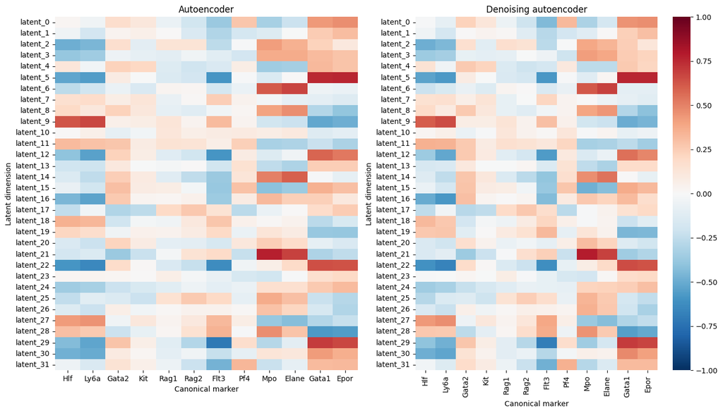

```
Strongest |correlation| (AE): 0.774
Strongest |correlation| (DAE): 0.784
```

```python
biology_symbols = adata_biology.var["Symbol"].astype(str).to_numpy()
marker_columns = {}
for marker in all_markers:
    marker_idx = np.flatnonzero(biology_symbols == marker)
    if len(marker_idx):
        marker_columns[marker] = np.asarray(adata_biology.X[:, marker_idx[0]]).ravel()
marker_expression = pd.DataFrame(marker_columns)

ae_latent_columns = [f"latent_{i}" for i in range(LATENT_DIM)]
ae_latent_df = pd.DataFrame(ae_latent, columns=ae_latent_columns)
dae_latent_df = pd.DataFrame(dae_latent, columns=ae_latent_columns)

ae_marker_corr = pd.concat(
    [ae_latent_df, marker_expression], axis=1
).corr().loc[ae_latent_columns, marker_expression.columns]
dae_marker_corr = pd.concat(
    [dae_latent_df, marker_expression], axis=1
).corr().loc[ae_latent_columns, marker_expression.columns]

fig, axes = plt.subplots(1, 2, figsize=(14, 8))
for ax, corr, title in [(axes[0], ae_marker_corr, "Autoencoder"), (axes[1], dae_marker_corr, "Denoising autoencoder")]:
    sns.heatmap(corr, cmap="RdBu_r", vmin=-1, vmax=1, ax=ax, cbar=ax is axes[-1])
    ax.set_title(title)
    ax.set_xlabel("Canonical marker")
    ax.set_ylabel("Latent dimension")
plt.tight_layout()
plt.show()

print("Strongest |correlation| (AE):", ae_marker_corr.abs().to_numpy().max().round(3))
print("Strongest |correlation| (DAE):", dae_marker_corr.abs().to_numpy().max().round(3))
```

Most of the 32 latent dimensions correlate weakly with every marker, pale throughout both heatmaps, but a handful stand out clearly, and the same ones stand out in both networks. `latent_5` correlates strongly with `Gata1`/`Epor` (erythroid) and, in the opposite direction, with `Hlf`/`Ly6a` and `Flt3`; `latent_9` correlates positively with `Hlf`/`Ly6a` (stem/early progenitor) and negatively with `Gata1`/`Epor`; `latent_6` and `latent_21` both correlate positively with `Mpo`/`Elane` (granulocyte-monocyte), `latent_21` reaching the strongest single value in the grid. Three of the five canonical programmes therefore each have at least one latent dimension tracking them, with the strongest correlation reaching 0.774 for the AE and 0.784 for the DAE.

The other two programmes are missing. `Rag1`, `Rag2` (lymphoid priming) and `Pf4` (megakaryocytic bias) stay pale across essentially every latent dimension in both networks. This is not a new limitation: section 5.7 already flagged `Pf4` as the weakest and most dropout-affected marker in the panel, and `Rag1` as similarly dropout-affected, with a detection pattern unlike its programme-mate `Rag2`. A marker whose own measured signal is unreliable cannot be expected to leave a clean trace in a compressed representation built from that same measurement, so the limit here is data quality and not a separate failure of the network. AE and DAE agree closely on which dimensions carry which programme, further evidence that denoising changed how robustly the network reconstructs its input more than what structure it learned.